# Trabajo final

Indicaciones:

1. Utilizando scipy. stats, crea un programa que modele la probabilidad de obtener un número específico de éxitos en una serie de lanzamientos de una moneda sin trucos (probabilidad de éxito p = 0. 5). Genera la probabilidad de obtener exactamente 7 caras en 10 lanzamientos

```python
from scipy.stats import binom

# Se trata de una distribución binomial
probabilidad = binom.pmf(7, 10, 0.5)

print(probabilidad)
```

```
0.11718749999999999
```

Calcula la probabilidad acumulada de obtener 7 o menos caras en 10 lanzamientos

```python
from scipy.stats import binom

# Calcula la probabilidad acumulada de obtener 7 o menos caras en 10 lanzamientos
probabilidad = binom.cdf(7, 10, 0.5)

print(probabilidad)
```

```
0.9453125
```

Grafica la distribución binomial completa para los 10 lanzamientos, mostrando la probabilidad de obtener desde 0 hasta 10 caras.

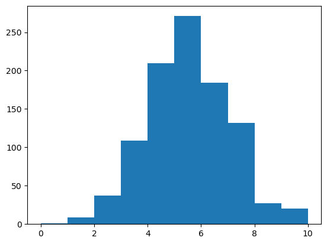

```python
import matplotlib.pyplot as plt
from scipy.stats import binom

flips=binom.rvs(10,0.5,size=1000)
plt.hist(flips)
plt.show()
```

```
probabilidad: 0.20132659199999978
probabilidad: 0.32220047359999987
```

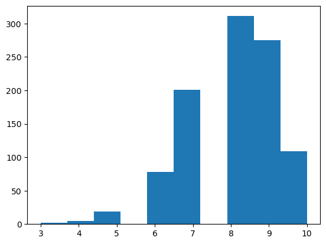

```python
	#Se trata de una distribución binomial

	from scipy.stats import binom
	probabilidad = binom.pmf(7,10, 0.8)

	print("probabilidad:",probabilidad)

# EJERCICIO N°2
	probabilidad = binom.cdf(7,10, 0.8)

	print("probabilidad:",probabilidad)

# EJERCICIO N°3
	import matplotlib.pyplot as plt
	from scipy.stats import binom

	flips=binom.rvs(10,0.8,size=1000)
	plt.hist(flips)
	plt.show()
```

Utilizando scipy. stats, realiza un análisis de una distribución normal con una media de 0 y desviación estándar de 1. Genera un conjunto de datos aleatorios con 1000 muestras a partir de esta distribución.

```python
from scipy.stats import norm
import numpy as np

datos = norm.rvs(0, 1, 1000)

print(datos)
```

[output not shown]

[output cut: 195 more lines]

[output not shown]

Calcula y muestra la media, la desviación estándar y la mediana de los datos generados.

```python
from scipy.stats import norm
import numpy as np

datos = norm.rvs(0, 1, 1000)

media= np.mean(datos)
print("Media:", media)

#DESVIACIÓN ESTÁNDAR:
desviacion_estandar=np.std(datos)
print("Desviacion estándar:",desviacion_estandar)

#MEDIANA:
mediana=np.median(datos)
print("Mediana:",mediana)
```

```
Media: -0.028608724091140045
Desviacion estándar: 1.008904519043455
Mediana: 0.0047671872665042345
```

Grafica el histograma de los datos y superpón la curva de la distribución normal teórica.

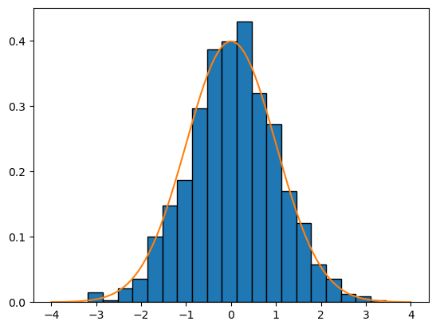

```python
import numpy as np
import matplotlib.pyplot as plt
from scipy.stats import norm

np.random.seed(40)

hist = np.random.normal(0, 1, 1000)
plt.hist(hist, bins=20, density=True, edgecolor='black')
plt.plot(np.linspace(-4, 4, 100), norm.pdf(np.linspace(-4, 4, 100), 0, 1))
plt.show()
```

Calcula la probabilidad de que un valor caiga dentro del rango de -1 a 1 (una desviación estándar de la media).

```python
from scipy.stats import norm

probab = norm.cdf(1) - norm.cdf(-1)
print("probabilidad de caer entre -1 y 1:", probab)
```

```
probabilidad de caer entre -1 y 1: 0.6826894921370859
```

# Parte 2

Contaran con toda la información sobre el trabajo en la carpeta "Trabajo Final" del Github de curso. Lean con cuidado las indicaciones. Algunos puntos a tener en cuenta:

Puedes elegir una de estas dos opciones

- Indicadores de Desarrollo GlobaL, a nivel país.
- El IDH, a nivel distrital, provincial o departamental.

Realiza 4 gráficos con la base de datos de tu elección. Ojo que cualquiera de las opciones implica realizar alguna limpieza de los datos.

Aquí van algunas ideas:

Para los indicadores de desarrollo global:

- puedes ver la evolución en el tiempo de un sólo indicador, para un sólo pais, o región.
- Puedes hacer la comparación entre la evolucion de varios países.
- puedes ver la comparación entre países de un sólo indicador. Puedes enfocarte en una o varias regiones.
- puedes ver la relación de dos o más indicadores.

Para el IDH:

- puedes ver la comparación de alguno de los indicadores entre distritos dentro de un departamento.
- puedes ver la relación de dos indicadores que componen el IDH, entre ellos.

Hay más opciones de temas para los indicadores de desarrollo global.

Formato de entrega: Un archivo txt con la URL de la web en Github o notebook del trabajo que también incluya la URL de la web en github. Tener en consideración que dado que el trabajo es de grupos de 5 solo sera necesario que este publicado en un Github. Además dentro de la pagina de Github del trabajo final esta un tutorial de como publicar sus paginas en formato html.

## Ha sido un gusto poder enseñarles . Hasta pronto :D

(╯°□°）╯︵ ┻━┻

```python
import pandas as pd
data_IDH = pd.read_excel("IDH_PNUD_2017-1 (1).xlsx", sheet_name = "Departamental", header = 2)
data_IDH
```

|  | UBIGEO | DEPARTAMENTO | Unnamed: 2 | Unnamed: 3 | Unnamed: 4 | Población | Unnamed: 6 | Índice de Desarrollo Humano | Unnamed: 8 | Esperanza de vida al nacer | Unnamed: 10 | Con Educación secundaria completa (Poblac. 18 años) | Unnamed: 12 | Años de educación (Poblac. 25 y más) | Unnamed: 14 | Ingreso familiar per cápita | Unnamed: 16 | Unnamed: 17 | Unnamed: 18 | Unnamed: 19 |
| --- | --- | --- | --- | --- | --- | --- | --- | --- | --- | --- | --- | --- | --- | --- | --- | --- | --- | --- | --- | --- |
| 0 | NaN | NaN | Provincia | NaN | NaN | NaN | NaN | NaN | NaN | NaN | NaN | NaN | NaN | NaN | NaN | NaN | NaN | NaN | NaN | NaN |
| 1 | NaN | NaN | Distrito | NaN | NaN | habitantes | ranking | IDH | ranking | años | ranking | % | ranking | años | ranking | N.S. mes | ranking | NaN | NaN | NaN |
| 2 | NaN | NaN | NaN | NaN | NaN | NaN | NaN | NaN | NaN | NaN | NaN | NaN | NaN | NaN | NaN | NaN | NaN | NaN | NaN | NaN |
| 3 | NaN | NaN | NaN | NaN | NaN | NaN | NaN | NaN | NaN | NaN | NaN | NaN | NaN | NaN | NaN | NaN | NaN | NaN | NaN | NaN |
| 4 | 000000 | PERÚ | NaN | NaN | NaN | 29381884 | NaN | 0.572345 | NaN | 75.52714 | NaN | 67.108865 | NaN | 8.78599 | NaN | 990.116633 | NaN | NaN | NaN | 1.0 |
| 5 | 010000 | AMAZONAS | NaN | NaN | NaN | 379384 | 19 | 0.417452 | 21 | 73.306564 | 15 | 46.859333 | 24 | 6.050521 | 23 | 629.7113 | 18 | NaN | NaN | 2.0 |
| 6 | 020000 | ANCASH | NaN | NaN | NaN | 1083519 | 10 | 0.488391 | 12 | 75.743889 | 10 | 61.110602 | 16 | 7.633381 | 15 | 712.6623 | 13 | NaN | NaN | 3.0 |
| 7 | 030000 | APURÍMAC | NaN | NaN | NaN | 405759 | 18 | 0.416742 | 22 | 72.634854 | 19 | 65.547677 | 13 | 6.610242 | 21 | 511.8983 | 24 | NaN | NaN | 4.0 |
| 8 | 040000 | AREQUIPA | NaN | NaN | NaN | 1382730 | 4 | 0.634479 | 4 | 78.203421 | 6 | 77.80172 | 1 | 10.097563 | 2 | 1088.0636 | 4 | NaN | NaN | 5.0 |
| 9 | 050000 | AYACUCHO | NaN | NaN | NaN | 616176 | 16 | 0.409602 | 23 | 71.078435 | 22 | 59.357975 | 18 | 6.905559 | 19 | 512.4642 | 23 | NaN | NaN | 6.0 |
| 10 | 060000 | CAJAMARCA | NaN | NaN | NaN | 1341012 | 5 | 0.40106 | 24 | 74.746021 | 11 | 51.376462 | 23 | 5.607542 | 25 | 551.7471 | 21 | NaN | NaN | 7.0 |
| 11 | 070100 | Provincia Constitucional del CALLAO | NaN | NaN | NaN | 994494 | 11 | 0.666302 | 2 | 82.515232 | 1 | 73.497518 | 6 | 10.062423 | 3 | 1198.1964 | 2 | NaN | NaN | 8.0 |
| 12 | 080000 | CUSCO | NaN | NaN | NaN | 1205527 | 7 | 0.470121 | 15 | 70.740178 | 23 | 66.690447 | 11 | 7.798155 | 14 | 667.9998 | 17 | NaN | NaN | 9.0 |
| 13 | 090000 | HUANCAVELICA | NaN | NaN | NaN | 347639 | 20 | 0.335663 | 25 | 64.034012 | 25 | 56.184207 | 19 | 5.735151 | 24 | 398.1561 | 25 | NaN | NaN | 10.0 |
| 14 | 100000 | HUÁNUCO | NaN | NaN | NaN | 721047 | 15 | 0.428468 | 19 | 73.110342 | 17 | 53.614801 | 20 | 6.572781 | 22 | 604.6419 | 19 | NaN | NaN | 11.0 |
| 15 | 110000 | ICA | NaN | NaN | NaN | 850765 | 13 | 0.612103 | 5 | 81.663418 | 2 | 73.527836 | 5 | 9.905355 | 5 | 958.9974 | 7 | NaN | NaN | 12.0 |
| 16 | 120000 | JUNÍN | NaN | NaN | NaN | 1246038 | 6 | 0.495384 | 11 | 73.181276 | 16 | 65.8842 | 12 | 8.381481 | 10 | 710.3179 | 14 | NaN | NaN | 13.0 |
| 17 | 130000 | LA LIBERTAD | NaN | NaN | NaN | 1778080 | 3 | 0.538779 | 10 | 77.214338 | 9 | 60.848472 | 17 | 8.033712 | 13 | 892.1488 | 8 | NaN | NaN | 14.0 |
| 18 | 140000 | LAMBAYEQUE | NaN | NaN | NaN | 1197260 | 8 | 0.53949 | 9 | 77.288576 | 8 | 67.090434 | 9 | 8.445149 | 9 | 827.6347 | 10 | NaN | NaN | 15.0 |
| 19 | 150000 | LIMA | NaN | NaN | NaN | 9485405 | 1 | 0.715651 | 1 | 81.153518 | 3 | 75.707688 | 2 | 10.35686 | 1 | 1464.2608 | 1 | NaN | NaN | 16.0 |
| 20 | 160000 | LORETO | NaN | NaN | NaN | 883510 | 12 | 0.454914 | 18 | 71.419194 | 21 | 45.044803 | 25 | 7.560003 | 17 | 736.7302 | 12 | NaN | NaN | 17.0 |
| 21 | 170000 | MADRE DE DIOS | NaN | NaN | NaN | 141070 | 25 | 0.56188 | 7 | 73.718619 | 12 | 63.758325 | 14 | 8.726031 | 7 | 1000.6915 | 6 | NaN | NaN | 18.0 |
| 22 | 180000 | MOQUEGUA | NaN | NaN | NaN | 174863 | 24 | 0.638726 | 3 | 79.800886 | 4 | 74.491285 | 4 | 9.921653 | 4 | 1112.4407 | 3 | NaN | NaN | 19.0 |
| 23 | 190000 | PASCO | NaN | NaN | NaN | 254065 | 22 | 0.460667 | 17 | 72.040411 | 20 | 68.253589 | 8 | 8.141167 | 11 | 591.7423 | 20 | NaN | NaN | 20.0 |
| 24 | 200000 | PIURA | NaN | NaN | NaN | 1856809 | 2 | 0.479728 | 13 | 73.696331 | 14 | 61.930024 | 15 | 7.577943 | 16 | 702.9804 | 16 | NaN | NaN | 21.0 |
| 25 | 210000 | PUNO | NaN | NaN | NaN | 1172697 | 9 | 0.427841 | 20 | 68.475641 | 24 | 72.150998 | 7 | 7.447559 | 18 | 532.3485 | 22 | NaN | NaN | 22.0 |
| 26 | 220000 | SAN MARTÍN | NaN | NaN | NaN | 813381 | 14 | 0.467982 | 16 | 73.718529 | 13 | 52.462043 | 21 | 6.644659 | 20 | 770.4451 | 11 | NaN | NaN | 23.0 |
| 27 | 230000 | TACNA | NaN | NaN | NaN | 329332 | 21 | 0.606991 | 6 | 77.53434 | 7 | 74.913182 | 3 | 9.810744 | 6 | 1003.4997 | 5 | NaN | NaN | 24.0 |
| 28 | 240000 | TUMBES | NaN | NaN | NaN | 224863 | 23 | 0.559666 | 8 | 79.057924 | 5 | 66.70287 | 10 | 8.666748 | 8 | 879.4833 | 9 | NaN | NaN | 25.0 |
| 29 | 250000 | UCAYALI | NaN | NaN | NaN | 496459 | 17 | 0.470985 | 14 | 72.861223 | 18 | 51.943499 | 22 | 8.052112 | 12 | 710.1024 | 15 | NaN | NaN | 26.0 |
| 30 | NaN | NaN | NaN | NaN | NaN | NaN | NaN | NaN | NaN | NaN | NaN | NaN | NaN | NaN | NaN | NaN | NaN | NaN | NaN | NaN |
| 31 | Fuente: INEI. Censo de Población y Vivienda 20... | NaN | NaN | NaN | NaN | NaN | NaN | NaN | NaN | NaN | NaN | NaN | NaN | NaN | NaN | NaN | NaN | NaN | NaN | NaN |
| 32 | Elaboración: PNUD / Unidad del Informe sobre D... | NaN | NaN | NaN | NaN | NaN | NaN | NaN | NaN | NaN | NaN | NaN | NaN | NaN | NaN | NaN | NaN | NaN | NaN | NaN |

```python
data_IDH = data_IDH.drop(0, axis = 0)
data_IDH
```

|  | UBIGEO | DEPARTAMENTO | Unnamed: 2 | Unnamed: 3 | Unnamed: 4 | Población | Unnamed: 6 | Índice de Desarrollo Humano | Unnamed: 8 | Esperanza de vida al nacer | Unnamed: 10 | Con Educación secundaria completa (Poblac. 18 años) | Unnamed: 12 | Años de educación (Poblac. 25 y más) | Unnamed: 14 | Ingreso familiar per cápita | Unnamed: 16 | Unnamed: 17 | Unnamed: 18 | Unnamed: 19 |
| --- | --- | --- | --- | --- | --- | --- | --- | --- | --- | --- | --- | --- | --- | --- | --- | --- | --- | --- | --- | --- |
| 1 | NaN | NaN | Distrito | NaN | NaN | habitantes | ranking | IDH | ranking | años | ranking | % | ranking | años | ranking | N.S. mes | ranking | NaN | NaN | NaN |
| 2 | NaN | NaN | NaN | NaN | NaN | NaN | NaN | NaN | NaN | NaN | NaN | NaN | NaN | NaN | NaN | NaN | NaN | NaN | NaN | NaN |
| 3 | NaN | NaN | NaN | NaN | NaN | NaN | NaN | NaN | NaN | NaN | NaN | NaN | NaN | NaN | NaN | NaN | NaN | NaN | NaN | NaN |
| 4 | 000000 | PERÚ | NaN | NaN | NaN | 29381884 | NaN | 0.572345 | NaN | 75.52714 | NaN | 67.108865 | NaN | 8.78599 | NaN | 990.116633 | NaN | NaN | NaN | 1.0 |
| 5 | 010000 | AMAZONAS | NaN | NaN | NaN | 379384 | 19 | 0.417452 | 21 | 73.306564 | 15 | 46.859333 | 24 | 6.050521 | 23 | 629.7113 | 18 | NaN | NaN | 2.0 |
| 6 | 020000 | ANCASH | NaN | NaN | NaN | 1083519 | 10 | 0.488391 | 12 | 75.743889 | 10 | 61.110602 | 16 | 7.633381 | 15 | 712.6623 | 13 | NaN | NaN | 3.0 |
| 7 | 030000 | APURÍMAC | NaN | NaN | NaN | 405759 | 18 | 0.416742 | 22 | 72.634854 | 19 | 65.547677 | 13 | 6.610242 | 21 | 511.8983 | 24 | NaN | NaN | 4.0 |
| 8 | 040000 | AREQUIPA | NaN | NaN | NaN | 1382730 | 4 | 0.634479 | 4 | 78.203421 | 6 | 77.80172 | 1 | 10.097563 | 2 | 1088.0636 | 4 | NaN | NaN | 5.0 |
| 9 | 050000 | AYACUCHO | NaN | NaN | NaN | 616176 | 16 | 0.409602 | 23 | 71.078435 | 22 | 59.357975 | 18 | 6.905559 | 19 | 512.4642 | 23 | NaN | NaN | 6.0 |
| 10 | 060000 | CAJAMARCA | NaN | NaN | NaN | 1341012 | 5 | 0.40106 | 24 | 74.746021 | 11 | 51.376462 | 23 | 5.607542 | 25 | 551.7471 | 21 | NaN | NaN | 7.0 |
| 11 | 070100 | Provincia Constitucional del CALLAO | NaN | NaN | NaN | 994494 | 11 | 0.666302 | 2 | 82.515232 | 1 | 73.497518 | 6 | 10.062423 | 3 | 1198.1964 | 2 | NaN | NaN | 8.0 |
| 12 | 080000 | CUSCO | NaN | NaN | NaN | 1205527 | 7 | 0.470121 | 15 | 70.740178 | 23 | 66.690447 | 11 | 7.798155 | 14 | 667.9998 | 17 | NaN | NaN | 9.0 |
| 13 | 090000 | HUANCAVELICA | NaN | NaN | NaN | 347639 | 20 | 0.335663 | 25 | 64.034012 | 25 | 56.184207 | 19 | 5.735151 | 24 | 398.1561 | 25 | NaN | NaN | 10.0 |
| 14 | 100000 | HUÁNUCO | NaN | NaN | NaN | 721047 | 15 | 0.428468 | 19 | 73.110342 | 17 | 53.614801 | 20 | 6.572781 | 22 | 604.6419 | 19 | NaN | NaN | 11.0 |
| 15 | 110000 | ICA | NaN | NaN | NaN | 850765 | 13 | 0.612103 | 5 | 81.663418 | 2 | 73.527836 | 5 | 9.905355 | 5 | 958.9974 | 7 | NaN | NaN | 12.0 |
| 16 | 120000 | JUNÍN | NaN | NaN | NaN | 1246038 | 6 | 0.495384 | 11 | 73.181276 | 16 | 65.8842 | 12 | 8.381481 | 10 | 710.3179 | 14 | NaN | NaN | 13.0 |
| 17 | 130000 | LA LIBERTAD | NaN | NaN | NaN | 1778080 | 3 | 0.538779 | 10 | 77.214338 | 9 | 60.848472 | 17 | 8.033712 | 13 | 892.1488 | 8 | NaN | NaN | 14.0 |
| 18 | 140000 | LAMBAYEQUE | NaN | NaN | NaN | 1197260 | 8 | 0.53949 | 9 | 77.288576 | 8 | 67.090434 | 9 | 8.445149 | 9 | 827.6347 | 10 | NaN | NaN | 15.0 |
| 19 | 150000 | LIMA | NaN | NaN | NaN | 9485405 | 1 | 0.715651 | 1 | 81.153518 | 3 | 75.707688 | 2 | 10.35686 | 1 | 1464.2608 | 1 | NaN | NaN | 16.0 |
| 20 | 160000 | LORETO | NaN | NaN | NaN | 883510 | 12 | 0.454914 | 18 | 71.419194 | 21 | 45.044803 | 25 | 7.560003 | 17 | 736.7302 | 12 | NaN | NaN | 17.0 |
| 21 | 170000 | MADRE DE DIOS | NaN | NaN | NaN | 141070 | 25 | 0.56188 | 7 | 73.718619 | 12 | 63.758325 | 14 | 8.726031 | 7 | 1000.6915 | 6 | NaN | NaN | 18.0 |
| 22 | 180000 | MOQUEGUA | NaN | NaN | NaN | 174863 | 24 | 0.638726 | 3 | 79.800886 | 4 | 74.491285 | 4 | 9.921653 | 4 | 1112.4407 | 3 | NaN | NaN | 19.0 |
| 23 | 190000 | PASCO | NaN | NaN | NaN | 254065 | 22 | 0.460667 | 17 | 72.040411 | 20 | 68.253589 | 8 | 8.141167 | 11 | 591.7423 | 20 | NaN | NaN | 20.0 |
| 24 | 200000 | PIURA | NaN | NaN | NaN | 1856809 | 2 | 0.479728 | 13 | 73.696331 | 14 | 61.930024 | 15 | 7.577943 | 16 | 702.9804 | 16 | NaN | NaN | 21.0 |
| 25 | 210000 | PUNO | NaN | NaN | NaN | 1172697 | 9 | 0.427841 | 20 | 68.475641 | 24 | 72.150998 | 7 | 7.447559 | 18 | 532.3485 | 22 | NaN | NaN | 22.0 |
| 26 | 220000 | SAN MARTÍN | NaN | NaN | NaN | 813381 | 14 | 0.467982 | 16 | 73.718529 | 13 | 52.462043 | 21 | 6.644659 | 20 | 770.4451 | 11 | NaN | NaN | 23.0 |
| 27 | 230000 | TACNA | NaN | NaN | NaN | 329332 | 21 | 0.606991 | 6 | 77.53434 | 7 | 74.913182 | 3 | 9.810744 | 6 | 1003.4997 | 5 | NaN | NaN | 24.0 |
| 28 | 240000 | TUMBES | NaN | NaN | NaN | 224863 | 23 | 0.559666 | 8 | 79.057924 | 5 | 66.70287 | 10 | 8.666748 | 8 | 879.4833 | 9 | NaN | NaN | 25.0 |
| 29 | 250000 | UCAYALI | NaN | NaN | NaN | 496459 | 17 | 0.470985 | 14 | 72.861223 | 18 | 51.943499 | 22 | 8.052112 | 12 | 710.1024 | 15 | NaN | NaN | 26.0 |
| 30 | NaN | NaN | NaN | NaN | NaN | NaN | NaN | NaN | NaN | NaN | NaN | NaN | NaN | NaN | NaN | NaN | NaN | NaN | NaN | NaN |
| 31 | Fuente: INEI. Censo de Población y Vivienda 20... | NaN | NaN | NaN | NaN | NaN | NaN | NaN | NaN | NaN | NaN | NaN | NaN | NaN | NaN | NaN | NaN | NaN | NaN | NaN |
| 32 | Elaboración: PNUD / Unidad del Informe sobre D... | NaN | NaN | NaN | NaN | NaN | NaN | NaN | NaN | NaN | NaN | NaN | NaN | NaN | NaN | NaN | NaN | NaN | NaN | NaN |

```python
data_IDH = data_IDH.drop([30,31,32], axis=0)
data_IDH
```

|  | UBIGEO | DEPARTAMENTO | Unnamed: 2 | Unnamed: 3 | Unnamed: 4 | Población | Unnamed: 6 | Índice de Desarrollo Humano | Unnamed: 8 | Esperanza de vida al nacer | Unnamed: 10 | Con Educación secundaria completa (Poblac. 18 años) | Unnamed: 12 | Años de educación (Poblac. 25 y más) | Unnamed: 14 | Ingreso familiar per cápita | Unnamed: 16 | Unnamed: 17 | Unnamed: 18 | Unnamed: 19 |
| --- | --- | --- | --- | --- | --- | --- | --- | --- | --- | --- | --- | --- | --- | --- | --- | --- | --- | --- | --- | --- |
| 1 | NaN | NaN | Distrito | NaN | NaN | habitantes | ranking | IDH | ranking | años | ranking | % | ranking | años | ranking | N.S. mes | ranking | NaN | NaN | NaN |
| 2 | NaN | NaN | NaN | NaN | NaN | NaN | NaN | NaN | NaN | NaN | NaN | NaN | NaN | NaN | NaN | NaN | NaN | NaN | NaN | NaN |
| 3 | NaN | NaN | NaN | NaN | NaN | NaN | NaN | NaN | NaN | NaN | NaN | NaN | NaN | NaN | NaN | NaN | NaN | NaN | NaN | NaN |
| 4 | 000000 | PERÚ | NaN | NaN | NaN | 29381884 | NaN | 0.572345 | NaN | 75.52714 | NaN | 67.108865 | NaN | 8.78599 | NaN | 990.116633 | NaN | NaN | NaN | 1.0 |
| 5 | 010000 | AMAZONAS | NaN | NaN | NaN | 379384 | 19 | 0.417452 | 21 | 73.306564 | 15 | 46.859333 | 24 | 6.050521 | 23 | 629.7113 | 18 | NaN | NaN | 2.0 |
| 6 | 020000 | ANCASH | NaN | NaN | NaN | 1083519 | 10 | 0.488391 | 12 | 75.743889 | 10 | 61.110602 | 16 | 7.633381 | 15 | 712.6623 | 13 | NaN | NaN | 3.0 |
| 7 | 030000 | APURÍMAC | NaN | NaN | NaN | 405759 | 18 | 0.416742 | 22 | 72.634854 | 19 | 65.547677 | 13 | 6.610242 | 21 | 511.8983 | 24 | NaN | NaN | 4.0 |
| 8 | 040000 | AREQUIPA | NaN | NaN | NaN | 1382730 | 4 | 0.634479 | 4 | 78.203421 | 6 | 77.80172 | 1 | 10.097563 | 2 | 1088.0636 | 4 | NaN | NaN | 5.0 |
| 9 | 050000 | AYACUCHO | NaN | NaN | NaN | 616176 | 16 | 0.409602 | 23 | 71.078435 | 22 | 59.357975 | 18 | 6.905559 | 19 | 512.4642 | 23 | NaN | NaN | 6.0 |
| 10 | 060000 | CAJAMARCA | NaN | NaN | NaN | 1341012 | 5 | 0.40106 | 24 | 74.746021 | 11 | 51.376462 | 23 | 5.607542 | 25 | 551.7471 | 21 | NaN | NaN | 7.0 |
| 11 | 070100 | Provincia Constitucional del CALLAO | NaN | NaN | NaN | 994494 | 11 | 0.666302 | 2 | 82.515232 | 1 | 73.497518 | 6 | 10.062423 | 3 | 1198.1964 | 2 | NaN | NaN | 8.0 |
| 12 | 080000 | CUSCO | NaN | NaN | NaN | 1205527 | 7 | 0.470121 | 15 | 70.740178 | 23 | 66.690447 | 11 | 7.798155 | 14 | 667.9998 | 17 | NaN | NaN | 9.0 |
| 13 | 090000 | HUANCAVELICA | NaN | NaN | NaN | 347639 | 20 | 0.335663 | 25 | 64.034012 | 25 | 56.184207 | 19 | 5.735151 | 24 | 398.1561 | 25 | NaN | NaN | 10.0 |
| 14 | 100000 | HUÁNUCO | NaN | NaN | NaN | 721047 | 15 | 0.428468 | 19 | 73.110342 | 17 | 53.614801 | 20 | 6.572781 | 22 | 604.6419 | 19 | NaN | NaN | 11.0 |
| 15 | 110000 | ICA | NaN | NaN | NaN | 850765 | 13 | 0.612103 | 5 | 81.663418 | 2 | 73.527836 | 5 | 9.905355 | 5 | 958.9974 | 7 | NaN | NaN | 12.0 |
| 16 | 120000 | JUNÍN | NaN | NaN | NaN | 1246038 | 6 | 0.495384 | 11 | 73.181276 | 16 | 65.8842 | 12 | 8.381481 | 10 | 710.3179 | 14 | NaN | NaN | 13.0 |
| 17 | 130000 | LA LIBERTAD | NaN | NaN | NaN | 1778080 | 3 | 0.538779 | 10 | 77.214338 | 9 | 60.848472 | 17 | 8.033712 | 13 | 892.1488 | 8 | NaN | NaN | 14.0 |
| 18 | 140000 | LAMBAYEQUE | NaN | NaN | NaN | 1197260 | 8 | 0.53949 | 9 | 77.288576 | 8 | 67.090434 | 9 | 8.445149 | 9 | 827.6347 | 10 | NaN | NaN | 15.0 |
| 19 | 150000 | LIMA | NaN | NaN | NaN | 9485405 | 1 | 0.715651 | 1 | 81.153518 | 3 | 75.707688 | 2 | 10.35686 | 1 | 1464.2608 | 1 | NaN | NaN | 16.0 |
| 20 | 160000 | LORETO | NaN | NaN | NaN | 883510 | 12 | 0.454914 | 18 | 71.419194 | 21 | 45.044803 | 25 | 7.560003 | 17 | 736.7302 | 12 | NaN | NaN | 17.0 |
| 21 | 170000 | MADRE DE DIOS | NaN | NaN | NaN | 141070 | 25 | 0.56188 | 7 | 73.718619 | 12 | 63.758325 | 14 | 8.726031 | 7 | 1000.6915 | 6 | NaN | NaN | 18.0 |
| 22 | 180000 | MOQUEGUA | NaN | NaN | NaN | 174863 | 24 | 0.638726 | 3 | 79.800886 | 4 | 74.491285 | 4 | 9.921653 | 4 | 1112.4407 | 3 | NaN | NaN | 19.0 |
| 23 | 190000 | PASCO | NaN | NaN | NaN | 254065 | 22 | 0.460667 | 17 | 72.040411 | 20 | 68.253589 | 8 | 8.141167 | 11 | 591.7423 | 20 | NaN | NaN | 20.0 |
| 24 | 200000 | PIURA | NaN | NaN | NaN | 1856809 | 2 | 0.479728 | 13 | 73.696331 | 14 | 61.930024 | 15 | 7.577943 | 16 | 702.9804 | 16 | NaN | NaN | 21.0 |
| 25 | 210000 | PUNO | NaN | NaN | NaN | 1172697 | 9 | 0.427841 | 20 | 68.475641 | 24 | 72.150998 | 7 | 7.447559 | 18 | 532.3485 | 22 | NaN | NaN | 22.0 |
| 26 | 220000 | SAN MARTÍN | NaN | NaN | NaN | 813381 | 14 | 0.467982 | 16 | 73.718529 | 13 | 52.462043 | 21 | 6.644659 | 20 | 770.4451 | 11 | NaN | NaN | 23.0 |
| 27 | 230000 | TACNA | NaN | NaN | NaN | 329332 | 21 | 0.606991 | 6 | 77.53434 | 7 | 74.913182 | 3 | 9.810744 | 6 | 1003.4997 | 5 | NaN | NaN | 24.0 |
| 28 | 240000 | TUMBES | NaN | NaN | NaN | 224863 | 23 | 0.559666 | 8 | 79.057924 | 5 | 66.70287 | 10 | 8.666748 | 8 | 879.4833 | 9 | NaN | NaN | 25.0 |
| 29 | 250000 | UCAYALI | NaN | NaN | NaN | 496459 | 17 | 0.470985 | 14 | 72.861223 | 18 | 51.943499 | 22 | 8.052112 | 12 | 710.1024 | 15 | NaN | NaN | 26.0 |

```python
data_IDH = data_IDH.drop("Unnamed: 3", axis = 1)
data_IDH
```

|  | UBIGEO | DEPARTAMENTO | Unnamed: 2 | Unnamed: 4 | Población | Unnamed: 6 | Índice de Desarrollo Humano | Unnamed: 8 | Esperanza de vida al nacer | Unnamed: 10 | Con Educación secundaria completa (Poblac. 18 años) | Unnamed: 12 | Años de educación (Poblac. 25 y más) | Unnamed: 14 | Ingreso familiar per cápita | Unnamed: 16 | Unnamed: 17 | Unnamed: 18 | Unnamed: 19 |
| --- | --- | --- | --- | --- | --- | --- | --- | --- | --- | --- | --- | --- | --- | --- | --- | --- | --- | --- | --- |
| 1 | NaN | NaN | Distrito | NaN | habitantes | ranking | IDH | ranking | años | ranking | % | ranking | años | ranking | N.S. mes | ranking | NaN | NaN | NaN |
| 2 | NaN | NaN | NaN | NaN | NaN | NaN | NaN | NaN | NaN | NaN | NaN | NaN | NaN | NaN | NaN | NaN | NaN | NaN | NaN |
| 3 | NaN | NaN | NaN | NaN | NaN | NaN | NaN | NaN | NaN | NaN | NaN | NaN | NaN | NaN | NaN | NaN | NaN | NaN | NaN |
| 4 | 000000 | PERÚ | NaN | NaN | 29381884 | NaN | 0.572345 | NaN | 75.52714 | NaN | 67.108865 | NaN | 8.78599 | NaN | 990.116633 | NaN | NaN | NaN | 1.0 |
| 5 | 010000 | AMAZONAS | NaN | NaN | 379384 | 19 | 0.417452 | 21 | 73.306564 | 15 | 46.859333 | 24 | 6.050521 | 23 | 629.7113 | 18 | NaN | NaN | 2.0 |
| 6 | 020000 | ANCASH | NaN | NaN | 1083519 | 10 | 0.488391 | 12 | 75.743889 | 10 | 61.110602 | 16 | 7.633381 | 15 | 712.6623 | 13 | NaN | NaN | 3.0 |
| 7 | 030000 | APURÍMAC | NaN | NaN | 405759 | 18 | 0.416742 | 22 | 72.634854 | 19 | 65.547677 | 13 | 6.610242 | 21 | 511.8983 | 24 | NaN | NaN | 4.0 |
| 8 | 040000 | AREQUIPA | NaN | NaN | 1382730 | 4 | 0.634479 | 4 | 78.203421 | 6 | 77.80172 | 1 | 10.097563 | 2 | 1088.0636 | 4 | NaN | NaN | 5.0 |
| 9 | 050000 | AYACUCHO | NaN | NaN | 616176 | 16 | 0.409602 | 23 | 71.078435 | 22 | 59.357975 | 18 | 6.905559 | 19 | 512.4642 | 23 | NaN | NaN | 6.0 |
| 10 | 060000 | CAJAMARCA | NaN | NaN | 1341012 | 5 | 0.40106 | 24 | 74.746021 | 11 | 51.376462 | 23 | 5.607542 | 25 | 551.7471 | 21 | NaN | NaN | 7.0 |
| 11 | 070100 | Provincia Constitucional del CALLAO | NaN | NaN | 994494 | 11 | 0.666302 | 2 | 82.515232 | 1 | 73.497518 | 6 | 10.062423 | 3 | 1198.1964 | 2 | NaN | NaN | 8.0 |
| 12 | 080000 | CUSCO | NaN | NaN | 1205527 | 7 | 0.470121 | 15 | 70.740178 | 23 | 66.690447 | 11 | 7.798155 | 14 | 667.9998 | 17 | NaN | NaN | 9.0 |
| 13 | 090000 | HUANCAVELICA | NaN | NaN | 347639 | 20 | 0.335663 | 25 | 64.034012 | 25 | 56.184207 | 19 | 5.735151 | 24 | 398.1561 | 25 | NaN | NaN | 10.0 |
| 14 | 100000 | HUÁNUCO | NaN | NaN | 721047 | 15 | 0.428468 | 19 | 73.110342 | 17 | 53.614801 | 20 | 6.572781 | 22 | 604.6419 | 19 | NaN | NaN | 11.0 |
| 15 | 110000 | ICA | NaN | NaN | 850765 | 13 | 0.612103 | 5 | 81.663418 | 2 | 73.527836 | 5 | 9.905355 | 5 | 958.9974 | 7 | NaN | NaN | 12.0 |
| 16 | 120000 | JUNÍN | NaN | NaN | 1246038 | 6 | 0.495384 | 11 | 73.181276 | 16 | 65.8842 | 12 | 8.381481 | 10 | 710.3179 | 14 | NaN | NaN | 13.0 |
| 17 | 130000 | LA LIBERTAD | NaN | NaN | 1778080 | 3 | 0.538779 | 10 | 77.214338 | 9 | 60.848472 | 17 | 8.033712 | 13 | 892.1488 | 8 | NaN | NaN | 14.0 |
| 18 | 140000 | LAMBAYEQUE | NaN | NaN | 1197260 | 8 | 0.53949 | 9 | 77.288576 | 8 | 67.090434 | 9 | 8.445149 | 9 | 827.6347 | 10 | NaN | NaN | 15.0 |
| 19 | 150000 | LIMA | NaN | NaN | 9485405 | 1 | 0.715651 | 1 | 81.153518 | 3 | 75.707688 | 2 | 10.35686 | 1 | 1464.2608 | 1 | NaN | NaN | 16.0 |
| 20 | 160000 | LORETO | NaN | NaN | 883510 | 12 | 0.454914 | 18 | 71.419194 | 21 | 45.044803 | 25 | 7.560003 | 17 | 736.7302 | 12 | NaN | NaN | 17.0 |
| 21 | 170000 | MADRE DE DIOS | NaN | NaN | 141070 | 25 | 0.56188 | 7 | 73.718619 | 12 | 63.758325 | 14 | 8.726031 | 7 | 1000.6915 | 6 | NaN | NaN | 18.0 |
| 22 | 180000 | MOQUEGUA | NaN | NaN | 174863 | 24 | 0.638726 | 3 | 79.800886 | 4 | 74.491285 | 4 | 9.921653 | 4 | 1112.4407 | 3 | NaN | NaN | 19.0 |
| 23 | 190000 | PASCO | NaN | NaN | 254065 | 22 | 0.460667 | 17 | 72.040411 | 20 | 68.253589 | 8 | 8.141167 | 11 | 591.7423 | 20 | NaN | NaN | 20.0 |
| 24 | 200000 | PIURA | NaN | NaN | 1856809 | 2 | 0.479728 | 13 | 73.696331 | 14 | 61.930024 | 15 | 7.577943 | 16 | 702.9804 | 16 | NaN | NaN | 21.0 |
| 25 | 210000 | PUNO | NaN | NaN | 1172697 | 9 | 0.427841 | 20 | 68.475641 | 24 | 72.150998 | 7 | 7.447559 | 18 | 532.3485 | 22 | NaN | NaN | 22.0 |
| 26 | 220000 | SAN MARTÍN | NaN | NaN | 813381 | 14 | 0.467982 | 16 | 73.718529 | 13 | 52.462043 | 21 | 6.644659 | 20 | 770.4451 | 11 | NaN | NaN | 23.0 |
| 27 | 230000 | TACNA | NaN | NaN | 329332 | 21 | 0.606991 | 6 | 77.53434 | 7 | 74.913182 | 3 | 9.810744 | 6 | 1003.4997 | 5 | NaN | NaN | 24.0 |
| 28 | 240000 | TUMBES | NaN | NaN | 224863 | 23 | 0.559666 | 8 | 79.057924 | 5 | 66.70287 | 10 | 8.666748 | 8 | 879.4833 | 9 | NaN | NaN | 25.0 |
| 29 | 250000 | UCAYALI | NaN | NaN | 496459 | 17 | 0.470985 | 14 | 72.861223 | 18 | 51.943499 | 22 | 8.052112 | 12 | 710.1024 | 15 | NaN | NaN | 26.0 |

```python
data_IDH = data_IDH.drop("Unnamed: 4", axis = 1)
data_IDH
```

|  | UBIGEO | DEPARTAMENTO | Unnamed: 2 | Población | Unnamed: 6 | Índice de Desarrollo Humano | Unnamed: 8 | Esperanza de vida al nacer | Unnamed: 10 | Con Educación secundaria completa (Poblac. 18 años) | Unnamed: 12 | Años de educación (Poblac. 25 y más) | Unnamed: 14 | Ingreso familiar per cápita | Unnamed: 16 | Unnamed: 17 | Unnamed: 18 | Unnamed: 19 |
| --- | --- | --- | --- | --- | --- | --- | --- | --- | --- | --- | --- | --- | --- | --- | --- | --- | --- | --- |
| 1 | NaN | NaN | Distrito | habitantes | ranking | IDH | ranking | años | ranking | % | ranking | años | ranking | N.S. mes | ranking | NaN | NaN | NaN |
| 2 | NaN | NaN | NaN | NaN | NaN | NaN | NaN | NaN | NaN | NaN | NaN | NaN | NaN | NaN | NaN | NaN | NaN | NaN |
| 3 | NaN | NaN | NaN | NaN | NaN | NaN | NaN | NaN | NaN | NaN | NaN | NaN | NaN | NaN | NaN | NaN | NaN | NaN |
| 4 | 000000 | PERÚ | NaN | 29381884 | NaN | 0.572345 | NaN | 75.52714 | NaN | 67.108865 | NaN | 8.78599 | NaN | 990.116633 | NaN | NaN | NaN | 1.0 |
| 5 | 010000 | AMAZONAS | NaN | 379384 | 19 | 0.417452 | 21 | 73.306564 | 15 | 46.859333 | 24 | 6.050521 | 23 | 629.7113 | 18 | NaN | NaN | 2.0 |
| 6 | 020000 | ANCASH | NaN | 1083519 | 10 | 0.488391 | 12 | 75.743889 | 10 | 61.110602 | 16 | 7.633381 | 15 | 712.6623 | 13 | NaN | NaN | 3.0 |
| 7 | 030000 | APURÍMAC | NaN | 405759 | 18 | 0.416742 | 22 | 72.634854 | 19 | 65.547677 | 13 | 6.610242 | 21 | 511.8983 | 24 | NaN | NaN | 4.0 |
| 8 | 040000 | AREQUIPA | NaN | 1382730 | 4 | 0.634479 | 4 | 78.203421 | 6 | 77.80172 | 1 | 10.097563 | 2 | 1088.0636 | 4 | NaN | NaN | 5.0 |
| 9 | 050000 | AYACUCHO | NaN | 616176 | 16 | 0.409602 | 23 | 71.078435 | 22 | 59.357975 | 18 | 6.905559 | 19 | 512.4642 | 23 | NaN | NaN | 6.0 |
| 10 | 060000 | CAJAMARCA | NaN | 1341012 | 5 | 0.40106 | 24 | 74.746021 | 11 | 51.376462 | 23 | 5.607542 | 25 | 551.7471 | 21 | NaN | NaN | 7.0 |
| 11 | 070100 | Provincia Constitucional del CALLAO | NaN | 994494 | 11 | 0.666302 | 2 | 82.515232 | 1 | 73.497518 | 6 | 10.062423 | 3 | 1198.1964 | 2 | NaN | NaN | 8.0 |
| 12 | 080000 | CUSCO | NaN | 1205527 | 7 | 0.470121 | 15 | 70.740178 | 23 | 66.690447 | 11 | 7.798155 | 14 | 667.9998 | 17 | NaN | NaN | 9.0 |
| 13 | 090000 | HUANCAVELICA | NaN | 347639 | 20 | 0.335663 | 25 | 64.034012 | 25 | 56.184207 | 19 | 5.735151 | 24 | 398.1561 | 25 | NaN | NaN | 10.0 |
| 14 | 100000 | HUÁNUCO | NaN | 721047 | 15 | 0.428468 | 19 | 73.110342 | 17 | 53.614801 | 20 | 6.572781 | 22 | 604.6419 | 19 | NaN | NaN | 11.0 |
| 15 | 110000 | ICA | NaN | 850765 | 13 | 0.612103 | 5 | 81.663418 | 2 | 73.527836 | 5 | 9.905355 | 5 | 958.9974 | 7 | NaN | NaN | 12.0 |
| 16 | 120000 | JUNÍN | NaN | 1246038 | 6 | 0.495384 | 11 | 73.181276 | 16 | 65.8842 | 12 | 8.381481 | 10 | 710.3179 | 14 | NaN | NaN | 13.0 |
| 17 | 130000 | LA LIBERTAD | NaN | 1778080 | 3 | 0.538779 | 10 | 77.214338 | 9 | 60.848472 | 17 | 8.033712 | 13 | 892.1488 | 8 | NaN | NaN | 14.0 |
| 18 | 140000 | LAMBAYEQUE | NaN | 1197260 | 8 | 0.53949 | 9 | 77.288576 | 8 | 67.090434 | 9 | 8.445149 | 9 | 827.6347 | 10 | NaN | NaN | 15.0 |
| 19 | 150000 | LIMA | NaN | 9485405 | 1 | 0.715651 | 1 | 81.153518 | 3 | 75.707688 | 2 | 10.35686 | 1 | 1464.2608 | 1 | NaN | NaN | 16.0 |
| 20 | 160000 | LORETO | NaN | 883510 | 12 | 0.454914 | 18 | 71.419194 | 21 | 45.044803 | 25 | 7.560003 | 17 | 736.7302 | 12 | NaN | NaN | 17.0 |
| 21 | 170000 | MADRE DE DIOS | NaN | 141070 | 25 | 0.56188 | 7 | 73.718619 | 12 | 63.758325 | 14 | 8.726031 | 7 | 1000.6915 | 6 | NaN | NaN | 18.0 |
| 22 | 180000 | MOQUEGUA | NaN | 174863 | 24 | 0.638726 | 3 | 79.800886 | 4 | 74.491285 | 4 | 9.921653 | 4 | 1112.4407 | 3 | NaN | NaN | 19.0 |
| 23 | 190000 | PASCO | NaN | 254065 | 22 | 0.460667 | 17 | 72.040411 | 20 | 68.253589 | 8 | 8.141167 | 11 | 591.7423 | 20 | NaN | NaN | 20.0 |
| 24 | 200000 | PIURA | NaN | 1856809 | 2 | 0.479728 | 13 | 73.696331 | 14 | 61.930024 | 15 | 7.577943 | 16 | 702.9804 | 16 | NaN | NaN | 21.0 |
| 25 | 210000 | PUNO | NaN | 1172697 | 9 | 0.427841 | 20 | 68.475641 | 24 | 72.150998 | 7 | 7.447559 | 18 | 532.3485 | 22 | NaN | NaN | 22.0 |
| 26 | 220000 | SAN MARTÍN | NaN | 813381 | 14 | 0.467982 | 16 | 73.718529 | 13 | 52.462043 | 21 | 6.644659 | 20 | 770.4451 | 11 | NaN | NaN | 23.0 |
| 27 | 230000 | TACNA | NaN | 329332 | 21 | 0.606991 | 6 | 77.53434 | 7 | 74.913182 | 3 | 9.810744 | 6 | 1003.4997 | 5 | NaN | NaN | 24.0 |
| 28 | 240000 | TUMBES | NaN | 224863 | 23 | 0.559666 | 8 | 79.057924 | 5 | 66.70287 | 10 | 8.666748 | 8 | 879.4833 | 9 | NaN | NaN | 25.0 |
| 29 | 250000 | UCAYALI | NaN | 496459 | 17 | 0.470985 | 14 | 72.861223 | 18 | 51.943499 | 22 | 8.052112 | 12 | 710.1024 | 15 | NaN | NaN | 26.0 |

```python
data_IDH = data_IDH.drop("Unnamed: 2", axis = 1)
data_IDH
```

|  | UBIGEO | DEPARTAMENTO | Población | Unnamed: 6 | Índice de Desarrollo Humano | Unnamed: 8 | Esperanza de vida al nacer | Unnamed: 10 | Con Educación secundaria completa (Poblac. 18 años) | Unnamed: 12 | Años de educación (Poblac. 25 y más) | Unnamed: 14 | Ingreso familiar per cápita | Unnamed: 16 | Unnamed: 17 | Unnamed: 18 | Unnamed: 19 |
| --- | --- | --- | --- | --- | --- | --- | --- | --- | --- | --- | --- | --- | --- | --- | --- | --- | --- |
| 1 | NaN | NaN | habitantes | ranking | IDH | ranking | años | ranking | % | ranking | años | ranking | N.S. mes | ranking | NaN | NaN | NaN |
| 2 | NaN | NaN | NaN | NaN | NaN | NaN | NaN | NaN | NaN | NaN | NaN | NaN | NaN | NaN | NaN | NaN | NaN |
| 3 | NaN | NaN | NaN | NaN | NaN | NaN | NaN | NaN | NaN | NaN | NaN | NaN | NaN | NaN | NaN | NaN | NaN |
| 4 | 000000 | PERÚ | 29381884 | NaN | 0.572345 | NaN | 75.52714 | NaN | 67.108865 | NaN | 8.78599 | NaN | 990.116633 | NaN | NaN | NaN | 1.0 |
| 5 | 010000 | AMAZONAS | 379384 | 19 | 0.417452 | 21 | 73.306564 | 15 | 46.859333 | 24 | 6.050521 | 23 | 629.7113 | 18 | NaN | NaN | 2.0 |
| 6 | 020000 | ANCASH | 1083519 | 10 | 0.488391 | 12 | 75.743889 | 10 | 61.110602 | 16 | 7.633381 | 15 | 712.6623 | 13 | NaN | NaN | 3.0 |
| 7 | 030000 | APURÍMAC | 405759 | 18 | 0.416742 | 22 | 72.634854 | 19 | 65.547677 | 13 | 6.610242 | 21 | 511.8983 | 24 | NaN | NaN | 4.0 |
| 8 | 040000 | AREQUIPA | 1382730 | 4 | 0.634479 | 4 | 78.203421 | 6 | 77.80172 | 1 | 10.097563 | 2 | 1088.0636 | 4 | NaN | NaN | 5.0 |
| 9 | 050000 | AYACUCHO | 616176 | 16 | 0.409602 | 23 | 71.078435 | 22 | 59.357975 | 18 | 6.905559 | 19 | 512.4642 | 23 | NaN | NaN | 6.0 |
| 10 | 060000 | CAJAMARCA | 1341012 | 5 | 0.40106 | 24 | 74.746021 | 11 | 51.376462 | 23 | 5.607542 | 25 | 551.7471 | 21 | NaN | NaN | 7.0 |
| 11 | 070100 | Provincia Constitucional del CALLAO | 994494 | 11 | 0.666302 | 2 | 82.515232 | 1 | 73.497518 | 6 | 10.062423 | 3 | 1198.1964 | 2 | NaN | NaN | 8.0 |
| 12 | 080000 | CUSCO | 1205527 | 7 | 0.470121 | 15 | 70.740178 | 23 | 66.690447 | 11 | 7.798155 | 14 | 667.9998 | 17 | NaN | NaN | 9.0 |
| 13 | 090000 | HUANCAVELICA | 347639 | 20 | 0.335663 | 25 | 64.034012 | 25 | 56.184207 | 19 | 5.735151 | 24 | 398.1561 | 25 | NaN | NaN | 10.0 |
| 14 | 100000 | HUÁNUCO | 721047 | 15 | 0.428468 | 19 | 73.110342 | 17 | 53.614801 | 20 | 6.572781 | 22 | 604.6419 | 19 | NaN | NaN | 11.0 |
| 15 | 110000 | ICA | 850765 | 13 | 0.612103 | 5 | 81.663418 | 2 | 73.527836 | 5 | 9.905355 | 5 | 958.9974 | 7 | NaN | NaN | 12.0 |
| 16 | 120000 | JUNÍN | 1246038 | 6 | 0.495384 | 11 | 73.181276 | 16 | 65.8842 | 12 | 8.381481 | 10 | 710.3179 | 14 | NaN | NaN | 13.0 |
| 17 | 130000 | LA LIBERTAD | 1778080 | 3 | 0.538779 | 10 | 77.214338 | 9 | 60.848472 | 17 | 8.033712 | 13 | 892.1488 | 8 | NaN | NaN | 14.0 |
| 18 | 140000 | LAMBAYEQUE | 1197260 | 8 | 0.53949 | 9 | 77.288576 | 8 | 67.090434 | 9 | 8.445149 | 9 | 827.6347 | 10 | NaN | NaN | 15.0 |
| 19 | 150000 | LIMA | 9485405 | 1 | 0.715651 | 1 | 81.153518 | 3 | 75.707688 | 2 | 10.35686 | 1 | 1464.2608 | 1 | NaN | NaN | 16.0 |
| 20 | 160000 | LORETO | 883510 | 12 | 0.454914 | 18 | 71.419194 | 21 | 45.044803 | 25 | 7.560003 | 17 | 736.7302 | 12 | NaN | NaN | 17.0 |
| 21 | 170000 | MADRE DE DIOS | 141070 | 25 | 0.56188 | 7 | 73.718619 | 12 | 63.758325 | 14 | 8.726031 | 7 | 1000.6915 | 6 | NaN | NaN | 18.0 |
| 22 | 180000 | MOQUEGUA | 174863 | 24 | 0.638726 | 3 | 79.800886 | 4 | 74.491285 | 4 | 9.921653 | 4 | 1112.4407 | 3 | NaN | NaN | 19.0 |
| 23 | 190000 | PASCO | 254065 | 22 | 0.460667 | 17 | 72.040411 | 20 | 68.253589 | 8 | 8.141167 | 11 | 591.7423 | 20 | NaN | NaN | 20.0 |
| 24 | 200000 | PIURA | 1856809 | 2 | 0.479728 | 13 | 73.696331 | 14 | 61.930024 | 15 | 7.577943 | 16 | 702.9804 | 16 | NaN | NaN | 21.0 |
| 25 | 210000 | PUNO | 1172697 | 9 | 0.427841 | 20 | 68.475641 | 24 | 72.150998 | 7 | 7.447559 | 18 | 532.3485 | 22 | NaN | NaN | 22.0 |
| 26 | 220000 | SAN MARTÍN | 813381 | 14 | 0.467982 | 16 | 73.718529 | 13 | 52.462043 | 21 | 6.644659 | 20 | 770.4451 | 11 | NaN | NaN | 23.0 |
| 27 | 230000 | TACNA | 329332 | 21 | 0.606991 | 6 | 77.53434 | 7 | 74.913182 | 3 | 9.810744 | 6 | 1003.4997 | 5 | NaN | NaN | 24.0 |
| 28 | 240000 | TUMBES | 224863 | 23 | 0.559666 | 8 | 79.057924 | 5 | 66.70287 | 10 | 8.666748 | 8 | 879.4833 | 9 | NaN | NaN | 25.0 |
| 29 | 250000 | UCAYALI | 496459 | 17 | 0.470985 | 14 | 72.861223 | 18 | 51.943499 | 22 | 8.052112 | 12 | 710.1024 | 15 | NaN | NaN | 26.0 |

```python
data_IDH= data_IDH.set_index("DEPARTAMENTO")
data_IDH
```

| DEPARTAMENTO | UBIGEO | Población | Unnamed: 6 | Índice de Desarrollo Humano | Unnamed: 8 | Esperanza de vida al nacer | Unnamed: 10 | Con Educación secundaria completa (Poblac. 18 años) | Unnamed: 12 | Años de educación (Poblac. 25 y más) | Unnamed: 14 | Ingreso familiar per cápita | Unnamed: 16 | Unnamed: 17 | Unnamed: 18 | Unnamed: 19 |
| --- | --- | --- | --- | --- | --- | --- | --- | --- | --- | --- | --- | --- | --- | --- | --- | --- |
| NaN | NaN | habitantes | ranking | IDH | ranking | años | ranking | % | ranking | años | ranking | N.S. mes | ranking | NaN | NaN | NaN |
| NaN | NaN | NaN | NaN | NaN | NaN | NaN | NaN | NaN | NaN | NaN | NaN | NaN | NaN | NaN | NaN | NaN |
| NaN | NaN | NaN | NaN | NaN | NaN | NaN | NaN | NaN | NaN | NaN | NaN | NaN | NaN | NaN | NaN | NaN |
| PERÚ | 000000 | 29381884 | NaN | 0.572345 | NaN | 75.52714 | NaN | 67.108865 | NaN | 8.78599 | NaN | 990.116633 | NaN | NaN | NaN | 1.0 |
| AMAZONAS | 010000 | 379384 | 19 | 0.417452 | 21 | 73.306564 | 15 | 46.859333 | 24 | 6.050521 | 23 | 629.7113 | 18 | NaN | NaN | 2.0 |
| ANCASH | 020000 | 1083519 | 10 | 0.488391 | 12 | 75.743889 | 10 | 61.110602 | 16 | 7.633381 | 15 | 712.6623 | 13 | NaN | NaN | 3.0 |
| APURÍMAC | 030000 | 405759 | 18 | 0.416742 | 22 | 72.634854 | 19 | 65.547677 | 13 | 6.610242 | 21 | 511.8983 | 24 | NaN | NaN | 4.0 |
| AREQUIPA | 040000 | 1382730 | 4 | 0.634479 | 4 | 78.203421 | 6 | 77.80172 | 1 | 10.097563 | 2 | 1088.0636 | 4 | NaN | NaN | 5.0 |
| AYACUCHO | 050000 | 616176 | 16 | 0.409602 | 23 | 71.078435 | 22 | 59.357975 | 18 | 6.905559 | 19 | 512.4642 | 23 | NaN | NaN | 6.0 |
| CAJAMARCA | 060000 | 1341012 | 5 | 0.40106 | 24 | 74.746021 | 11 | 51.376462 | 23 | 5.607542 | 25 | 551.7471 | 21 | NaN | NaN | 7.0 |
| Provincia Constitucional del CALLAO | 070100 | 994494 | 11 | 0.666302 | 2 | 82.515232 | 1 | 73.497518 | 6 | 10.062423 | 3 | 1198.1964 | 2 | NaN | NaN | 8.0 |
| CUSCO | 080000 | 1205527 | 7 | 0.470121 | 15 | 70.740178 | 23 | 66.690447 | 11 | 7.798155 | 14 | 667.9998 | 17 | NaN | NaN | 9.0 |
| HUANCAVELICA | 090000 | 347639 | 20 | 0.335663 | 25 | 64.034012 | 25 | 56.184207 | 19 | 5.735151 | 24 | 398.1561 | 25 | NaN | NaN | 10.0 |
| HUÁNUCO | 100000 | 721047 | 15 | 0.428468 | 19 | 73.110342 | 17 | 53.614801 | 20 | 6.572781 | 22 | 604.6419 | 19 | NaN | NaN | 11.0 |
| ICA | 110000 | 850765 | 13 | 0.612103 | 5 | 81.663418 | 2 | 73.527836 | 5 | 9.905355 | 5 | 958.9974 | 7 | NaN | NaN | 12.0 |
| JUNÍN | 120000 | 1246038 | 6 | 0.495384 | 11 | 73.181276 | 16 | 65.8842 | 12 | 8.381481 | 10 | 710.3179 | 14 | NaN | NaN | 13.0 |
| LA LIBERTAD | 130000 | 1778080 | 3 | 0.538779 | 10 | 77.214338 | 9 | 60.848472 | 17 | 8.033712 | 13 | 892.1488 | 8 | NaN | NaN | 14.0 |
| LAMBAYEQUE | 140000 | 1197260 | 8 | 0.53949 | 9 | 77.288576 | 8 | 67.090434 | 9 | 8.445149 | 9 | 827.6347 | 10 | NaN | NaN | 15.0 |
| LIMA | 150000 | 9485405 | 1 | 0.715651 | 1 | 81.153518 | 3 | 75.707688 | 2 | 10.35686 | 1 | 1464.2608 | 1 | NaN | NaN | 16.0 |
| LORETO | 160000 | 883510 | 12 | 0.454914 | 18 | 71.419194 | 21 | 45.044803 | 25 | 7.560003 | 17 | 736.7302 | 12 | NaN | NaN | 17.0 |
| MADRE DE DIOS | 170000 | 141070 | 25 | 0.56188 | 7 | 73.718619 | 12 | 63.758325 | 14 | 8.726031 | 7 | 1000.6915 | 6 | NaN | NaN | 18.0 |
| MOQUEGUA | 180000 | 174863 | 24 | 0.638726 | 3 | 79.800886 | 4 | 74.491285 | 4 | 9.921653 | 4 | 1112.4407 | 3 | NaN | NaN | 19.0 |
| PASCO | 190000 | 254065 | 22 | 0.460667 | 17 | 72.040411 | 20 | 68.253589 | 8 | 8.141167 | 11 | 591.7423 | 20 | NaN | NaN | 20.0 |
| PIURA | 200000 | 1856809 | 2 | 0.479728 | 13 | 73.696331 | 14 | 61.930024 | 15 | 7.577943 | 16 | 702.9804 | 16 | NaN | NaN | 21.0 |
| PUNO | 210000 | 1172697 | 9 | 0.427841 | 20 | 68.475641 | 24 | 72.150998 | 7 | 7.447559 | 18 | 532.3485 | 22 | NaN | NaN | 22.0 |
| SAN MARTÍN | 220000 | 813381 | 14 | 0.467982 | 16 | 73.718529 | 13 | 52.462043 | 21 | 6.644659 | 20 | 770.4451 | 11 | NaN | NaN | 23.0 |
| TACNA | 230000 | 329332 | 21 | 0.606991 | 6 | 77.53434 | 7 | 74.913182 | 3 | 9.810744 | 6 | 1003.4997 | 5 | NaN | NaN | 24.0 |
| TUMBES | 240000 | 224863 | 23 | 0.559666 | 8 | 79.057924 | 5 | 66.70287 | 10 | 8.666748 | 8 | 879.4833 | 9 | NaN | NaN | 25.0 |
| UCAYALI | 250000 | 496459 | 17 | 0.470985 | 14 | 72.861223 | 18 | 51.943499 | 22 | 8.052112 | 12 | 710.1024 | 15 | NaN | NaN | 26.0 |

```python
data_IDH = data_IDH.drop("Unnamed: 17", axis = 1)
data_IDH
```

| DEPARTAMENTO | UBIGEO | Población | Unnamed: 6 | Índice de Desarrollo Humano | Unnamed: 8 | Esperanza de vida al nacer | Unnamed: 10 | Con Educación secundaria completa (Poblac. 18 años) | Unnamed: 12 | Años de educación (Poblac. 25 y más) | Unnamed: 14 | Ingreso familiar per cápita | Unnamed: 16 | Unnamed: 18 | Unnamed: 19 |
| --- | --- | --- | --- | --- | --- | --- | --- | --- | --- | --- | --- | --- | --- | --- | --- |
| NaN | NaN | habitantes | ranking | IDH | ranking | años | ranking | % | ranking | años | ranking | N.S. mes | ranking | NaN | NaN |
| NaN | NaN | NaN | NaN | NaN | NaN | NaN | NaN | NaN | NaN | NaN | NaN | NaN | NaN | NaN | NaN |
| NaN | NaN | NaN | NaN | NaN | NaN | NaN | NaN | NaN | NaN | NaN | NaN | NaN | NaN | NaN | NaN |
| PERÚ | 000000 | 29381884 | NaN | 0.572345 | NaN | 75.52714 | NaN | 67.108865 | NaN | 8.78599 | NaN | 990.116633 | NaN | NaN | 1.0 |
| AMAZONAS | 010000 | 379384 | 19 | 0.417452 | 21 | 73.306564 | 15 | 46.859333 | 24 | 6.050521 | 23 | 629.7113 | 18 | NaN | 2.0 |
| ANCASH | 020000 | 1083519 | 10 | 0.488391 | 12 | 75.743889 | 10 | 61.110602 | 16 | 7.633381 | 15 | 712.6623 | 13 | NaN | 3.0 |
| APURÍMAC | 030000 | 405759 | 18 | 0.416742 | 22 | 72.634854 | 19 | 65.547677 | 13 | 6.610242 | 21 | 511.8983 | 24 | NaN | 4.0 |
| AREQUIPA | 040000 | 1382730 | 4 | 0.634479 | 4 | 78.203421 | 6 | 77.80172 | 1 | 10.097563 | 2 | 1088.0636 | 4 | NaN | 5.0 |
| AYACUCHO | 050000 | 616176 | 16 | 0.409602 | 23 | 71.078435 | 22 | 59.357975 | 18 | 6.905559 | 19 | 512.4642 | 23 | NaN | 6.0 |
| CAJAMARCA | 060000 | 1341012 | 5 | 0.40106 | 24 | 74.746021 | 11 | 51.376462 | 23 | 5.607542 | 25 | 551.7471 | 21 | NaN | 7.0 |
| Provincia Constitucional del CALLAO | 070100 | 994494 | 11 | 0.666302 | 2 | 82.515232 | 1 | 73.497518 | 6 | 10.062423 | 3 | 1198.1964 | 2 | NaN | 8.0 |
| CUSCO | 080000 | 1205527 | 7 | 0.470121 | 15 | 70.740178 | 23 | 66.690447 | 11 | 7.798155 | 14 | 667.9998 | 17 | NaN | 9.0 |
| HUANCAVELICA | 090000 | 347639 | 20 | 0.335663 | 25 | 64.034012 | 25 | 56.184207 | 19 | 5.735151 | 24 | 398.1561 | 25 | NaN | 10.0 |
| HUÁNUCO | 100000 | 721047 | 15 | 0.428468 | 19 | 73.110342 | 17 | 53.614801 | 20 | 6.572781 | 22 | 604.6419 | 19 | NaN | 11.0 |
| ICA | 110000 | 850765 | 13 | 0.612103 | 5 | 81.663418 | 2 | 73.527836 | 5 | 9.905355 | 5 | 958.9974 | 7 | NaN | 12.0 |
| JUNÍN | 120000 | 1246038 | 6 | 0.495384 | 11 | 73.181276 | 16 | 65.8842 | 12 | 8.381481 | 10 | 710.3179 | 14 | NaN | 13.0 |
| LA LIBERTAD | 130000 | 1778080 | 3 | 0.538779 | 10 | 77.214338 | 9 | 60.848472 | 17 | 8.033712 | 13 | 892.1488 | 8 | NaN | 14.0 |
| LAMBAYEQUE | 140000 | 1197260 | 8 | 0.53949 | 9 | 77.288576 | 8 | 67.090434 | 9 | 8.445149 | 9 | 827.6347 | 10 | NaN | 15.0 |
| LIMA | 150000 | 9485405 | 1 | 0.715651 | 1 | 81.153518 | 3 | 75.707688 | 2 | 10.35686 | 1 | 1464.2608 | 1 | NaN | 16.0 |
| LORETO | 160000 | 883510 | 12 | 0.454914 | 18 | 71.419194 | 21 | 45.044803 | 25 | 7.560003 | 17 | 736.7302 | 12 | NaN | 17.0 |
| MADRE DE DIOS | 170000 | 141070 | 25 | 0.56188 | 7 | 73.718619 | 12 | 63.758325 | 14 | 8.726031 | 7 | 1000.6915 | 6 | NaN | 18.0 |
| MOQUEGUA | 180000 | 174863 | 24 | 0.638726 | 3 | 79.800886 | 4 | 74.491285 | 4 | 9.921653 | 4 | 1112.4407 | 3 | NaN | 19.0 |
| PASCO | 190000 | 254065 | 22 | 0.460667 | 17 | 72.040411 | 20 | 68.253589 | 8 | 8.141167 | 11 | 591.7423 | 20 | NaN | 20.0 |
| PIURA | 200000 | 1856809 | 2 | 0.479728 | 13 | 73.696331 | 14 | 61.930024 | 15 | 7.577943 | 16 | 702.9804 | 16 | NaN | 21.0 |
| PUNO | 210000 | 1172697 | 9 | 0.427841 | 20 | 68.475641 | 24 | 72.150998 | 7 | 7.447559 | 18 | 532.3485 | 22 | NaN | 22.0 |
| SAN MARTÍN | 220000 | 813381 | 14 | 0.467982 | 16 | 73.718529 | 13 | 52.462043 | 21 | 6.644659 | 20 | 770.4451 | 11 | NaN | 23.0 |
| TACNA | 230000 | 329332 | 21 | 0.606991 | 6 | 77.53434 | 7 | 74.913182 | 3 | 9.810744 | 6 | 1003.4997 | 5 | NaN | 24.0 |
| TUMBES | 240000 | 224863 | 23 | 0.559666 | 8 | 79.057924 | 5 | 66.70287 | 10 | 8.666748 | 8 | 879.4833 | 9 | NaN | 25.0 |
| UCAYALI | 250000 | 496459 | 17 | 0.470985 | 14 | 72.861223 | 18 | 51.943499 | 22 | 8.052112 | 12 | 710.1024 | 15 | NaN | 26.0 |

```python
data_IDH = data_IDH.drop("Unnamed: 18", axis = 1)
data_IDH
```

| DEPARTAMENTO | UBIGEO | Población | Unnamed: 6 | Índice de Desarrollo Humano | Unnamed: 8 | Esperanza de vida al nacer | Unnamed: 10 | Con Educación secundaria completa (Poblac. 18 años) | Unnamed: 12 | Años de educación (Poblac. 25 y más) | Unnamed: 14 | Ingreso familiar per cápita | Unnamed: 16 | Unnamed: 19 |
| --- | --- | --- | --- | --- | --- | --- | --- | --- | --- | --- | --- | --- | --- | --- |
| NaN | NaN | habitantes | ranking | IDH | ranking | años | ranking | % | ranking | años | ranking | N.S. mes | ranking | NaN |
| NaN | NaN | NaN | NaN | NaN | NaN | NaN | NaN | NaN | NaN | NaN | NaN | NaN | NaN | NaN |
| NaN | NaN | NaN | NaN | NaN | NaN | NaN | NaN | NaN | NaN | NaN | NaN | NaN | NaN | NaN |
| PERÚ | 000000 | 29381884 | NaN | 0.572345 | NaN | 75.52714 | NaN | 67.108865 | NaN | 8.78599 | NaN | 990.116633 | NaN | 1.0 |
| AMAZONAS | 010000 | 379384 | 19 | 0.417452 | 21 | 73.306564 | 15 | 46.859333 | 24 | 6.050521 | 23 | 629.7113 | 18 | 2.0 |
| ANCASH | 020000 | 1083519 | 10 | 0.488391 | 12 | 75.743889 | 10 | 61.110602 | 16 | 7.633381 | 15 | 712.6623 | 13 | 3.0 |
| APURÍMAC | 030000 | 405759 | 18 | 0.416742 | 22 | 72.634854 | 19 | 65.547677 | 13 | 6.610242 | 21 | 511.8983 | 24 | 4.0 |
| AREQUIPA | 040000 | 1382730 | 4 | 0.634479 | 4 | 78.203421 | 6 | 77.80172 | 1 | 10.097563 | 2 | 1088.0636 | 4 | 5.0 |
| AYACUCHO | 050000 | 616176 | 16 | 0.409602 | 23 | 71.078435 | 22 | 59.357975 | 18 | 6.905559 | 19 | 512.4642 | 23 | 6.0 |
| CAJAMARCA | 060000 | 1341012 | 5 | 0.40106 | 24 | 74.746021 | 11 | 51.376462 | 23 | 5.607542 | 25 | 551.7471 | 21 | 7.0 |
| Provincia Constitucional del CALLAO | 070100 | 994494 | 11 | 0.666302 | 2 | 82.515232 | 1 | 73.497518 | 6 | 10.062423 | 3 | 1198.1964 | 2 | 8.0 |
| CUSCO | 080000 | 1205527 | 7 | 0.470121 | 15 | 70.740178 | 23 | 66.690447 | 11 | 7.798155 | 14 | 667.9998 | 17 | 9.0 |
| HUANCAVELICA | 090000 | 347639 | 20 | 0.335663 | 25 | 64.034012 | 25 | 56.184207 | 19 | 5.735151 | 24 | 398.1561 | 25 | 10.0 |
| HUÁNUCO | 100000 | 721047 | 15 | 0.428468 | 19 | 73.110342 | 17 | 53.614801 | 20 | 6.572781 | 22 | 604.6419 | 19 | 11.0 |
| ICA | 110000 | 850765 | 13 | 0.612103 | 5 | 81.663418 | 2 | 73.527836 | 5 | 9.905355 | 5 | 958.9974 | 7 | 12.0 |
| JUNÍN | 120000 | 1246038 | 6 | 0.495384 | 11 | 73.181276 | 16 | 65.8842 | 12 | 8.381481 | 10 | 710.3179 | 14 | 13.0 |
| LA LIBERTAD | 130000 | 1778080 | 3 | 0.538779 | 10 | 77.214338 | 9 | 60.848472 | 17 | 8.033712 | 13 | 892.1488 | 8 | 14.0 |
| LAMBAYEQUE | 140000 | 1197260 | 8 | 0.53949 | 9 | 77.288576 | 8 | 67.090434 | 9 | 8.445149 | 9 | 827.6347 | 10 | 15.0 |
| LIMA | 150000 | 9485405 | 1 | 0.715651 | 1 | 81.153518 | 3 | 75.707688 | 2 | 10.35686 | 1 | 1464.2608 | 1 | 16.0 |
| LORETO | 160000 | 883510 | 12 | 0.454914 | 18 | 71.419194 | 21 | 45.044803 | 25 | 7.560003 | 17 | 736.7302 | 12 | 17.0 |
| MADRE DE DIOS | 170000 | 141070 | 25 | 0.56188 | 7 | 73.718619 | 12 | 63.758325 | 14 | 8.726031 | 7 | 1000.6915 | 6 | 18.0 |
| MOQUEGUA | 180000 | 174863 | 24 | 0.638726 | 3 | 79.800886 | 4 | 74.491285 | 4 | 9.921653 | 4 | 1112.4407 | 3 | 19.0 |
| PASCO | 190000 | 254065 | 22 | 0.460667 | 17 | 72.040411 | 20 | 68.253589 | 8 | 8.141167 | 11 | 591.7423 | 20 | 20.0 |
| PIURA | 200000 | 1856809 | 2 | 0.479728 | 13 | 73.696331 | 14 | 61.930024 | 15 | 7.577943 | 16 | 702.9804 | 16 | 21.0 |
| PUNO | 210000 | 1172697 | 9 | 0.427841 | 20 | 68.475641 | 24 | 72.150998 | 7 | 7.447559 | 18 | 532.3485 | 22 | 22.0 |
| SAN MARTÍN | 220000 | 813381 | 14 | 0.467982 | 16 | 73.718529 | 13 | 52.462043 | 21 | 6.644659 | 20 | 770.4451 | 11 | 23.0 |
| TACNA | 230000 | 329332 | 21 | 0.606991 | 6 | 77.53434 | 7 | 74.913182 | 3 | 9.810744 | 6 | 1003.4997 | 5 | 24.0 |
| TUMBES | 240000 | 224863 | 23 | 0.559666 | 8 | 79.057924 | 5 | 66.70287 | 10 | 8.666748 | 8 | 879.4833 | 9 | 25.0 |
| UCAYALI | 250000 | 496459 | 17 | 0.470985 | 14 | 72.861223 | 18 | 51.943499 | 22 | 8.052112 | 12 | 710.1024 | 15 | 26.0 |

```python
data_IDH = data_IDH.drop("Unnamed: 19", axis = 1)
data_IDH
```

| DEPARTAMENTO | UBIGEO | Población | Unnamed: 6 | Índice de Desarrollo Humano | Unnamed: 8 | Esperanza de vida al nacer | Unnamed: 10 | Con Educación secundaria completa (Poblac. 18 años) | Unnamed: 12 | Años de educación (Poblac. 25 y más) | Unnamed: 14 | Ingreso familiar per cápita | Unnamed: 16 |
| --- | --- | --- | --- | --- | --- | --- | --- | --- | --- | --- | --- | --- | --- |
| NaN | NaN | habitantes | ranking | IDH | ranking | años | ranking | % | ranking | años | ranking | N.S. mes | ranking |
| NaN | NaN | NaN | NaN | NaN | NaN | NaN | NaN | NaN | NaN | NaN | NaN | NaN | NaN |
| NaN | NaN | NaN | NaN | NaN | NaN | NaN | NaN | NaN | NaN | NaN | NaN | NaN | NaN |
| PERÚ | 000000 | 29381884 | NaN | 0.572345 | NaN | 75.52714 | NaN | 67.108865 | NaN | 8.78599 | NaN | 990.116633 | NaN |
| AMAZONAS | 010000 | 379384 | 19 | 0.417452 | 21 | 73.306564 | 15 | 46.859333 | 24 | 6.050521 | 23 | 629.7113 | 18 |
| ANCASH | 020000 | 1083519 | 10 | 0.488391 | 12 | 75.743889 | 10 | 61.110602 | 16 | 7.633381 | 15 | 712.6623 | 13 |
| APURÍMAC | 030000 | 405759 | 18 | 0.416742 | 22 | 72.634854 | 19 | 65.547677 | 13 | 6.610242 | 21 | 511.8983 | 24 |
| AREQUIPA | 040000 | 1382730 | 4 | 0.634479 | 4 | 78.203421 | 6 | 77.80172 | 1 | 10.097563 | 2 | 1088.0636 | 4 |
| AYACUCHO | 050000 | 616176 | 16 | 0.409602 | 23 | 71.078435 | 22 | 59.357975 | 18 | 6.905559 | 19 | 512.4642 | 23 |
| CAJAMARCA | 060000 | 1341012 | 5 | 0.40106 | 24 | 74.746021 | 11 | 51.376462 | 23 | 5.607542 | 25 | 551.7471 | 21 |
| Provincia Constitucional del CALLAO | 070100 | 994494 | 11 | 0.666302 | 2 | 82.515232 | 1 | 73.497518 | 6 | 10.062423 | 3 | 1198.1964 | 2 |
| CUSCO | 080000 | 1205527 | 7 | 0.470121 | 15 | 70.740178 | 23 | 66.690447 | 11 | 7.798155 | 14 | 667.9998 | 17 |
| HUANCAVELICA | 090000 | 347639 | 20 | 0.335663 | 25 | 64.034012 | 25 | 56.184207 | 19 | 5.735151 | 24 | 398.1561 | 25 |
| HUÁNUCO | 100000 | 721047 | 15 | 0.428468 | 19 | 73.110342 | 17 | 53.614801 | 20 | 6.572781 | 22 | 604.6419 | 19 |
| ICA | 110000 | 850765 | 13 | 0.612103 | 5 | 81.663418 | 2 | 73.527836 | 5 | 9.905355 | 5 | 958.9974 | 7 |
| JUNÍN | 120000 | 1246038 | 6 | 0.495384 | 11 | 73.181276 | 16 | 65.8842 | 12 | 8.381481 | 10 | 710.3179 | 14 |
| LA LIBERTAD | 130000 | 1778080 | 3 | 0.538779 | 10 | 77.214338 | 9 | 60.848472 | 17 | 8.033712 | 13 | 892.1488 | 8 |
| LAMBAYEQUE | 140000 | 1197260 | 8 | 0.53949 | 9 | 77.288576 | 8 | 67.090434 | 9 | 8.445149 | 9 | 827.6347 | 10 |
| LIMA | 150000 | 9485405 | 1 | 0.715651 | 1 | 81.153518 | 3 | 75.707688 | 2 | 10.35686 | 1 | 1464.2608 | 1 |
| LORETO | 160000 | 883510 | 12 | 0.454914 | 18 | 71.419194 | 21 | 45.044803 | 25 | 7.560003 | 17 | 736.7302 | 12 |
| MADRE DE DIOS | 170000 | 141070 | 25 | 0.56188 | 7 | 73.718619 | 12 | 63.758325 | 14 | 8.726031 | 7 | 1000.6915 | 6 |
| MOQUEGUA | 180000 | 174863 | 24 | 0.638726 | 3 | 79.800886 | 4 | 74.491285 | 4 | 9.921653 | 4 | 1112.4407 | 3 |
| PASCO | 190000 | 254065 | 22 | 0.460667 | 17 | 72.040411 | 20 | 68.253589 | 8 | 8.141167 | 11 | 591.7423 | 20 |
| PIURA | 200000 | 1856809 | 2 | 0.479728 | 13 | 73.696331 | 14 | 61.930024 | 15 | 7.577943 | 16 | 702.9804 | 16 |
| PUNO | 210000 | 1172697 | 9 | 0.427841 | 20 | 68.475641 | 24 | 72.150998 | 7 | 7.447559 | 18 | 532.3485 | 22 |
| SAN MARTÍN | 220000 | 813381 | 14 | 0.467982 | 16 | 73.718529 | 13 | 52.462043 | 21 | 6.644659 | 20 | 770.4451 | 11 |
| TACNA | 230000 | 329332 | 21 | 0.606991 | 6 | 77.53434 | 7 | 74.913182 | 3 | 9.810744 | 6 | 1003.4997 | 5 |
| TUMBES | 240000 | 224863 | 23 | 0.559666 | 8 | 79.057924 | 5 | 66.70287 | 10 | 8.666748 | 8 | 879.4833 | 9 |
| UCAYALI | 250000 | 496459 | 17 | 0.470985 | 14 | 72.861223 | 18 | 51.943499 | 22 | 8.052112 | 12 | 710.1024 | 15 |

```python
data_IDH= data_IDH.rename(columns = {'Unnamed: 6': 'Ranking poblacional'})
data_IDH
```

| DEPARTAMENTO | UBIGEO | Población | Ranking poblacional | Índice de Desarrollo Humano | Unnamed: 8 | Esperanza de vida al nacer | Unnamed: 10 | Con Educación secundaria completa (Poblac. 18 años) | Unnamed: 12 | Años de educación (Poblac. 25 y más) | Unnamed: 14 | Ingreso familiar per cápita | Unnamed: 16 |
| --- | --- | --- | --- | --- | --- | --- | --- | --- | --- | --- | --- | --- | --- |
| NaN | NaN | habitantes | ranking | IDH | ranking | años | ranking | % | ranking | años | ranking | N.S. mes | ranking |
| NaN | NaN | NaN | NaN | NaN | NaN | NaN | NaN | NaN | NaN | NaN | NaN | NaN | NaN |
| NaN | NaN | NaN | NaN | NaN | NaN | NaN | NaN | NaN | NaN | NaN | NaN | NaN | NaN |
| PERÚ | 000000 | 29381884 | NaN | 0.572345 | NaN | 75.52714 | NaN | 67.108865 | NaN | 8.78599 | NaN | 990.116633 | NaN |
| AMAZONAS | 010000 | 379384 | 19 | 0.417452 | 21 | 73.306564 | 15 | 46.859333 | 24 | 6.050521 | 23 | 629.7113 | 18 |
| ANCASH | 020000 | 1083519 | 10 | 0.488391 | 12 | 75.743889 | 10 | 61.110602 | 16 | 7.633381 | 15 | 712.6623 | 13 |
| APURÍMAC | 030000 | 405759 | 18 | 0.416742 | 22 | 72.634854 | 19 | 65.547677 | 13 | 6.610242 | 21 | 511.8983 | 24 |
| AREQUIPA | 040000 | 1382730 | 4 | 0.634479 | 4 | 78.203421 | 6 | 77.80172 | 1 | 10.097563 | 2 | 1088.0636 | 4 |
| AYACUCHO | 050000 | 616176 | 16 | 0.409602 | 23 | 71.078435 | 22 | 59.357975 | 18 | 6.905559 | 19 | 512.4642 | 23 |
| CAJAMARCA | 060000 | 1341012 | 5 | 0.40106 | 24 | 74.746021 | 11 | 51.376462 | 23 | 5.607542 | 25 | 551.7471 | 21 |
| Provincia Constitucional del CALLAO | 070100 | 994494 | 11 | 0.666302 | 2 | 82.515232 | 1 | 73.497518 | 6 | 10.062423 | 3 | 1198.1964 | 2 |
| CUSCO | 080000 | 1205527 | 7 | 0.470121 | 15 | 70.740178 | 23 | 66.690447 | 11 | 7.798155 | 14 | 667.9998 | 17 |
| HUANCAVELICA | 090000 | 347639 | 20 | 0.335663 | 25 | 64.034012 | 25 | 56.184207 | 19 | 5.735151 | 24 | 398.1561 | 25 |
| HUÁNUCO | 100000 | 721047 | 15 | 0.428468 | 19 | 73.110342 | 17 | 53.614801 | 20 | 6.572781 | 22 | 604.6419 | 19 |
| ICA | 110000 | 850765 | 13 | 0.612103 | 5 | 81.663418 | 2 | 73.527836 | 5 | 9.905355 | 5 | 958.9974 | 7 |
| JUNÍN | 120000 | 1246038 | 6 | 0.495384 | 11 | 73.181276 | 16 | 65.8842 | 12 | 8.381481 | 10 | 710.3179 | 14 |
| LA LIBERTAD | 130000 | 1778080 | 3 | 0.538779 | 10 | 77.214338 | 9 | 60.848472 | 17 | 8.033712 | 13 | 892.1488 | 8 |
| LAMBAYEQUE | 140000 | 1197260 | 8 | 0.53949 | 9 | 77.288576 | 8 | 67.090434 | 9 | 8.445149 | 9 | 827.6347 | 10 |
| LIMA | 150000 | 9485405 | 1 | 0.715651 | 1 | 81.153518 | 3 | 75.707688 | 2 | 10.35686 | 1 | 1464.2608 | 1 |
| LORETO | 160000 | 883510 | 12 | 0.454914 | 18 | 71.419194 | 21 | 45.044803 | 25 | 7.560003 | 17 | 736.7302 | 12 |
| MADRE DE DIOS | 170000 | 141070 | 25 | 0.56188 | 7 | 73.718619 | 12 | 63.758325 | 14 | 8.726031 | 7 | 1000.6915 | 6 |
| MOQUEGUA | 180000 | 174863 | 24 | 0.638726 | 3 | 79.800886 | 4 | 74.491285 | 4 | 9.921653 | 4 | 1112.4407 | 3 |
| PASCO | 190000 | 254065 | 22 | 0.460667 | 17 | 72.040411 | 20 | 68.253589 | 8 | 8.141167 | 11 | 591.7423 | 20 |
| PIURA | 200000 | 1856809 | 2 | 0.479728 | 13 | 73.696331 | 14 | 61.930024 | 15 | 7.577943 | 16 | 702.9804 | 16 |
| PUNO | 210000 | 1172697 | 9 | 0.427841 | 20 | 68.475641 | 24 | 72.150998 | 7 | 7.447559 | 18 | 532.3485 | 22 |
| SAN MARTÍN | 220000 | 813381 | 14 | 0.467982 | 16 | 73.718529 | 13 | 52.462043 | 21 | 6.644659 | 20 | 770.4451 | 11 |
| TACNA | 230000 | 329332 | 21 | 0.606991 | 6 | 77.53434 | 7 | 74.913182 | 3 | 9.810744 | 6 | 1003.4997 | 5 |
| TUMBES | 240000 | 224863 | 23 | 0.559666 | 8 | 79.057924 | 5 | 66.70287 | 10 | 8.666748 | 8 | 879.4833 | 9 |
| UCAYALI | 250000 | 496459 | 17 | 0.470985 | 14 | 72.861223 | 18 | 51.943499 | 22 | 8.052112 | 12 | 710.1024 | 15 |

```python
data_IDH= data_IDH.rename(columns = {'Unnamed: 8': 'Ranking IDH'})
data_IDH
```

| DEPARTAMENTO | UBIGEO | Población | Ranking poblacional | Índice de Desarrollo Humano | Ranking IDH | Esperanza de vida al nacer | Unnamed: 10 | Con Educación secundaria completa (Poblac. 18 años) | Unnamed: 12 | Años de educación (Poblac. 25 y más) | Unnamed: 14 | Ingreso familiar per cápita | Unnamed: 16 |
| --- | --- | --- | --- | --- | --- | --- | --- | --- | --- | --- | --- | --- | --- |
| NaN | NaN | habitantes | ranking | IDH | ranking | años | ranking | % | ranking | años | ranking | N.S. mes | ranking |
| NaN | NaN | NaN | NaN | NaN | NaN | NaN | NaN | NaN | NaN | NaN | NaN | NaN | NaN |
| NaN | NaN | NaN | NaN | NaN | NaN | NaN | NaN | NaN | NaN | NaN | NaN | NaN | NaN |
| PERÚ | 000000 | 29381884 | NaN | 0.572345 | NaN | 75.52714 | NaN | 67.108865 | NaN | 8.78599 | NaN | 990.116633 | NaN |
| AMAZONAS | 010000 | 379384 | 19 | 0.417452 | 21 | 73.306564 | 15 | 46.859333 | 24 | 6.050521 | 23 | 629.7113 | 18 |
| ANCASH | 020000 | 1083519 | 10 | 0.488391 | 12 | 75.743889 | 10 | 61.110602 | 16 | 7.633381 | 15 | 712.6623 | 13 |
| APURÍMAC | 030000 | 405759 | 18 | 0.416742 | 22 | 72.634854 | 19 | 65.547677 | 13 | 6.610242 | 21 | 511.8983 | 24 |
| AREQUIPA | 040000 | 1382730 | 4 | 0.634479 | 4 | 78.203421 | 6 | 77.80172 | 1 | 10.097563 | 2 | 1088.0636 | 4 |
| AYACUCHO | 050000 | 616176 | 16 | 0.409602 | 23 | 71.078435 | 22 | 59.357975 | 18 | 6.905559 | 19 | 512.4642 | 23 |
| CAJAMARCA | 060000 | 1341012 | 5 | 0.40106 | 24 | 74.746021 | 11 | 51.376462 | 23 | 5.607542 | 25 | 551.7471 | 21 |
| Provincia Constitucional del CALLAO | 070100 | 994494 | 11 | 0.666302 | 2 | 82.515232 | 1 | 73.497518 | 6 | 10.062423 | 3 | 1198.1964 | 2 |
| CUSCO | 080000 | 1205527 | 7 | 0.470121 | 15 | 70.740178 | 23 | 66.690447 | 11 | 7.798155 | 14 | 667.9998 | 17 |
| HUANCAVELICA | 090000 | 347639 | 20 | 0.335663 | 25 | 64.034012 | 25 | 56.184207 | 19 | 5.735151 | 24 | 398.1561 | 25 |
| HUÁNUCO | 100000 | 721047 | 15 | 0.428468 | 19 | 73.110342 | 17 | 53.614801 | 20 | 6.572781 | 22 | 604.6419 | 19 |
| ICA | 110000 | 850765 | 13 | 0.612103 | 5 | 81.663418 | 2 | 73.527836 | 5 | 9.905355 | 5 | 958.9974 | 7 |
| JUNÍN | 120000 | 1246038 | 6 | 0.495384 | 11 | 73.181276 | 16 | 65.8842 | 12 | 8.381481 | 10 | 710.3179 | 14 |
| LA LIBERTAD | 130000 | 1778080 | 3 | 0.538779 | 10 | 77.214338 | 9 | 60.848472 | 17 | 8.033712 | 13 | 892.1488 | 8 |
| LAMBAYEQUE | 140000 | 1197260 | 8 | 0.53949 | 9 | 77.288576 | 8 | 67.090434 | 9 | 8.445149 | 9 | 827.6347 | 10 |
| LIMA | 150000 | 9485405 | 1 | 0.715651 | 1 | 81.153518 | 3 | 75.707688 | 2 | 10.35686 | 1 | 1464.2608 | 1 |
| LORETO | 160000 | 883510 | 12 | 0.454914 | 18 | 71.419194 | 21 | 45.044803 | 25 | 7.560003 | 17 | 736.7302 | 12 |
| MADRE DE DIOS | 170000 | 141070 | 25 | 0.56188 | 7 | 73.718619 | 12 | 63.758325 | 14 | 8.726031 | 7 | 1000.6915 | 6 |
| MOQUEGUA | 180000 | 174863 | 24 | 0.638726 | 3 | 79.800886 | 4 | 74.491285 | 4 | 9.921653 | 4 | 1112.4407 | 3 |
| PASCO | 190000 | 254065 | 22 | 0.460667 | 17 | 72.040411 | 20 | 68.253589 | 8 | 8.141167 | 11 | 591.7423 | 20 |
| PIURA | 200000 | 1856809 | 2 | 0.479728 | 13 | 73.696331 | 14 | 61.930024 | 15 | 7.577943 | 16 | 702.9804 | 16 |
| PUNO | 210000 | 1172697 | 9 | 0.427841 | 20 | 68.475641 | 24 | 72.150998 | 7 | 7.447559 | 18 | 532.3485 | 22 |
| SAN MARTÍN | 220000 | 813381 | 14 | 0.467982 | 16 | 73.718529 | 13 | 52.462043 | 21 | 6.644659 | 20 | 770.4451 | 11 |
| TACNA | 230000 | 329332 | 21 | 0.606991 | 6 | 77.53434 | 7 | 74.913182 | 3 | 9.810744 | 6 | 1003.4997 | 5 |
| TUMBES | 240000 | 224863 | 23 | 0.559666 | 8 | 79.057924 | 5 | 66.70287 | 10 | 8.666748 | 8 | 879.4833 | 9 |
| UCAYALI | 250000 | 496459 | 17 | 0.470985 | 14 | 72.861223 | 18 | 51.943499 | 22 | 8.052112 | 12 | 710.1024 | 15 |

```python
data_IDH= data_IDH.rename(columns = {'Unnamed: 10': 'Ranking Esperanza de vida'})
data_IDH
```

| DEPARTAMENTO | UBIGEO | Población | Ranking poblacional | Índice de Desarrollo Humano | Ranking IDH | Esperanza de vida al nacer | Ranking Esperanza de vida | Con Educación secundaria completa (Poblac. 18 años) | Unnamed: 12 | Años de educación (Poblac. 25 y más) | Unnamed: 14 | Ingreso familiar per cápita | Unnamed: 16 |
| --- | --- | --- | --- | --- | --- | --- | --- | --- | --- | --- | --- | --- | --- |
| NaN | NaN | habitantes | ranking | IDH | ranking | años | ranking | % | ranking | años | ranking | N.S. mes | ranking |
| NaN | NaN | NaN | NaN | NaN | NaN | NaN | NaN | NaN | NaN | NaN | NaN | NaN | NaN |
| NaN | NaN | NaN | NaN | NaN | NaN | NaN | NaN | NaN | NaN | NaN | NaN | NaN | NaN |
| PERÚ | 000000 | 29381884 | NaN | 0.572345 | NaN | 75.52714 | NaN | 67.108865 | NaN | 8.78599 | NaN | 990.116633 | NaN |
| AMAZONAS | 010000 | 379384 | 19 | 0.417452 | 21 | 73.306564 | 15 | 46.859333 | 24 | 6.050521 | 23 | 629.7113 | 18 |
| ANCASH | 020000 | 1083519 | 10 | 0.488391 | 12 | 75.743889 | 10 | 61.110602 | 16 | 7.633381 | 15 | 712.6623 | 13 |
| APURÍMAC | 030000 | 405759 | 18 | 0.416742 | 22 | 72.634854 | 19 | 65.547677 | 13 | 6.610242 | 21 | 511.8983 | 24 |
| AREQUIPA | 040000 | 1382730 | 4 | 0.634479 | 4 | 78.203421 | 6 | 77.80172 | 1 | 10.097563 | 2 | 1088.0636 | 4 |
| AYACUCHO | 050000 | 616176 | 16 | 0.409602 | 23 | 71.078435 | 22 | 59.357975 | 18 | 6.905559 | 19 | 512.4642 | 23 |
| CAJAMARCA | 060000 | 1341012 | 5 | 0.40106 | 24 | 74.746021 | 11 | 51.376462 | 23 | 5.607542 | 25 | 551.7471 | 21 |
| Provincia Constitucional del CALLAO | 070100 | 994494 | 11 | 0.666302 | 2 | 82.515232 | 1 | 73.497518 | 6 | 10.062423 | 3 | 1198.1964 | 2 |
| CUSCO | 080000 | 1205527 | 7 | 0.470121 | 15 | 70.740178 | 23 | 66.690447 | 11 | 7.798155 | 14 | 667.9998 | 17 |
| HUANCAVELICA | 090000 | 347639 | 20 | 0.335663 | 25 | 64.034012 | 25 | 56.184207 | 19 | 5.735151 | 24 | 398.1561 | 25 |
| HUÁNUCO | 100000 | 721047 | 15 | 0.428468 | 19 | 73.110342 | 17 | 53.614801 | 20 | 6.572781 | 22 | 604.6419 | 19 |
| ICA | 110000 | 850765 | 13 | 0.612103 | 5 | 81.663418 | 2 | 73.527836 | 5 | 9.905355 | 5 | 958.9974 | 7 |
| JUNÍN | 120000 | 1246038 | 6 | 0.495384 | 11 | 73.181276 | 16 | 65.8842 | 12 | 8.381481 | 10 | 710.3179 | 14 |
| LA LIBERTAD | 130000 | 1778080 | 3 | 0.538779 | 10 | 77.214338 | 9 | 60.848472 | 17 | 8.033712 | 13 | 892.1488 | 8 |
| LAMBAYEQUE | 140000 | 1197260 | 8 | 0.53949 | 9 | 77.288576 | 8 | 67.090434 | 9 | 8.445149 | 9 | 827.6347 | 10 |
| LIMA | 150000 | 9485405 | 1 | 0.715651 | 1 | 81.153518 | 3 | 75.707688 | 2 | 10.35686 | 1 | 1464.2608 | 1 |
| LORETO | 160000 | 883510 | 12 | 0.454914 | 18 | 71.419194 | 21 | 45.044803 | 25 | 7.560003 | 17 | 736.7302 | 12 |
| MADRE DE DIOS | 170000 | 141070 | 25 | 0.56188 | 7 | 73.718619 | 12 | 63.758325 | 14 | 8.726031 | 7 | 1000.6915 | 6 |
| MOQUEGUA | 180000 | 174863 | 24 | 0.638726 | 3 | 79.800886 | 4 | 74.491285 | 4 | 9.921653 | 4 | 1112.4407 | 3 |
| PASCO | 190000 | 254065 | 22 | 0.460667 | 17 | 72.040411 | 20 | 68.253589 | 8 | 8.141167 | 11 | 591.7423 | 20 |
| PIURA | 200000 | 1856809 | 2 | 0.479728 | 13 | 73.696331 | 14 | 61.930024 | 15 | 7.577943 | 16 | 702.9804 | 16 |
| PUNO | 210000 | 1172697 | 9 | 0.427841 | 20 | 68.475641 | 24 | 72.150998 | 7 | 7.447559 | 18 | 532.3485 | 22 |
| SAN MARTÍN | 220000 | 813381 | 14 | 0.467982 | 16 | 73.718529 | 13 | 52.462043 | 21 | 6.644659 | 20 | 770.4451 | 11 |
| TACNA | 230000 | 329332 | 21 | 0.606991 | 6 | 77.53434 | 7 | 74.913182 | 3 | 9.810744 | 6 | 1003.4997 | 5 |
| TUMBES | 240000 | 224863 | 23 | 0.559666 | 8 | 79.057924 | 5 | 66.70287 | 10 | 8.666748 | 8 | 879.4833 | 9 |
| UCAYALI | 250000 | 496459 | 17 | 0.470985 | 14 | 72.861223 | 18 | 51.943499 | 22 | 8.052112 | 12 | 710.1024 | 15 |

```python
data_IDH= data_IDH.rename(columns = {'Unnamed: 12': 'Ranking Educacion secundaria'})
data_IDH
```

| DEPARTAMENTO | UBIGEO | Población | Ranking poblacional | Índice de Desarrollo Humano | Ranking IDH | Esperanza de vida al nacer | Ranking Esperanza de vida | Con Educación secundaria completa (Poblac. 18 años) | Ranking Educacion secundaria | Años de educación (Poblac. 25 y más) | Unnamed: 14 | Ingreso familiar per cápita | Unnamed: 16 |
| --- | --- | --- | --- | --- | --- | --- | --- | --- | --- | --- | --- | --- | --- |
| NaN | NaN | habitantes | ranking | IDH | ranking | años | ranking | % | ranking | años | ranking | N.S. mes | ranking |
| NaN | NaN | NaN | NaN | NaN | NaN | NaN | NaN | NaN | NaN | NaN | NaN | NaN | NaN |
| NaN | NaN | NaN | NaN | NaN | NaN | NaN | NaN | NaN | NaN | NaN | NaN | NaN | NaN |
| PERÚ | 000000 | 29381884 | NaN | 0.572345 | NaN | 75.52714 | NaN | 67.108865 | NaN | 8.78599 | NaN | 990.116633 | NaN |
| AMAZONAS | 010000 | 379384 | 19 | 0.417452 | 21 | 73.306564 | 15 | 46.859333 | 24 | 6.050521 | 23 | 629.7113 | 18 |
| ANCASH | 020000 | 1083519 | 10 | 0.488391 | 12 | 75.743889 | 10 | 61.110602 | 16 | 7.633381 | 15 | 712.6623 | 13 |
| APURÍMAC | 030000 | 405759 | 18 | 0.416742 | 22 | 72.634854 | 19 | 65.547677 | 13 | 6.610242 | 21 | 511.8983 | 24 |
| AREQUIPA | 040000 | 1382730 | 4 | 0.634479 | 4 | 78.203421 | 6 | 77.80172 | 1 | 10.097563 | 2 | 1088.0636 | 4 |
| AYACUCHO | 050000 | 616176 | 16 | 0.409602 | 23 | 71.078435 | 22 | 59.357975 | 18 | 6.905559 | 19 | 512.4642 | 23 |
| CAJAMARCA | 060000 | 1341012 | 5 | 0.40106 | 24 | 74.746021 | 11 | 51.376462 | 23 | 5.607542 | 25 | 551.7471 | 21 |
| Provincia Constitucional del CALLAO | 070100 | 994494 | 11 | 0.666302 | 2 | 82.515232 | 1 | 73.497518 | 6 | 10.062423 | 3 | 1198.1964 | 2 |
| CUSCO | 080000 | 1205527 | 7 | 0.470121 | 15 | 70.740178 | 23 | 66.690447 | 11 | 7.798155 | 14 | 667.9998 | 17 |
| HUANCAVELICA | 090000 | 347639 | 20 | 0.335663 | 25 | 64.034012 | 25 | 56.184207 | 19 | 5.735151 | 24 | 398.1561 | 25 |
| HUÁNUCO | 100000 | 721047 | 15 | 0.428468 | 19 | 73.110342 | 17 | 53.614801 | 20 | 6.572781 | 22 | 604.6419 | 19 |
| ICA | 110000 | 850765 | 13 | 0.612103 | 5 | 81.663418 | 2 | 73.527836 | 5 | 9.905355 | 5 | 958.9974 | 7 |
| JUNÍN | 120000 | 1246038 | 6 | 0.495384 | 11 | 73.181276 | 16 | 65.8842 | 12 | 8.381481 | 10 | 710.3179 | 14 |
| LA LIBERTAD | 130000 | 1778080 | 3 | 0.538779 | 10 | 77.214338 | 9 | 60.848472 | 17 | 8.033712 | 13 | 892.1488 | 8 |
| LAMBAYEQUE | 140000 | 1197260 | 8 | 0.53949 | 9 | 77.288576 | 8 | 67.090434 | 9 | 8.445149 | 9 | 827.6347 | 10 |
| LIMA | 150000 | 9485405 | 1 | 0.715651 | 1 | 81.153518 | 3 | 75.707688 | 2 | 10.35686 | 1 | 1464.2608 | 1 |
| LORETO | 160000 | 883510 | 12 | 0.454914 | 18 | 71.419194 | 21 | 45.044803 | 25 | 7.560003 | 17 | 736.7302 | 12 |
| MADRE DE DIOS | 170000 | 141070 | 25 | 0.56188 | 7 | 73.718619 | 12 | 63.758325 | 14 | 8.726031 | 7 | 1000.6915 | 6 |
| MOQUEGUA | 180000 | 174863 | 24 | 0.638726 | 3 | 79.800886 | 4 | 74.491285 | 4 | 9.921653 | 4 | 1112.4407 | 3 |
| PASCO | 190000 | 254065 | 22 | 0.460667 | 17 | 72.040411 | 20 | 68.253589 | 8 | 8.141167 | 11 | 591.7423 | 20 |
| PIURA | 200000 | 1856809 | 2 | 0.479728 | 13 | 73.696331 | 14 | 61.930024 | 15 | 7.577943 | 16 | 702.9804 | 16 |
| PUNO | 210000 | 1172697 | 9 | 0.427841 | 20 | 68.475641 | 24 | 72.150998 | 7 | 7.447559 | 18 | 532.3485 | 22 |
| SAN MARTÍN | 220000 | 813381 | 14 | 0.467982 | 16 | 73.718529 | 13 | 52.462043 | 21 | 6.644659 | 20 | 770.4451 | 11 |
| TACNA | 230000 | 329332 | 21 | 0.606991 | 6 | 77.53434 | 7 | 74.913182 | 3 | 9.810744 | 6 | 1003.4997 | 5 |
| TUMBES | 240000 | 224863 | 23 | 0.559666 | 8 | 79.057924 | 5 | 66.70287 | 10 | 8.666748 | 8 | 879.4833 | 9 |
| UCAYALI | 250000 | 496459 | 17 | 0.470985 | 14 | 72.861223 | 18 | 51.943499 | 22 | 8.052112 | 12 | 710.1024 | 15 |

```python
data_IDH= data_IDH.rename(columns = {'Unnamed: 14': 'Ranking años de educacion'})
data_IDH
```

| DEPARTAMENTO | UBIGEO | Población | Ranking poblacional | Índice de Desarrollo Humano | Ranking IDH | Esperanza de vida al nacer | Ranking Esperanza de vida | Con Educación secundaria completa (Poblac. 18 años) | Ranking Educacion secundaria | Años de educación (Poblac. 25 y más) | Ranking años de educacion | Ingreso familiar per cápita | Unnamed: 16 |
| --- | --- | --- | --- | --- | --- | --- | --- | --- | --- | --- | --- | --- | --- |
| NaN | NaN | habitantes | ranking | IDH | ranking | años | ranking | % | ranking | años | ranking | N.S. mes | ranking |
| NaN | NaN | NaN | NaN | NaN | NaN | NaN | NaN | NaN | NaN | NaN | NaN | NaN | NaN |
| NaN | NaN | NaN | NaN | NaN | NaN | NaN | NaN | NaN | NaN | NaN | NaN | NaN | NaN |
| PERÚ | 000000 | 29381884 | NaN | 0.572345 | NaN | 75.52714 | NaN | 67.108865 | NaN | 8.78599 | NaN | 990.116633 | NaN |
| AMAZONAS | 010000 | 379384 | 19 | 0.417452 | 21 | 73.306564 | 15 | 46.859333 | 24 | 6.050521 | 23 | 629.7113 | 18 |
| ANCASH | 020000 | 1083519 | 10 | 0.488391 | 12 | 75.743889 | 10 | 61.110602 | 16 | 7.633381 | 15 | 712.6623 | 13 |
| APURÍMAC | 030000 | 405759 | 18 | 0.416742 | 22 | 72.634854 | 19 | 65.547677 | 13 | 6.610242 | 21 | 511.8983 | 24 |
| AREQUIPA | 040000 | 1382730 | 4 | 0.634479 | 4 | 78.203421 | 6 | 77.80172 | 1 | 10.097563 | 2 | 1088.0636 | 4 |
| AYACUCHO | 050000 | 616176 | 16 | 0.409602 | 23 | 71.078435 | 22 | 59.357975 | 18 | 6.905559 | 19 | 512.4642 | 23 |
| CAJAMARCA | 060000 | 1341012 | 5 | 0.40106 | 24 | 74.746021 | 11 | 51.376462 | 23 | 5.607542 | 25 | 551.7471 | 21 |
| Provincia Constitucional del CALLAO | 070100 | 994494 | 11 | 0.666302 | 2 | 82.515232 | 1 | 73.497518 | 6 | 10.062423 | 3 | 1198.1964 | 2 |
| CUSCO | 080000 | 1205527 | 7 | 0.470121 | 15 | 70.740178 | 23 | 66.690447 | 11 | 7.798155 | 14 | 667.9998 | 17 |
| HUANCAVELICA | 090000 | 347639 | 20 | 0.335663 | 25 | 64.034012 | 25 | 56.184207 | 19 | 5.735151 | 24 | 398.1561 | 25 |
| HUÁNUCO | 100000 | 721047 | 15 | 0.428468 | 19 | 73.110342 | 17 | 53.614801 | 20 | 6.572781 | 22 | 604.6419 | 19 |
| ICA | 110000 | 850765 | 13 | 0.612103 | 5 | 81.663418 | 2 | 73.527836 | 5 | 9.905355 | 5 | 958.9974 | 7 |
| JUNÍN | 120000 | 1246038 | 6 | 0.495384 | 11 | 73.181276 | 16 | 65.8842 | 12 | 8.381481 | 10 | 710.3179 | 14 |
| LA LIBERTAD | 130000 | 1778080 | 3 | 0.538779 | 10 | 77.214338 | 9 | 60.848472 | 17 | 8.033712 | 13 | 892.1488 | 8 |
| LAMBAYEQUE | 140000 | 1197260 | 8 | 0.53949 | 9 | 77.288576 | 8 | 67.090434 | 9 | 8.445149 | 9 | 827.6347 | 10 |
| LIMA | 150000 | 9485405 | 1 | 0.715651 | 1 | 81.153518 | 3 | 75.707688 | 2 | 10.35686 | 1 | 1464.2608 | 1 |
| LORETO | 160000 | 883510 | 12 | 0.454914 | 18 | 71.419194 | 21 | 45.044803 | 25 | 7.560003 | 17 | 736.7302 | 12 |
| MADRE DE DIOS | 170000 | 141070 | 25 | 0.56188 | 7 | 73.718619 | 12 | 63.758325 | 14 | 8.726031 | 7 | 1000.6915 | 6 |
| MOQUEGUA | 180000 | 174863 | 24 | 0.638726 | 3 | 79.800886 | 4 | 74.491285 | 4 | 9.921653 | 4 | 1112.4407 | 3 |
| PASCO | 190000 | 254065 | 22 | 0.460667 | 17 | 72.040411 | 20 | 68.253589 | 8 | 8.141167 | 11 | 591.7423 | 20 |
| PIURA | 200000 | 1856809 | 2 | 0.479728 | 13 | 73.696331 | 14 | 61.930024 | 15 | 7.577943 | 16 | 702.9804 | 16 |
| PUNO | 210000 | 1172697 | 9 | 0.427841 | 20 | 68.475641 | 24 | 72.150998 | 7 | 7.447559 | 18 | 532.3485 | 22 |
| SAN MARTÍN | 220000 | 813381 | 14 | 0.467982 | 16 | 73.718529 | 13 | 52.462043 | 21 | 6.644659 | 20 | 770.4451 | 11 |
| TACNA | 230000 | 329332 | 21 | 0.606991 | 6 | 77.53434 | 7 | 74.913182 | 3 | 9.810744 | 6 | 1003.4997 | 5 |
| TUMBES | 240000 | 224863 | 23 | 0.559666 | 8 | 79.057924 | 5 | 66.70287 | 10 | 8.666748 | 8 | 879.4833 | 9 |
| UCAYALI | 250000 | 496459 | 17 | 0.470985 | 14 | 72.861223 | 18 | 51.943499 | 22 | 8.052112 | 12 | 710.1024 | 15 |

```python
data_IDH= data_IDH.rename(columns = {'Unnamed: 16': 'Ranking Ingreso familiar'})
data_IDH
```

| DEPARTAMENTO | UBIGEO | Población | Ranking poblacional | Índice de Desarrollo Humano | Ranking IDH | Esperanza de vida al nacer | Ranking Esperanza de vida | Con Educación secundaria completa (Poblac. 18 años) | Ranking Educacion secundaria | Años de educación (Poblac. 25 y más) | Ranking años de educacion | Ingreso familiar per cápita | Ranking Ingreso familiar |
| --- | --- | --- | --- | --- | --- | --- | --- | --- | --- | --- | --- | --- | --- |
| NaN | NaN | habitantes | ranking | IDH | ranking | años | ranking | % | ranking | años | ranking | N.S. mes | ranking |
| NaN | NaN | NaN | NaN | NaN | NaN | NaN | NaN | NaN | NaN | NaN | NaN | NaN | NaN |
| NaN | NaN | NaN | NaN | NaN | NaN | NaN | NaN | NaN | NaN | NaN | NaN | NaN | NaN |
| PERÚ | 000000 | 29381884 | NaN | 0.572345 | NaN | 75.52714 | NaN | 67.108865 | NaN | 8.78599 | NaN | 990.116633 | NaN |
| AMAZONAS | 010000 | 379384 | 19 | 0.417452 | 21 | 73.306564 | 15 | 46.859333 | 24 | 6.050521 | 23 | 629.7113 | 18 |
| ANCASH | 020000 | 1083519 | 10 | 0.488391 | 12 | 75.743889 | 10 | 61.110602 | 16 | 7.633381 | 15 | 712.6623 | 13 |
| APURÍMAC | 030000 | 405759 | 18 | 0.416742 | 22 | 72.634854 | 19 | 65.547677 | 13 | 6.610242 | 21 | 511.8983 | 24 |
| AREQUIPA | 040000 | 1382730 | 4 | 0.634479 | 4 | 78.203421 | 6 | 77.80172 | 1 | 10.097563 | 2 | 1088.0636 | 4 |
| AYACUCHO | 050000 | 616176 | 16 | 0.409602 | 23 | 71.078435 | 22 | 59.357975 | 18 | 6.905559 | 19 | 512.4642 | 23 |
| CAJAMARCA | 060000 | 1341012 | 5 | 0.40106 | 24 | 74.746021 | 11 | 51.376462 | 23 | 5.607542 | 25 | 551.7471 | 21 |
| Provincia Constitucional del CALLAO | 070100 | 994494 | 11 | 0.666302 | 2 | 82.515232 | 1 | 73.497518 | 6 | 10.062423 | 3 | 1198.1964 | 2 |
| CUSCO | 080000 | 1205527 | 7 | 0.470121 | 15 | 70.740178 | 23 | 66.690447 | 11 | 7.798155 | 14 | 667.9998 | 17 |
| HUANCAVELICA | 090000 | 347639 | 20 | 0.335663 | 25 | 64.034012 | 25 | 56.184207 | 19 | 5.735151 | 24 | 398.1561 | 25 |
| HUÁNUCO | 100000 | 721047 | 15 | 0.428468 | 19 | 73.110342 | 17 | 53.614801 | 20 | 6.572781 | 22 | 604.6419 | 19 |
| ICA | 110000 | 850765 | 13 | 0.612103 | 5 | 81.663418 | 2 | 73.527836 | 5 | 9.905355 | 5 | 958.9974 | 7 |
| JUNÍN | 120000 | 1246038 | 6 | 0.495384 | 11 | 73.181276 | 16 | 65.8842 | 12 | 8.381481 | 10 | 710.3179 | 14 |
| LA LIBERTAD | 130000 | 1778080 | 3 | 0.538779 | 10 | 77.214338 | 9 | 60.848472 | 17 | 8.033712 | 13 | 892.1488 | 8 |
| LAMBAYEQUE | 140000 | 1197260 | 8 | 0.53949 | 9 | 77.288576 | 8 | 67.090434 | 9 | 8.445149 | 9 | 827.6347 | 10 |
| LIMA | 150000 | 9485405 | 1 | 0.715651 | 1 | 81.153518 | 3 | 75.707688 | 2 | 10.35686 | 1 | 1464.2608 | 1 |
| LORETO | 160000 | 883510 | 12 | 0.454914 | 18 | 71.419194 | 21 | 45.044803 | 25 | 7.560003 | 17 | 736.7302 | 12 |
| MADRE DE DIOS | 170000 | 141070 | 25 | 0.56188 | 7 | 73.718619 | 12 | 63.758325 | 14 | 8.726031 | 7 | 1000.6915 | 6 |
| MOQUEGUA | 180000 | 174863 | 24 | 0.638726 | 3 | 79.800886 | 4 | 74.491285 | 4 | 9.921653 | 4 | 1112.4407 | 3 |
| PASCO | 190000 | 254065 | 22 | 0.460667 | 17 | 72.040411 | 20 | 68.253589 | 8 | 8.141167 | 11 | 591.7423 | 20 |
| PIURA | 200000 | 1856809 | 2 | 0.479728 | 13 | 73.696331 | 14 | 61.930024 | 15 | 7.577943 | 16 | 702.9804 | 16 |
| PUNO | 210000 | 1172697 | 9 | 0.427841 | 20 | 68.475641 | 24 | 72.150998 | 7 | 7.447559 | 18 | 532.3485 | 22 |
| SAN MARTÍN | 220000 | 813381 | 14 | 0.467982 | 16 | 73.718529 | 13 | 52.462043 | 21 | 6.644659 | 20 | 770.4451 | 11 |
| TACNA | 230000 | 329332 | 21 | 0.606991 | 6 | 77.53434 | 7 | 74.913182 | 3 | 9.810744 | 6 | 1003.4997 | 5 |
| TUMBES | 240000 | 224863 | 23 | 0.559666 | 8 | 79.057924 | 5 | 66.70287 | 10 | 8.666748 | 8 | 879.4833 | 9 |
| UCAYALI | 250000 | 496459 | 17 | 0.470985 | 14 | 72.861223 | 18 | 51.943499 | 22 | 8.052112 | 12 | 710.1024 | 15 |

```python
data_IDH = data_IDH[data_IDH.index.notna()]
data_IDH
```

| DEPARTAMENTO | UBIGEO | Población | Ranking poblacional | Índice de Desarrollo Humano | Ranking IDH | Esperanza de vida al nacer | Ranking Esperanza de vida | Con Educación secundaria completa (Poblac. 18 años) | Ranking Educacion secundaria | Años de educación (Poblac. 25 y más) | Ranking años de educacion | Ingreso familiar per cápita | Ranking Ingreso familiar |
| --- | --- | --- | --- | --- | --- | --- | --- | --- | --- | --- | --- | --- | --- |
| PERÚ | 000000 | 29381884 | NaN | 0.572345 | NaN | 75.52714 | NaN | 67.108865 | NaN | 8.78599 | NaN | 990.116633 | NaN |
| AMAZONAS | 010000 | 379384 | 19 | 0.417452 | 21 | 73.306564 | 15 | 46.859333 | 24 | 6.050521 | 23 | 629.7113 | 18 |
| ANCASH | 020000 | 1083519 | 10 | 0.488391 | 12 | 75.743889 | 10 | 61.110602 | 16 | 7.633381 | 15 | 712.6623 | 13 |
| APURÍMAC | 030000 | 405759 | 18 | 0.416742 | 22 | 72.634854 | 19 | 65.547677 | 13 | 6.610242 | 21 | 511.8983 | 24 |
| AREQUIPA | 040000 | 1382730 | 4 | 0.634479 | 4 | 78.203421 | 6 | 77.80172 | 1 | 10.097563 | 2 | 1088.0636 | 4 |
| AYACUCHO | 050000 | 616176 | 16 | 0.409602 | 23 | 71.078435 | 22 | 59.357975 | 18 | 6.905559 | 19 | 512.4642 | 23 |
| CAJAMARCA | 060000 | 1341012 | 5 | 0.40106 | 24 | 74.746021 | 11 | 51.376462 | 23 | 5.607542 | 25 | 551.7471 | 21 |
| Provincia Constitucional del CALLAO | 070100 | 994494 | 11 | 0.666302 | 2 | 82.515232 | 1 | 73.497518 | 6 | 10.062423 | 3 | 1198.1964 | 2 |
| CUSCO | 080000 | 1205527 | 7 | 0.470121 | 15 | 70.740178 | 23 | 66.690447 | 11 | 7.798155 | 14 | 667.9998 | 17 |
| HUANCAVELICA | 090000 | 347639 | 20 | 0.335663 | 25 | 64.034012 | 25 | 56.184207 | 19 | 5.735151 | 24 | 398.1561 | 25 |
| HUÁNUCO | 100000 | 721047 | 15 | 0.428468 | 19 | 73.110342 | 17 | 53.614801 | 20 | 6.572781 | 22 | 604.6419 | 19 |
| ICA | 110000 | 850765 | 13 | 0.612103 | 5 | 81.663418 | 2 | 73.527836 | 5 | 9.905355 | 5 | 958.9974 | 7 |
| JUNÍN | 120000 | 1246038 | 6 | 0.495384 | 11 | 73.181276 | 16 | 65.8842 | 12 | 8.381481 | 10 | 710.3179 | 14 |
| LA LIBERTAD | 130000 | 1778080 | 3 | 0.538779 | 10 | 77.214338 | 9 | 60.848472 | 17 | 8.033712 | 13 | 892.1488 | 8 |
| LAMBAYEQUE | 140000 | 1197260 | 8 | 0.53949 | 9 | 77.288576 | 8 | 67.090434 | 9 | 8.445149 | 9 | 827.6347 | 10 |
| LIMA | 150000 | 9485405 | 1 | 0.715651 | 1 | 81.153518 | 3 | 75.707688 | 2 | 10.35686 | 1 | 1464.2608 | 1 |
| LORETO | 160000 | 883510 | 12 | 0.454914 | 18 | 71.419194 | 21 | 45.044803 | 25 | 7.560003 | 17 | 736.7302 | 12 |
| MADRE DE DIOS | 170000 | 141070 | 25 | 0.56188 | 7 | 73.718619 | 12 | 63.758325 | 14 | 8.726031 | 7 | 1000.6915 | 6 |
| MOQUEGUA | 180000 | 174863 | 24 | 0.638726 | 3 | 79.800886 | 4 | 74.491285 | 4 | 9.921653 | 4 | 1112.4407 | 3 |
| PASCO | 190000 | 254065 | 22 | 0.460667 | 17 | 72.040411 | 20 | 68.253589 | 8 | 8.141167 | 11 | 591.7423 | 20 |
| PIURA | 200000 | 1856809 | 2 | 0.479728 | 13 | 73.696331 | 14 | 61.930024 | 15 | 7.577943 | 16 | 702.9804 | 16 |
| PUNO | 210000 | 1172697 | 9 | 0.427841 | 20 | 68.475641 | 24 | 72.150998 | 7 | 7.447559 | 18 | 532.3485 | 22 |
| SAN MARTÍN | 220000 | 813381 | 14 | 0.467982 | 16 | 73.718529 | 13 | 52.462043 | 21 | 6.644659 | 20 | 770.4451 | 11 |
| TACNA | 230000 | 329332 | 21 | 0.606991 | 6 | 77.53434 | 7 | 74.913182 | 3 | 9.810744 | 6 | 1003.4997 | 5 |
| TUMBES | 240000 | 224863 | 23 | 0.559666 | 8 | 79.057924 | 5 | 66.70287 | 10 | 8.666748 | 8 | 879.4833 | 9 |
| UCAYALI | 250000 | 496459 | 17 | 0.470985 | 14 | 72.861223 | 18 | 51.943499 | 22 | 8.052112 | 12 | 710.1024 | 15 |

```python
data_IDH = data_IDH.drop(data_IDH.index[0])
data_IDH
```

| DEPARTAMENTO | UBIGEO | Población | Ranking poblacional | Índice de Desarrollo Humano | Ranking IDH | Esperanza de vida al nacer | Ranking Esperanza de vida | Con Educación secundaria completa (Poblac. 18 años) | Ranking Educacion secundaria | Años de educación (Poblac. 25 y más) | Ranking años de educacion | Ingreso familiar per cápita | Ranking Ingreso familiar |
| --- | --- | --- | --- | --- | --- | --- | --- | --- | --- | --- | --- | --- | --- |
| AMAZONAS | 010000 | 379384 | 19 | 0.417452 | 21 | 73.306564 | 15 | 46.859333 | 24 | 6.050521 | 23 | 629.7113 | 18 |
| ANCASH | 020000 | 1083519 | 10 | 0.488391 | 12 | 75.743889 | 10 | 61.110602 | 16 | 7.633381 | 15 | 712.6623 | 13 |
| APURÍMAC | 030000 | 405759 | 18 | 0.416742 | 22 | 72.634854 | 19 | 65.547677 | 13 | 6.610242 | 21 | 511.8983 | 24 |
| AREQUIPA | 040000 | 1382730 | 4 | 0.634479 | 4 | 78.203421 | 6 | 77.80172 | 1 | 10.097563 | 2 | 1088.0636 | 4 |
| AYACUCHO | 050000 | 616176 | 16 | 0.409602 | 23 | 71.078435 | 22 | 59.357975 | 18 | 6.905559 | 19 | 512.4642 | 23 |
| CAJAMARCA | 060000 | 1341012 | 5 | 0.40106 | 24 | 74.746021 | 11 | 51.376462 | 23 | 5.607542 | 25 | 551.7471 | 21 |
| Provincia Constitucional del CALLAO | 070100 | 994494 | 11 | 0.666302 | 2 | 82.515232 | 1 | 73.497518 | 6 | 10.062423 | 3 | 1198.1964 | 2 |
| CUSCO | 080000 | 1205527 | 7 | 0.470121 | 15 | 70.740178 | 23 | 66.690447 | 11 | 7.798155 | 14 | 667.9998 | 17 |
| HUANCAVELICA | 090000 | 347639 | 20 | 0.335663 | 25 | 64.034012 | 25 | 56.184207 | 19 | 5.735151 | 24 | 398.1561 | 25 |
| HUÁNUCO | 100000 | 721047 | 15 | 0.428468 | 19 | 73.110342 | 17 | 53.614801 | 20 | 6.572781 | 22 | 604.6419 | 19 |
| ICA | 110000 | 850765 | 13 | 0.612103 | 5 | 81.663418 | 2 | 73.527836 | 5 | 9.905355 | 5 | 958.9974 | 7 |
| JUNÍN | 120000 | 1246038 | 6 | 0.495384 | 11 | 73.181276 | 16 | 65.8842 | 12 | 8.381481 | 10 | 710.3179 | 14 |
| LA LIBERTAD | 130000 | 1778080 | 3 | 0.538779 | 10 | 77.214338 | 9 | 60.848472 | 17 | 8.033712 | 13 | 892.1488 | 8 |
| LAMBAYEQUE | 140000 | 1197260 | 8 | 0.53949 | 9 | 77.288576 | 8 | 67.090434 | 9 | 8.445149 | 9 | 827.6347 | 10 |
| LIMA | 150000 | 9485405 | 1 | 0.715651 | 1 | 81.153518 | 3 | 75.707688 | 2 | 10.35686 | 1 | 1464.2608 | 1 |
| LORETO | 160000 | 883510 | 12 | 0.454914 | 18 | 71.419194 | 21 | 45.044803 | 25 | 7.560003 | 17 | 736.7302 | 12 |
| MADRE DE DIOS | 170000 | 141070 | 25 | 0.56188 | 7 | 73.718619 | 12 | 63.758325 | 14 | 8.726031 | 7 | 1000.6915 | 6 |
| MOQUEGUA | 180000 | 174863 | 24 | 0.638726 | 3 | 79.800886 | 4 | 74.491285 | 4 | 9.921653 | 4 | 1112.4407 | 3 |
| PASCO | 190000 | 254065 | 22 | 0.460667 | 17 | 72.040411 | 20 | 68.253589 | 8 | 8.141167 | 11 | 591.7423 | 20 |
| PIURA | 200000 | 1856809 | 2 | 0.479728 | 13 | 73.696331 | 14 | 61.930024 | 15 | 7.577943 | 16 | 702.9804 | 16 |
| PUNO | 210000 | 1172697 | 9 | 0.427841 | 20 | 68.475641 | 24 | 72.150998 | 7 | 7.447559 | 18 | 532.3485 | 22 |
| SAN MARTÍN | 220000 | 813381 | 14 | 0.467982 | 16 | 73.718529 | 13 | 52.462043 | 21 | 6.644659 | 20 | 770.4451 | 11 |
| TACNA | 230000 | 329332 | 21 | 0.606991 | 6 | 77.53434 | 7 | 74.913182 | 3 | 9.810744 | 6 | 1003.4997 | 5 |
| TUMBES | 240000 | 224863 | 23 | 0.559666 | 8 | 79.057924 | 5 | 66.70287 | 10 | 8.666748 | 8 | 879.4833 | 9 |
| UCAYALI | 250000 | 496459 | 17 | 0.470985 | 14 | 72.861223 | 18 | 51.943499 | 22 | 8.052112 | 12 | 710.1024 | 15 |

```python
data_IDH = data_IDH.transpose()
data_IDH
```

| DEPARTAMENTO | AMAZONAS | ANCASH | APURÍMAC | AREQUIPA | AYACUCHO | CAJAMARCA | Provincia Constitucional del CALLAO | CUSCO | HUANCAVELICA | HUÁNUCO | ... | LORETO | MADRE DE DIOS | MOQUEGUA | PASCO | PIURA | PUNO | SAN MARTÍN | TACNA | TUMBES | UCAYALI |
| --- | --- | --- | --- | --- | --- | --- | --- | --- | --- | --- | --- | --- | --- | --- | --- | --- | --- | --- | --- | --- | --- |
| UBIGEO | 010000 | 020000 | 030000 | 040000 | 050000 | 060000 | 070100 | 080000 | 090000 | 100000 | ... | 160000 | 170000 | 180000 | 190000 | 200000 | 210000 | 220000 | 230000 | 240000 | 250000 |
| Población | 379384 | 1083519 | 405759 | 1382730 | 616176 | 1341012 | 994494 | 1205527 | 347639 | 721047 | ... | 883510 | 141070 | 174863 | 254065 | 1856809 | 1172697 | 813381 | 329332 | 224863 | 496459 |
| Ranking poblacional | 19 | 10 | 18 | 4 | 16 | 5 | 11 | 7 | 20 | 15 | ... | 12 | 25 | 24 | 22 | 2 | 9 | 14 | 21 | 23 | 17 |
| Índice de Desarrollo Humano | 0.417452 | 0.488391 | 0.416742 | 0.634479 | 0.409602 | 0.40106 | 0.666302 | 0.470121 | 0.335663 | 0.428468 | ... | 0.454914 | 0.56188 | 0.638726 | 0.460667 | 0.479728 | 0.427841 | 0.467982 | 0.606991 | 0.559666 | 0.470985 |
| Ranking IDH | 21 | 12 | 22 | 4 | 23 | 24 | 2 | 15 | 25 | 19 | ... | 18 | 7 | 3 | 17 | 13 | 20 | 16 | 6 | 8 | 14 |
| Esperanza de vida al nacer | 73.306564 | 75.743889 | 72.634854 | 78.203421 | 71.078435 | 74.746021 | 82.515232 | 70.740178 | 64.034012 | 73.110342 | ... | 71.419194 | 73.718619 | 79.800886 | 72.040411 | 73.696331 | 68.475641 | 73.718529 | 77.53434 | 79.057924 | 72.861223 |
| Ranking Esperanza de vida | 15 | 10 | 19 | 6 | 22 | 11 | 1 | 23 | 25 | 17 | ... | 21 | 12 | 4 | 20 | 14 | 24 | 13 | 7 | 5 | 18 |
| Con Educación secundaria completa (Poblac. 18 años) | 46.859333 | 61.110602 | 65.547677 | 77.80172 | 59.357975 | 51.376462 | 73.497518 | 66.690447 | 56.184207 | 53.614801 | ... | 45.044803 | 63.758325 | 74.491285 | 68.253589 | 61.930024 | 72.150998 | 52.462043 | 74.913182 | 66.70287 | 51.943499 |
| Ranking Educacion secundaria | 24 | 16 | 13 | 1 | 18 | 23 | 6 | 11 | 19 | 20 | ... | 25 | 14 | 4 | 8 | 15 | 7 | 21 | 3 | 10 | 22 |
| Años de educación (Poblac. 25 y más) | 6.050521 | 7.633381 | 6.610242 | 10.097563 | 6.905559 | 5.607542 | 10.062423 | 7.798155 | 5.735151 | 6.572781 | ... | 7.560003 | 8.726031 | 9.921653 | 8.141167 | 7.577943 | 7.447559 | 6.644659 | 9.810744 | 8.666748 | 8.052112 |
| Ranking años de educacion | 23 | 15 | 21 | 2 | 19 | 25 | 3 | 14 | 24 | 22 | ... | 17 | 7 | 4 | 11 | 16 | 18 | 20 | 6 | 8 | 12 |
| Ingreso familiar per cápita | 629.7113 | 712.6623 | 511.8983 | 1088.0636 | 512.4642 | 551.7471 | 1198.1964 | 667.9998 | 398.1561 | 604.6419 | ... | 736.7302 | 1000.6915 | 1112.4407 | 591.7423 | 702.9804 | 532.3485 | 770.4451 | 1003.4997 | 879.4833 | 710.1024 |
| Ranking Ingreso familiar | 18 | 13 | 24 | 4 | 23 | 21 | 2 | 17 | 25 | 19 | ... | 12 | 6 | 3 | 20 | 16 | 22 | 11 | 5 | 9 | 15 |

13 rows × 25 columns

```python
ranking_poblacion = data_IDH[data_IDH.index=="Ranking poblacional"]
ranking_poblacion = ranking_poblacion.T
ranking_poblacion
```

| DEPARTAMENTO | Ranking poblacional |
| --- | --- |
| AMAZONAS | 19 |
| ANCASH | 10 |
| APURÍMAC | 18 |
| AREQUIPA | 4 |
| AYACUCHO | 16 |
| CAJAMARCA | 5 |
| Provincia Constitucional del CALLAO | 11 |
| CUSCO | 7 |
| HUANCAVELICA | 20 |
| HUÁNUCO | 15 |
| ICA | 13 |
| JUNÍN | 6 |
| LA LIBERTAD | 3 |
| LAMBAYEQUE | 8 |
| LIMA | 1 |
| LORETO | 12 |
| MADRE DE DIOS | 25 |
| MOQUEGUA | 24 |
| PASCO | 22 |
| PIURA | 2 |
| PUNO | 9 |
| SAN MARTÍN | 14 |
| TACNA | 21 |
| TUMBES | 23 |
| UCAYALI | 17 |

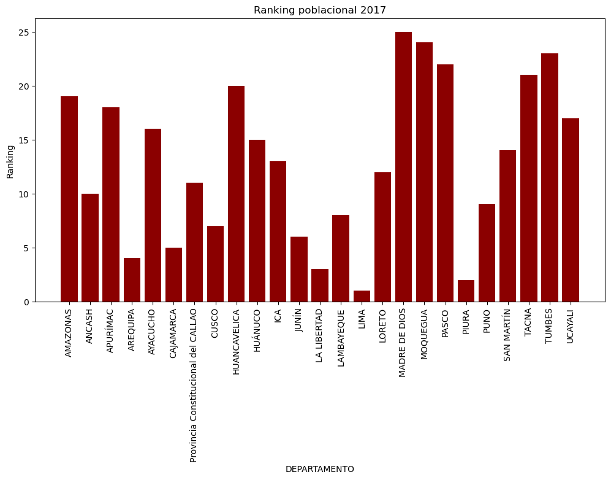

```python
import matplotlib.pyplot as plt

fig, ax = plt.subplots(figsize=(12,6))

ax.bar(x = ranking_poblacion.index, height= ranking_poblacion["Ranking poblacional"], color="darkred")
ax.set_xlabel('DEPARTAMENTO')
ax.set_ylabel('Ranking')
ax.set_title('Ranking poblacional 2017')
ax.tick_params(axis="x", rotation=90)
plt.show()
```

```python
ranking_IDH = data_IDH[data_IDH.index=="Ranking IDH"]
ranking_IDH = ranking_IDH.T
ranking_IDH
```

| DEPARTAMENTO | Ranking IDH |
| --- | --- |
| AMAZONAS | 21 |
| ANCASH | 12 |
| APURÍMAC | 22 |
| AREQUIPA | 4 |
| AYACUCHO | 23 |
| CAJAMARCA | 24 |
| Provincia Constitucional del CALLAO | 2 |
| CUSCO | 15 |
| HUANCAVELICA | 25 |
| HUÁNUCO | 19 |
| ICA | 5 |
| JUNÍN | 11 |
| LA LIBERTAD | 10 |
| LAMBAYEQUE | 9 |
| LIMA | 1 |
| LORETO | 18 |
| MADRE DE DIOS | 7 |
| MOQUEGUA | 3 |
| PASCO | 17 |
| PIURA | 13 |
| PUNO | 20 |
| SAN MARTÍN | 16 |
| TACNA | 6 |
| TUMBES | 8 |
| UCAYALI | 14 |

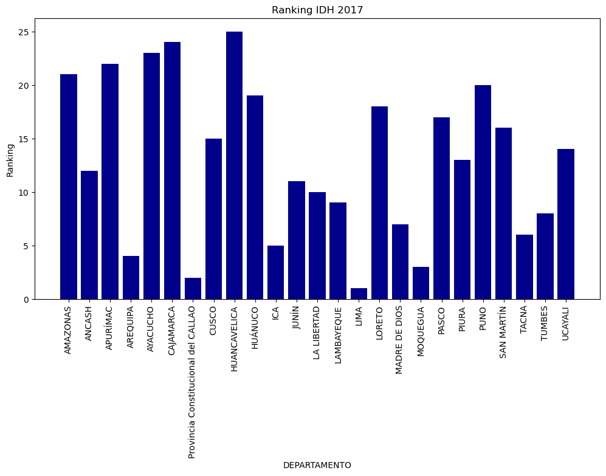

```python
fig, ax = plt.subplots(figsize=(12,6))

ax.bar(x = ranking_IDH.index, height= ranking_IDH["Ranking IDH"], color="darkblue")
ax.set_xlabel('DEPARTAMENTO')
ax.set_ylabel('Ranking')
ax.set_title('Ranking IDH 2017')
ax.tick_params(axis="x", rotation=90)
plt.show()
```

```python
ranking_poblacion_IDH = data_IDH[(data_IDH.index=="Ranking poblacional") | (data_IDH.index=="Ranking IDH")]
ranking_poblacion_IDH = ranking_poblacion_IDH.T
ranking_poblacion_IDH
```

| DEPARTAMENTO | Ranking poblacional | Ranking IDH |
| --- | --- | --- |
| AMAZONAS | 19 | 21 |
| ANCASH | 10 | 12 |
| APURÍMAC | 18 | 22 |
| AREQUIPA | 4 | 4 |
| AYACUCHO | 16 | 23 |
| CAJAMARCA | 5 | 24 |
| Provincia Constitucional del CALLAO | 11 | 2 |
| CUSCO | 7 | 15 |
| HUANCAVELICA | 20 | 25 |
| HUÁNUCO | 15 | 19 |
| ICA | 13 | 5 |
| JUNÍN | 6 | 11 |
| LA LIBERTAD | 3 | 10 |
| LAMBAYEQUE | 8 | 9 |
| LIMA | 1 | 1 |
| LORETO | 12 | 18 |
| MADRE DE DIOS | 25 | 7 |
| MOQUEGUA | 24 | 3 |
| PASCO | 22 | 17 |
| PIURA | 2 | 13 |
| PUNO | 9 | 20 |
| SAN MARTÍN | 14 | 16 |
| TACNA | 21 | 6 |
| TUMBES | 23 | 8 |
| UCAYALI | 17 | 14 |

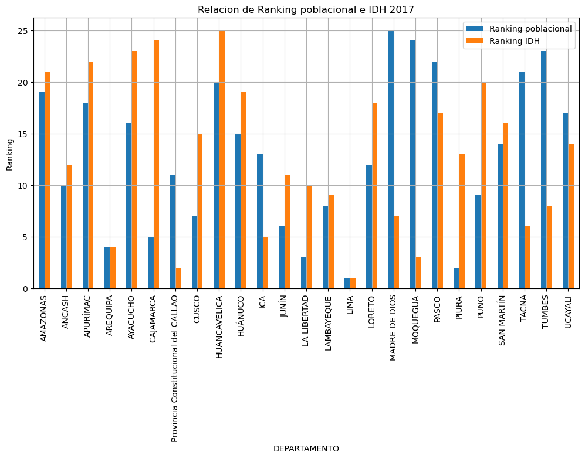

```python
fig, ax = plt.subplots(figsize=(12, 6))

ranking_poblacion_IDH.plot(kind='bar', ax=ax)

ax.set_xlabel('DEPARTAMENTO')
ax.set_ylabel('Ranking')
ax.set_title('Relacion de Ranking poblacional e IDH 2017')

ax.grid(True)

plt.show()
```

```python
import pandas as pd
data_distrital = pd.read_excel("IDH_PNUD_2017-1 (1).xlsx", sheet_name = "IDH 2017", header = 2)
data_distrital
```

|  | UBIGEO | DEPARTAMENTO | Unnamed: 2 | Unnamed: 3 | Unnamed: 4 | Población total | Esperanza de vida al nacer | Población (18 años) con Educ. secundaria completa | Años de educación (Poblac. 25 y más) | Ingreso familiar per cápita | Unnamed: 10 | Índice de Desarrollo Humano (IDH) | Unnamed: 12 | Esperanza de vida al nacer.1 | Población (18 años) con Educ. secundaria completa.1 | Años de educación (Poblac. 25 y más).1 | Logro educativo | Ingreso familiar per cápita.1 |
| --- | --- | --- | --- | --- | --- | --- | --- | --- | --- | --- | --- | --- | --- | --- | --- | --- | --- | --- |
| 0 | NaN | NaN | Provincia | NaN | NaN | NaN | NaN | NaN | NaN | NaN | NaN | NaN | NaN | NaN | NaN | NaN | NaN | NaN |
| 1 | NaN | NaN | Distrito | NaN | NaN | habitantes | Años | (%) | Años | N.S. mes | NaN | NaN | NaN | NaN | NaN | NaN | NaN | NaN |
| 2 | NaN | NaN | NaN | NaN | NaN | NaN | NaN | NaN | NaN | NaN | NaN | NaN | NaN | NaN | NaN | NaN | NaN | NaN |
| 3 | NaN | NaN | NaN | NaN | NaN | NaN | NaN | NaN | NaN | NaN | NaN | NaN | NaN | NaN | NaN | NaN | NaN | NaN |
| 4 | 000000 | PERÚ a/ | NaN | NaN | NaN | 29381884 | 75.52714 | 67.108865 | 8.78599 | 990.116633 | NaN | 0.572345 | NaN | 0.842119 | 0.671089 | 0.491971 | 0.574592 | 0.387471 |
| ... | ... | ... | ... | ... | ... | ... | ... | ... | ... | ... | ... | ... | ... | ... | ... | ... | ... | ... |
| 2297 | 250401 | 1 | Purus | NaN | NaN | 2860 | 66.458846 | 20.197044 | 7.2707 | 517.759563 | NaN | 0.335455 | NaN | 0.690981 | 0.201970 | 0.385261 | 0.278947 | 0.195846 |
| 2298 | NaN | NaN | NaN | NaN | NaN | NaN | NaN | NaN | NaN | NaN | NaN | NaN | NaN | NaN | NaN | NaN | NaN | NaN |
| 2299 | Fuente: INEI. Censo de Población y Vivienda 20... | NaN | NaN | NaN | NaN | NaN | NaN | NaN | NaN | NaN | NaN | NaN | NaN | NaN | NaN | NaN | NaN | NaN |
| 2300 | Elaboración: PNUD / Unidad del Informe sobre D... | NaN | NaN | NaN | NaN | NaN | NaN | NaN | NaN | NaN | NaN | NaN | NaN | NaN | NaN | NaN | NaN | NaN |
| 2301 | 1/ Provincias de Lima y Callao. | NaN | NaN | NaN | NaN | NaN | NaN | NaN | NaN | NaN | NaN | NaN | NaN | NaN | NaN | NaN | NaN | NaN |

2302 rows × 18 columns

```python
data_distrital = data_distrital.drop([2298,2299,2300,2301], axis = 0)
data_distrital
```

|  | UBIGEO | DEPARTAMENTO | Unnamed: 2 | Unnamed: 3 | Unnamed: 4 | Población total | Esperanza de vida al nacer | Población (18 años) con Educ. secundaria completa | Años de educación (Poblac. 25 y más) | Ingreso familiar per cápita | Unnamed: 10 | Índice de Desarrollo Humano (IDH) | Unnamed: 12 | Esperanza de vida al nacer.1 | Población (18 años) con Educ. secundaria completa.1 | Años de educación (Poblac. 25 y más).1 | Logro educativo | Ingreso familiar per cápita.1 |
| --- | --- | --- | --- | --- | --- | --- | --- | --- | --- | --- | --- | --- | --- | --- | --- | --- | --- | --- |
| 0 | NaN | NaN | Provincia | NaN | NaN | NaN | NaN | NaN | NaN | NaN | NaN | NaN | NaN | NaN | NaN | NaN | NaN | NaN |
| 1 | NaN | NaN | Distrito | NaN | NaN | habitantes | Años | (%) | Años | N.S. mes | NaN | NaN | NaN | NaN | NaN | NaN | NaN | NaN |
| 2 | NaN | NaN | NaN | NaN | NaN | NaN | NaN | NaN | NaN | NaN | NaN | NaN | NaN | NaN | NaN | NaN | NaN | NaN |
| 3 | NaN | NaN | NaN | NaN | NaN | NaN | NaN | NaN | NaN | NaN | NaN | NaN | NaN | NaN | NaN | NaN | NaN | NaN |
| 4 | 000000 | PERÚ a/ | NaN | NaN | NaN | 29381884 | 75.52714 | 67.108865 | 8.78599 | 990.116633 | NaN | 0.572345 | NaN | 0.842119 | 0.671089 | 0.491971 | 0.574592 | 0.387471 |
| ... | ... | ... | ... | ... | ... | ... | ... | ... | ... | ... | ... | ... | ... | ... | ... | ... | ... | ... |
| 2293 | 250304 | 4 | Neshuya | NaN | NaN | 7594 | 82.296773 | 45.68082 | 6.1251 | 614.015288 | NaN | 0.437379 | NaN | 0.954946 | 0.456808 | 0.304585 | 0.373010 | 0.234895 |
| 2294 | 250305 | 5 | Alexander Von Humboldt | NaN | NaN | 5137 | 83.636475 | 42.929293 | 5.8305 | 582.998041 | NaN | 0.423282 | NaN | 0.977275 | 0.429293 | 0.283838 | 0.349070 | 0.222312 |
| 2295 | NaN | NaN | NaN | NaN | NaN |  | NaN | NaN | NaN | NaN | NaN | NaN | NaN | NaN | NaN | NaN | NaN | NaN |
| 2296 | 250400 | NaN | Purús | NaN | NaN | 2860 | 66.458846 | 20.197044 | 7.271105 | 517.759563 | NaN | 0.335459 | NaN | 0.690981 | 0.201970 | 0.385289 | 0.278957 | 0.195846 |
| 2297 | 250401 | 1 | Purus | NaN | NaN | 2860 | 66.458846 | 20.197044 | 7.2707 | 517.759563 | NaN | 0.335455 | NaN | 0.690981 | 0.201970 | 0.385261 | 0.278947 | 0.195846 |

2298 rows × 18 columns

```python
data_distrital = data_distrital.drop([0,2,3], axis = 0)
data_distrital.head(10)
```

|  | UBIGEO | DEPARTAMENTO | Unnamed: 2 | Unnamed: 3 | Unnamed: 4 | Población total | Esperanza de vida al nacer | Población (18 años) con Educ. secundaria completa | Años de educación (Poblac. 25 y más) | Ingreso familiar per cápita | Unnamed: 10 | Índice de Desarrollo Humano (IDH) | Unnamed: 12 | Esperanza de vida al nacer.1 | Población (18 años) con Educ. secundaria completa.1 | Años de educación (Poblac. 25 y más).1 | Logro educativo | Ingreso familiar per cápita.1 |
| --- | --- | --- | --- | --- | --- | --- | --- | --- | --- | --- | --- | --- | --- | --- | --- | --- | --- | --- |
| 1 | NaN | NaN | Distrito | NaN | NaN | habitantes | Años | (%) | Años | N.S. mes | NaN | NaN | NaN | NaN | NaN | NaN | NaN | NaN |
| 4 | 000000 | PERÚ a/ | NaN | NaN | NaN | 29381884 | 75.52714 | 67.108865 | 8.78599 | 990.116633 | NaN | 0.572345 | NaN | 0.842119 | 0.671089 | 0.491971 | 0.574592 | 0.387471 |
| 5 | NaN | NaN | NaN | NaN | NaN |  | NaN | NaN | NaN | NaN | NaN | NaN | NaN | NaN | NaN | NaN | NaN | NaN |
| 6 | 010000 | AMAZONAS | NaN | NaN | NaN | 379384 | 73.306564 | 46.859333 | 6.050521 | 629.7113 | NaN | 0.417452 | NaN | 0.805109 | 0.468593 | 0.299332 | 0.374520 | 0.241262 |
| 7 | 010100 | NaN | Chachapoyas | NaN | NaN | 55506 | 74.439914 | 62.945571 | 7.841138 | 838.090033 | NaN | 0.517913 | NaN | 0.823999 | 0.629456 | 0.425432 | 0.517485 | 0.325797 |
| 8 | 010101 | 1 | Chachapoyas | NaN | NaN | 32589 | 73.297544 | 74.699578 | 9.7582 | 1086.762736 | NaN | 0.605711 | NaN | 0.804959 | 0.746996 | 0.560437 | 0.647027 | 0.426679 |
| 9 | 010102 | 2 | Asuncion | NaN | NaN | 262 | 72.349067 | 66.666667 | 5.8662 | 569.610318 | NaN | 0.421303 | NaN | 0.789151 | 0.666667 | 0.286352 | 0.436923 | 0.216880 |
| 10 | 010103 | 3 | Balsas | NaN | NaN | 1136 | 68.710568 | 30.769231 | 4.9866 | 362.999904 | NaN | 0.294232 | NaN | 0.728509 | 0.307692 | 0.224408 | 0.262771 | 0.133063 |
| 11 | 010104 | 4 | Cheto | NaN | NaN | 642 | 83.896326 | 49.019608 | 4.2735 | 342.569379 | NaN | 0.329549 | NaN | 0.981605 | 0.490196 | 0.174190 | 0.292211 | 0.124775 |
| 12 | 010105 | 5 | Chiliquin | NaN | NaN | 585 | 77.261089 | 34.615385 | 3.304 | 308.814375 | NaN | 0.264602 | NaN | 0.871018 | 0.346154 | 0.105915 | 0.191476 | 0.111081 |

```python
data_distrital = data_distrital.drop(["Unnamed: 3","Unnamed: 4","Unnamed: 12"], axis = 1)
data_distrital.head(10)
```

|  | UBIGEO | DEPARTAMENTO | Unnamed: 2 | Población total | Esperanza de vida al nacer | Población (18 años) con Educ. secundaria completa | Años de educación (Poblac. 25 y más) | Ingreso familiar per cápita | Unnamed: 10 | Índice de Desarrollo Humano (IDH) | Esperanza de vida al nacer.1 | Población (18 años) con Educ. secundaria completa.1 | Años de educación (Poblac. 25 y más).1 | Logro educativo | Ingreso familiar per cápita.1 |
| --- | --- | --- | --- | --- | --- | --- | --- | --- | --- | --- | --- | --- | --- | --- | --- |
| 1 | NaN | NaN | Distrito | habitantes | Años | (%) | Años | N.S. mes | NaN | NaN | NaN | NaN | NaN | NaN | NaN |
| 4 | 000000 | PERÚ a/ | NaN | 29381884 | 75.52714 | 67.108865 | 8.78599 | 990.116633 | NaN | 0.572345 | 0.842119 | 0.671089 | 0.491971 | 0.574592 | 0.387471 |
| 5 | NaN | NaN | NaN |  | NaN | NaN | NaN | NaN | NaN | NaN | NaN | NaN | NaN | NaN | NaN |
| 6 | 010000 | AMAZONAS | NaN | 379384 | 73.306564 | 46.859333 | 6.050521 | 629.7113 | NaN | 0.417452 | 0.805109 | 0.468593 | 0.299332 | 0.374520 | 0.241262 |
| 7 | 010100 | NaN | Chachapoyas | 55506 | 74.439914 | 62.945571 | 7.841138 | 838.090033 | NaN | 0.517913 | 0.823999 | 0.629456 | 0.425432 | 0.517485 | 0.325797 |
| 8 | 010101 | 1 | Chachapoyas | 32589 | 73.297544 | 74.699578 | 9.7582 | 1086.762736 | NaN | 0.605711 | 0.804959 | 0.746996 | 0.560437 | 0.647027 | 0.426679 |
| 9 | 010102 | 2 | Asuncion | 262 | 72.349067 | 66.666667 | 5.8662 | 569.610318 | NaN | 0.421303 | 0.789151 | 0.666667 | 0.286352 | 0.436923 | 0.216880 |
| 10 | 010103 | 3 | Balsas | 1136 | 68.710568 | 30.769231 | 4.9866 | 362.999904 | NaN | 0.294232 | 0.728509 | 0.307692 | 0.224408 | 0.262771 | 0.133063 |
| 11 | 010104 | 4 | Cheto | 642 | 83.896326 | 49.019608 | 4.2735 | 342.569379 | NaN | 0.329549 | 0.981605 | 0.490196 | 0.174190 | 0.292211 | 0.124775 |
| 12 | 010105 | 5 | Chiliquin | 585 | 77.261089 | 34.615385 | 3.304 | 308.814375 | NaN | 0.264602 | 0.871018 | 0.346154 | 0.105915 | 0.191476 | 0.111081 |

```python
data_distrital = data_distrital.drop(5, axis = 0)
data_distrital.head(10)
```

|  | UBIGEO | DEPARTAMENTO | Unnamed: 2 | Población total | Esperanza de vida al nacer | Población (18 años) con Educ. secundaria completa | Años de educación (Poblac. 25 y más) | Ingreso familiar per cápita | Unnamed: 10 | Índice de Desarrollo Humano (IDH) | Esperanza de vida al nacer.1 | Población (18 años) con Educ. secundaria completa.1 | Años de educación (Poblac. 25 y más).1 | Logro educativo | Ingreso familiar per cápita.1 |
| --- | --- | --- | --- | --- | --- | --- | --- | --- | --- | --- | --- | --- | --- | --- | --- |
| 1 | NaN | NaN | Distrito | habitantes | Años | (%) | Años | N.S. mes | NaN | NaN | NaN | NaN | NaN | NaN | NaN |
| 4 | 000000 | PERÚ a/ | NaN | 29381884 | 75.52714 | 67.108865 | 8.78599 | 990.116633 | NaN | 0.572345 | 0.842119 | 0.671089 | 0.491971 | 0.574592 | 0.387471 |
| 6 | 010000 | AMAZONAS | NaN | 379384 | 73.306564 | 46.859333 | 6.050521 | 629.7113 | NaN | 0.417452 | 0.805109 | 0.468593 | 0.299332 | 0.374520 | 0.241262 |
| 7 | 010100 | NaN | Chachapoyas | 55506 | 74.439914 | 62.945571 | 7.841138 | 838.090033 | NaN | 0.517913 | 0.823999 | 0.629456 | 0.425432 | 0.517485 | 0.325797 |
| 8 | 010101 | 1 | Chachapoyas | 32589 | 73.297544 | 74.699578 | 9.7582 | 1086.762736 | NaN | 0.605711 | 0.804959 | 0.746996 | 0.560437 | 0.647027 | 0.426679 |
| 9 | 010102 | 2 | Asuncion | 262 | 72.349067 | 66.666667 | 5.8662 | 569.610318 | NaN | 0.421303 | 0.789151 | 0.666667 | 0.286352 | 0.436923 | 0.216880 |
| 10 | 010103 | 3 | Balsas | 1136 | 68.710568 | 30.769231 | 4.9866 | 362.999904 | NaN | 0.294232 | 0.728509 | 0.307692 | 0.224408 | 0.262771 | 0.133063 |
| 11 | 010104 | 4 | Cheto | 642 | 83.896326 | 49.019608 | 4.2735 | 342.569379 | NaN | 0.329549 | 0.981605 | 0.490196 | 0.174190 | 0.292211 | 0.124775 |
| 12 | 010105 | 5 | Chiliquin | 585 | 77.261089 | 34.615385 | 3.304 | 308.814375 | NaN | 0.264602 | 0.871018 | 0.346154 | 0.105915 | 0.191476 | 0.111081 |
| 13 | 010106 | 6 | Chuquibamba | 1781 | 66.224623 | 28.571429 | 5.6499 | 233.742394 | NaN | 0.248891 | 0.687077 | 0.285714 | 0.271120 | 0.278321 | 0.080626 |

```python
data_distrital= data_distrital.rename(columns = {"Unnamed: 2": "Distrito", "Población total" : "Poblacion total (habitantes)",
                                                 "Esperanza de vida al nacer":"Esperanza de vida al nacer (en años)"
                                                }
                                     )
data_distrital.head(10)
```

|  | UBIGEO | DEPARTAMENTO | Distrito | Poblacion total (habitantes) | Esperanza de vida al nacer (en años) | Población (18 años) con Educ. secundaria completa | Años de educación (Poblac. 25 y más) | Ingreso familiar per cápita | Unnamed: 10 | Índice de Desarrollo Humano (IDH) | Esperanza de vida al nacer.1 | Población (18 años) con Educ. secundaria completa.1 | Años de educación (Poblac. 25 y más).1 | Logro educativo | Ingreso familiar per cápita.1 |
| --- | --- | --- | --- | --- | --- | --- | --- | --- | --- | --- | --- | --- | --- | --- | --- |
| 1 | NaN | NaN | Distrito | habitantes | Años | (%) | Años | N.S. mes | NaN | NaN | NaN | NaN | NaN | NaN | NaN |
| 4 | 000000 | PERÚ a/ | NaN | 29381884 | 75.52714 | 67.108865 | 8.78599 | 990.116633 | NaN | 0.572345 | 0.842119 | 0.671089 | 0.491971 | 0.574592 | 0.387471 |
| 6 | 010000 | AMAZONAS | NaN | 379384 | 73.306564 | 46.859333 | 6.050521 | 629.7113 | NaN | 0.417452 | 0.805109 | 0.468593 | 0.299332 | 0.374520 | 0.241262 |
| 7 | 010100 | NaN | Chachapoyas | 55506 | 74.439914 | 62.945571 | 7.841138 | 838.090033 | NaN | 0.517913 | 0.823999 | 0.629456 | 0.425432 | 0.517485 | 0.325797 |
| 8 | 010101 | 1 | Chachapoyas | 32589 | 73.297544 | 74.699578 | 9.7582 | 1086.762736 | NaN | 0.605711 | 0.804959 | 0.746996 | 0.560437 | 0.647027 | 0.426679 |
| 9 | 010102 | 2 | Asuncion | 262 | 72.349067 | 66.666667 | 5.8662 | 569.610318 | NaN | 0.421303 | 0.789151 | 0.666667 | 0.286352 | 0.436923 | 0.216880 |
| 10 | 010103 | 3 | Balsas | 1136 | 68.710568 | 30.769231 | 4.9866 | 362.999904 | NaN | 0.294232 | 0.728509 | 0.307692 | 0.224408 | 0.262771 | 0.133063 |
| 11 | 010104 | 4 | Cheto | 642 | 83.896326 | 49.019608 | 4.2735 | 342.569379 | NaN | 0.329549 | 0.981605 | 0.490196 | 0.174190 | 0.292211 | 0.124775 |
| 12 | 010105 | 5 | Chiliquin | 585 | 77.261089 | 34.615385 | 3.304 | 308.814375 | NaN | 0.264602 | 0.871018 | 0.346154 | 0.105915 | 0.191476 | 0.111081 |
| 13 | 010106 | 6 | Chuquibamba | 1781 | 66.224623 | 28.571429 | 5.6499 | 233.742394 | NaN | 0.248891 | 0.687077 | 0.285714 | 0.271120 | 0.278321 | 0.080626 |

```python
data_distrital = data_distrital.drop(1, axis = 0)
data_distrital.head(10)
```

|  | UBIGEO | DEPARTAMENTO | Distrito | Poblacion total (habitantes) | Esperanza de vida al nacer (en años) | Población (18 años) con Educ. secundaria completa | Años de educación (Poblac. 25 y más) | Ingreso familiar per cápita | Unnamed: 10 | Índice de Desarrollo Humano (IDH) | Esperanza de vida al nacer.1 | Población (18 años) con Educ. secundaria completa.1 | Años de educación (Poblac. 25 y más).1 | Logro educativo | Ingreso familiar per cápita.1 |
| --- | --- | --- | --- | --- | --- | --- | --- | --- | --- | --- | --- | --- | --- | --- | --- |
| 4 | 000000 | PERÚ a/ | NaN | 29381884 | 75.52714 | 67.108865 | 8.78599 | 990.116633 | NaN | 0.572345 | 0.842119 | 0.671089 | 0.491971 | 0.574592 | 0.387471 |
| 6 | 010000 | AMAZONAS | NaN | 379384 | 73.306564 | 46.859333 | 6.050521 | 629.7113 | NaN | 0.417452 | 0.805109 | 0.468593 | 0.299332 | 0.374520 | 0.241262 |
| 7 | 010100 | NaN | Chachapoyas | 55506 | 74.439914 | 62.945571 | 7.841138 | 838.090033 | NaN | 0.517913 | 0.823999 | 0.629456 | 0.425432 | 0.517485 | 0.325797 |
| 8 | 010101 | 1 | Chachapoyas | 32589 | 73.297544 | 74.699578 | 9.7582 | 1086.762736 | NaN | 0.605711 | 0.804959 | 0.746996 | 0.560437 | 0.647027 | 0.426679 |
| 9 | 010102 | 2 | Asuncion | 262 | 72.349067 | 66.666667 | 5.8662 | 569.610318 | NaN | 0.421303 | 0.789151 | 0.666667 | 0.286352 | 0.436923 | 0.216880 |
| 10 | 010103 | 3 | Balsas | 1136 | 68.710568 | 30.769231 | 4.9866 | 362.999904 | NaN | 0.294232 | 0.728509 | 0.307692 | 0.224408 | 0.262771 | 0.133063 |
| 11 | 010104 | 4 | Cheto | 642 | 83.896326 | 49.019608 | 4.2735 | 342.569379 | NaN | 0.329549 | 0.981605 | 0.490196 | 0.174190 | 0.292211 | 0.124775 |
| 12 | 010105 | 5 | Chiliquin | 585 | 77.261089 | 34.615385 | 3.304 | 308.814375 | NaN | 0.264602 | 0.871018 | 0.346154 | 0.105915 | 0.191476 | 0.111081 |
| 13 | 010106 | 6 | Chuquibamba | 1781 | 66.224623 | 28.571429 | 5.6499 | 233.742394 | NaN | 0.248891 | 0.687077 | 0.285714 | 0.271120 | 0.278321 | 0.080626 |
| 14 | 010107 | 7 | Granada | 480 | 65.21454 | 24.137931 | 4.1008 | 793.644551 | NaN | 0.344244 | 0.670242 | 0.241379 | 0.162028 | 0.197763 | 0.307767 |

```python
data_distrital = data_distrital.drop(["Unnamed: 10"], axis = 1)
data_distrital.head(10)
```

|  | UBIGEO | DEPARTAMENTO | Distrito | Poblacion total (habitantes) | Esperanza de vida al nacer (en años) | Población (18 años) con Educ. secundaria completa | Años de educación (Poblac. 25 y más) | Ingreso familiar per cápita | Índice de Desarrollo Humano (IDH) | Esperanza de vida al nacer.1 | Población (18 años) con Educ. secundaria completa.1 | Años de educación (Poblac. 25 y más).1 | Logro educativo | Ingreso familiar per cápita.1 |
| --- | --- | --- | --- | --- | --- | --- | --- | --- | --- | --- | --- | --- | --- | --- |
| 4 | 000000 | PERÚ a/ | NaN | 29381884 | 75.52714 | 67.108865 | 8.78599 | 990.116633 | 0.572345 | 0.842119 | 0.671089 | 0.491971 | 0.574592 | 0.387471 |
| 6 | 010000 | AMAZONAS | NaN | 379384 | 73.306564 | 46.859333 | 6.050521 | 629.7113 | 0.417452 | 0.805109 | 0.468593 | 0.299332 | 0.374520 | 0.241262 |
| 7 | 010100 | NaN | Chachapoyas | 55506 | 74.439914 | 62.945571 | 7.841138 | 838.090033 | 0.517913 | 0.823999 | 0.629456 | 0.425432 | 0.517485 | 0.325797 |
| 8 | 010101 | 1 | Chachapoyas | 32589 | 73.297544 | 74.699578 | 9.7582 | 1086.762736 | 0.605711 | 0.804959 | 0.746996 | 0.560437 | 0.647027 | 0.426679 |
| 9 | 010102 | 2 | Asuncion | 262 | 72.349067 | 66.666667 | 5.8662 | 569.610318 | 0.421303 | 0.789151 | 0.666667 | 0.286352 | 0.436923 | 0.216880 |
| 10 | 010103 | 3 | Balsas | 1136 | 68.710568 | 30.769231 | 4.9866 | 362.999904 | 0.294232 | 0.728509 | 0.307692 | 0.224408 | 0.262771 | 0.133063 |
| 11 | 010104 | 4 | Cheto | 642 | 83.896326 | 49.019608 | 4.2735 | 342.569379 | 0.329549 | 0.981605 | 0.490196 | 0.174190 | 0.292211 | 0.124775 |
| 12 | 010105 | 5 | Chiliquin | 585 | 77.261089 | 34.615385 | 3.304 | 308.814375 | 0.264602 | 0.871018 | 0.346154 | 0.105915 | 0.191476 | 0.111081 |
| 13 | 010106 | 6 | Chuquibamba | 1781 | 66.224623 | 28.571429 | 5.6499 | 233.742394 | 0.248891 | 0.687077 | 0.285714 | 0.271120 | 0.278321 | 0.080626 |
| 14 | 010107 | 7 | Granada | 480 | 65.21454 | 24.137931 | 4.1008 | 793.644551 | 0.344244 | 0.670242 | 0.241379 | 0.162028 | 0.197763 | 0.307767 |

```python
data_distrital.head(25)
```

|  | UBIGEO | DEPARTAMENTO | Distrito | Poblacion total (habitantes) | Esperanza de vida al nacer (en años) | Población (18 años) con Educ. secundaria completa | Años de educación (Poblac. 25 y más) | Ingreso familiar per cápita | Índice de Desarrollo Humano (IDH) | Esperanza de vida al nacer.1 | Población (18 años) con Educ. secundaria completa.1 | Años de educación (Poblac. 25 y más).1 | Logro educativo | Ingreso familiar per cápita.1 |
| --- | --- | --- | --- | --- | --- | --- | --- | --- | --- | --- | --- | --- | --- | --- |
| 4 | 000000 | PERÚ a/ | NaN | 29381884 | 75.52714 | 67.108865 | 8.78599 | 990.116633 | 0.572345 | 0.842119 | 0.671089 | 0.491971 | 0.574592 | 0.387471 |
| 6 | 010000 | AMAZONAS | NaN | 379384 | 73.306564 | 46.859333 | 6.050521 | 629.7113 | 0.417452 | 0.805109 | 0.468593 | 0.299332 | 0.374520 | 0.241262 |
| 7 | 010100 | NaN | Chachapoyas | 55506 | 74.439914 | 62.945571 | 7.841138 | 838.090033 | 0.517913 | 0.823999 | 0.629456 | 0.425432 | 0.517485 | 0.325797 |
| 8 | 010101 | 1 | Chachapoyas | 32589 | 73.297544 | 74.699578 | 9.7582 | 1086.762736 | 0.605711 | 0.804959 | 0.746996 | 0.560437 | 0.647027 | 0.426679 |
| 9 | 010102 | 2 | Asuncion | 262 | 72.349067 | 66.666667 | 5.8662 | 569.610318 | 0.421303 | 0.789151 | 0.666667 | 0.286352 | 0.436923 | 0.216880 |
| 10 | 010103 | 3 | Balsas | 1136 | 68.710568 | 30.769231 | 4.9866 | 362.999904 | 0.294232 | 0.728509 | 0.307692 | 0.224408 | 0.262771 | 0.133063 |
| 11 | 010104 | 4 | Cheto | 642 | 83.896326 | 49.019608 | 4.2735 | 342.569379 | 0.329549 | 0.981605 | 0.490196 | 0.174190 | 0.292211 | 0.124775 |
| 12 | 010105 | 5 | Chiliquin | 585 | 77.261089 | 34.615385 | 3.304 | 308.814375 | 0.264602 | 0.871018 | 0.346154 | 0.105915 | 0.191476 | 0.111081 |
| 13 | 010106 | 6 | Chuquibamba | 1781 | 66.224623 | 28.571429 | 5.6499 | 233.742394 | 0.248891 | 0.687077 | 0.285714 | 0.271120 | 0.278321 | 0.080626 |
| 14 | 010107 | 7 | Granada | 480 | 65.21454 | 24.137931 | 4.1008 | 793.644551 | 0.344244 | 0.670242 | 0.241379 | 0.162028 | 0.197763 | 0.307767 |
| 15 | 010108 | 8 | Huancas | 1258 | 75.936481 | 61.363636 | 5.9463 | 533.839876 | 0.417402 | 0.848941 | 0.613636 | 0.291993 | 0.423294 | 0.202369 |
| 16 | 010109 | 9 | La Jalca | 3978 | 77.406123 | 40.055249 | 4.1929 | 337.642315 | 0.303154 | 0.873435 | 0.400552 | 0.168514 | 0.259805 | 0.122776 |
| 17 | 010110 | 10 | Leimebamba | 3620 | 70.657985 | 37.545126 | 6.194 | 598.861025 | 0.390027 | 0.760966 | 0.375451 | 0.309437 | 0.340849 | 0.228747 |
| 18 | 010111 | 11 | Levanto | 794 | 83.100074 | 37.209302 | 3.7781 | 430.322736 | 0.328213 | 0.968335 | 0.372093 | 0.139303 | 0.227670 | 0.160374 |
| 19 | 010112 | 12 | Magdalena | 852 | 73.319314 | 50 | 6.1648 | 709.866478 | 0.442145 | 0.805322 | 0.500000 | 0.307380 | 0.392033 | 0.273780 |
| 20 | 010113 | 13 | Mariscal Castilla | 1367 | 68.868611 | 47.191011 | 6.6932 | 807.297016 | 0.452047 | 0.731144 | 0.471910 | 0.344592 | 0.403257 | 0.313305 |
| 21 | 010114 | 14 | Molinopampa | 2176 | 71.988483 | 50.359712 | 5.0068 | 472.865841 | 0.360661 | 0.783141 | 0.503597 | 0.225831 | 0.337236 | 0.177633 |
| 22 | 010115 | 15 | Montevideo | 496 | 72.133362 | 40 | 7.1372 | 680.945441 | 0.430559 | 0.785556 | 0.400000 | 0.375859 | 0.387742 | 0.262047 |
| 23 | 010116 | 16 | Olleros | 375 | 76.882768 | 50 | 5.4701 | 471.277589 | 0.380335 | 0.864713 | 0.500000 | 0.258458 | 0.359484 | 0.176989 |
| 24 | 010117 | 17 | Quinjalca | 769 | 79.460753 | 48.888889 | 3.2533 | 587.309523 | 0.356981 | 0.907679 | 0.488889 | 0.102345 | 0.223686 | 0.224061 |
| 25 | 010118 | 18 | San Francisco De Daguas | 295 | 73.247834 | 52.173913 | 7.4503 | 718.898017 | 0.466702 | 0.804131 | 0.521739 | 0.397908 | 0.455636 | 0.277443 |
| 26 | 010119 | 19 | San Isidro De Maino | 580 | 69.872806 | 35.897436 | 4.3358 | 291.162878 | 0.269976 | 0.747880 | 0.358974 | 0.178577 | 0.253189 | 0.103920 |
| 27 | 010120 | 20 | Soloco | 1224 | 79.125445 | 34.090909 | 4.3878 | 484.496977 | 0.344826 | 0.902091 | 0.340909 | 0.182239 | 0.249253 | 0.182352 |
| 28 | 010121 | 21 | Sonche | 247 | 80.339833 | 32 | 4.1184 | 572.40193 | 0.358205 | 0.922331 | 0.320000 | 0.163268 | 0.228573 | 0.218013 |
| 29 | NaN | NaN | NaN |  | NaN | NaN | NaN | NaN | NaN | NaN | NaN | NaN | NaN | NaN |

```python
data_distrital = data_distrital.drop(4, axis = 0)
data_distrital.head(24)
```

|  | UBIGEO | DEPARTAMENTO | Distrito | Poblacion total (habitantes) | Esperanza de vida al nacer (en años) | Población (18 años) con Educ. secundaria completa | Años de educación (Poblac. 25 y más) | Ingreso familiar per cápita | Índice de Desarrollo Humano (IDH) | Esperanza de vida al nacer.1 | Población (18 años) con Educ. secundaria completa.1 | Años de educación (Poblac. 25 y más).1 | Logro educativo | Ingreso familiar per cápita.1 |
| --- | --- | --- | --- | --- | --- | --- | --- | --- | --- | --- | --- | --- | --- | --- |
| 6 | 010000 | AMAZONAS | NaN | 379384 | 73.306564 | 46.859333 | 6.050521 | 629.7113 | 0.417452 | 0.805109 | 0.468593 | 0.299332 | 0.374520 | 0.241262 |
| 7 | 010100 | NaN | Chachapoyas | 55506 | 74.439914 | 62.945571 | 7.841138 | 838.090033 | 0.517913 | 0.823999 | 0.629456 | 0.425432 | 0.517485 | 0.325797 |
| 8 | 010101 | 1 | Chachapoyas | 32589 | 73.297544 | 74.699578 | 9.7582 | 1086.762736 | 0.605711 | 0.804959 | 0.746996 | 0.560437 | 0.647027 | 0.426679 |
| 9 | 010102 | 2 | Asuncion | 262 | 72.349067 | 66.666667 | 5.8662 | 569.610318 | 0.421303 | 0.789151 | 0.666667 | 0.286352 | 0.436923 | 0.216880 |
| 10 | 010103 | 3 | Balsas | 1136 | 68.710568 | 30.769231 | 4.9866 | 362.999904 | 0.294232 | 0.728509 | 0.307692 | 0.224408 | 0.262771 | 0.133063 |
| 11 | 010104 | 4 | Cheto | 642 | 83.896326 | 49.019608 | 4.2735 | 342.569379 | 0.329549 | 0.981605 | 0.490196 | 0.174190 | 0.292211 | 0.124775 |
| 12 | 010105 | 5 | Chiliquin | 585 | 77.261089 | 34.615385 | 3.304 | 308.814375 | 0.264602 | 0.871018 | 0.346154 | 0.105915 | 0.191476 | 0.111081 |
| 13 | 010106 | 6 | Chuquibamba | 1781 | 66.224623 | 28.571429 | 5.6499 | 233.742394 | 0.248891 | 0.687077 | 0.285714 | 0.271120 | 0.278321 | 0.080626 |
| 14 | 010107 | 7 | Granada | 480 | 65.21454 | 24.137931 | 4.1008 | 793.644551 | 0.344244 | 0.670242 | 0.241379 | 0.162028 | 0.197763 | 0.307767 |
| 15 | 010108 | 8 | Huancas | 1258 | 75.936481 | 61.363636 | 5.9463 | 533.839876 | 0.417402 | 0.848941 | 0.613636 | 0.291993 | 0.423294 | 0.202369 |
| 16 | 010109 | 9 | La Jalca | 3978 | 77.406123 | 40.055249 | 4.1929 | 337.642315 | 0.303154 | 0.873435 | 0.400552 | 0.168514 | 0.259805 | 0.122776 |
| 17 | 010110 | 10 | Leimebamba | 3620 | 70.657985 | 37.545126 | 6.194 | 598.861025 | 0.390027 | 0.760966 | 0.375451 | 0.309437 | 0.340849 | 0.228747 |
| 18 | 010111 | 11 | Levanto | 794 | 83.100074 | 37.209302 | 3.7781 | 430.322736 | 0.328213 | 0.968335 | 0.372093 | 0.139303 | 0.227670 | 0.160374 |
| 19 | 010112 | 12 | Magdalena | 852 | 73.319314 | 50 | 6.1648 | 709.866478 | 0.442145 | 0.805322 | 0.500000 | 0.307380 | 0.392033 | 0.273780 |
| 20 | 010113 | 13 | Mariscal Castilla | 1367 | 68.868611 | 47.191011 | 6.6932 | 807.297016 | 0.452047 | 0.731144 | 0.471910 | 0.344592 | 0.403257 | 0.313305 |
| 21 | 010114 | 14 | Molinopampa | 2176 | 71.988483 | 50.359712 | 5.0068 | 472.865841 | 0.360661 | 0.783141 | 0.503597 | 0.225831 | 0.337236 | 0.177633 |
| 22 | 010115 | 15 | Montevideo | 496 | 72.133362 | 40 | 7.1372 | 680.945441 | 0.430559 | 0.785556 | 0.400000 | 0.375859 | 0.387742 | 0.262047 |
| 23 | 010116 | 16 | Olleros | 375 | 76.882768 | 50 | 5.4701 | 471.277589 | 0.380335 | 0.864713 | 0.500000 | 0.258458 | 0.359484 | 0.176989 |
| 24 | 010117 | 17 | Quinjalca | 769 | 79.460753 | 48.888889 | 3.2533 | 587.309523 | 0.356981 | 0.907679 | 0.488889 | 0.102345 | 0.223686 | 0.224061 |
| 25 | 010118 | 18 | San Francisco De Daguas | 295 | 73.247834 | 52.173913 | 7.4503 | 718.898017 | 0.466702 | 0.804131 | 0.521739 | 0.397908 | 0.455636 | 0.277443 |
| 26 | 010119 | 19 | San Isidro De Maino | 580 | 69.872806 | 35.897436 | 4.3358 | 291.162878 | 0.269976 | 0.747880 | 0.358974 | 0.178577 | 0.253189 | 0.103920 |
| 27 | 010120 | 20 | Soloco | 1224 | 79.125445 | 34.090909 | 4.3878 | 484.496977 | 0.344826 | 0.902091 | 0.340909 | 0.182239 | 0.249253 | 0.182352 |
| 28 | 010121 | 21 | Sonche | 247 | 80.339833 | 32 | 4.1184 | 572.40193 | 0.358205 | 0.922331 | 0.320000 | 0.163268 | 0.228573 | 0.218013 |
| 29 | NaN | NaN | NaN |  | NaN | NaN | NaN | NaN | NaN | NaN | NaN | NaN | NaN | NaN |

```python
data_distrital = data_distrital.drop(data_distrital.index[23:2298])
data_distrital
```

|  | UBIGEO | DEPARTAMENTO | Distrito | Poblacion total (habitantes) | Esperanza de vida al nacer (en años) | Población (18 años) con Educ. secundaria completa | Años de educación (Poblac. 25 y más) | Ingreso familiar per cápita | Índice de Desarrollo Humano (IDH) | Esperanza de vida al nacer.1 | Población (18 años) con Educ. secundaria completa.1 | Años de educación (Poblac. 25 y más).1 | Logro educativo | Ingreso familiar per cápita.1 |
| --- | --- | --- | --- | --- | --- | --- | --- | --- | --- | --- | --- | --- | --- | --- |
| 6 | 010000 | AMAZONAS | NaN | 379384 | 73.306564 | 46.859333 | 6.050521 | 629.7113 | 0.417452 | 0.805109 | 0.468593 | 0.299332 | 0.374520 | 0.241262 |
| 7 | 010100 | NaN | Chachapoyas | 55506 | 74.439914 | 62.945571 | 7.841138 | 838.090033 | 0.517913 | 0.823999 | 0.629456 | 0.425432 | 0.517485 | 0.325797 |
| 8 | 010101 | 1 | Chachapoyas | 32589 | 73.297544 | 74.699578 | 9.7582 | 1086.762736 | 0.605711 | 0.804959 | 0.746996 | 0.560437 | 0.647027 | 0.426679 |
| 9 | 010102 | 2 | Asuncion | 262 | 72.349067 | 66.666667 | 5.8662 | 569.610318 | 0.421303 | 0.789151 | 0.666667 | 0.286352 | 0.436923 | 0.216880 |
| 10 | 010103 | 3 | Balsas | 1136 | 68.710568 | 30.769231 | 4.9866 | 362.999904 | 0.294232 | 0.728509 | 0.307692 | 0.224408 | 0.262771 | 0.133063 |
| 11 | 010104 | 4 | Cheto | 642 | 83.896326 | 49.019608 | 4.2735 | 342.569379 | 0.329549 | 0.981605 | 0.490196 | 0.174190 | 0.292211 | 0.124775 |
| 12 | 010105 | 5 | Chiliquin | 585 | 77.261089 | 34.615385 | 3.304 | 308.814375 | 0.264602 | 0.871018 | 0.346154 | 0.105915 | 0.191476 | 0.111081 |
| 13 | 010106 | 6 | Chuquibamba | 1781 | 66.224623 | 28.571429 | 5.6499 | 233.742394 | 0.248891 | 0.687077 | 0.285714 | 0.271120 | 0.278321 | 0.080626 |
| 14 | 010107 | 7 | Granada | 480 | 65.21454 | 24.137931 | 4.1008 | 793.644551 | 0.344244 | 0.670242 | 0.241379 | 0.162028 | 0.197763 | 0.307767 |
| 15 | 010108 | 8 | Huancas | 1258 | 75.936481 | 61.363636 | 5.9463 | 533.839876 | 0.417402 | 0.848941 | 0.613636 | 0.291993 | 0.423294 | 0.202369 |
| 16 | 010109 | 9 | La Jalca | 3978 | 77.406123 | 40.055249 | 4.1929 | 337.642315 | 0.303154 | 0.873435 | 0.400552 | 0.168514 | 0.259805 | 0.122776 |
| 17 | 010110 | 10 | Leimebamba | 3620 | 70.657985 | 37.545126 | 6.194 | 598.861025 | 0.390027 | 0.760966 | 0.375451 | 0.309437 | 0.340849 | 0.228747 |
| 18 | 010111 | 11 | Levanto | 794 | 83.100074 | 37.209302 | 3.7781 | 430.322736 | 0.328213 | 0.968335 | 0.372093 | 0.139303 | 0.227670 | 0.160374 |
| 19 | 010112 | 12 | Magdalena | 852 | 73.319314 | 50 | 6.1648 | 709.866478 | 0.442145 | 0.805322 | 0.500000 | 0.307380 | 0.392033 | 0.273780 |
| 20 | 010113 | 13 | Mariscal Castilla | 1367 | 68.868611 | 47.191011 | 6.6932 | 807.297016 | 0.452047 | 0.731144 | 0.471910 | 0.344592 | 0.403257 | 0.313305 |
| 21 | 010114 | 14 | Molinopampa | 2176 | 71.988483 | 50.359712 | 5.0068 | 472.865841 | 0.360661 | 0.783141 | 0.503597 | 0.225831 | 0.337236 | 0.177633 |
| 22 | 010115 | 15 | Montevideo | 496 | 72.133362 | 40 | 7.1372 | 680.945441 | 0.430559 | 0.785556 | 0.400000 | 0.375859 | 0.387742 | 0.262047 |
| 23 | 010116 | 16 | Olleros | 375 | 76.882768 | 50 | 5.4701 | 471.277589 | 0.380335 | 0.864713 | 0.500000 | 0.258458 | 0.359484 | 0.176989 |
| 24 | 010117 | 17 | Quinjalca | 769 | 79.460753 | 48.888889 | 3.2533 | 587.309523 | 0.356981 | 0.907679 | 0.488889 | 0.102345 | 0.223686 | 0.224061 |
| 25 | 010118 | 18 | San Francisco De Daguas | 295 | 73.247834 | 52.173913 | 7.4503 | 718.898017 | 0.466702 | 0.804131 | 0.521739 | 0.397908 | 0.455636 | 0.277443 |
| 26 | 010119 | 19 | San Isidro De Maino | 580 | 69.872806 | 35.897436 | 4.3358 | 291.162878 | 0.269976 | 0.747880 | 0.358974 | 0.178577 | 0.253189 | 0.103920 |
| 27 | 010120 | 20 | Soloco | 1224 | 79.125445 | 34.090909 | 4.3878 | 484.496977 | 0.344826 | 0.902091 | 0.340909 | 0.182239 | 0.249253 | 0.182352 |
| 28 | 010121 | 21 | Sonche | 247 | 80.339833 | 32 | 4.1184 | 572.40193 | 0.358205 | 0.922331 | 0.320000 | 0.163268 | 0.228573 | 0.218013 |

```python
data_distrital= data_distrital.set_index("Distrito")
data_distrital
```

| Distrito | UBIGEO | DEPARTAMENTO | Poblacion total (habitantes) | Esperanza de vida al nacer (en años) | Población (18 años) con Educ. secundaria completa | Años de educación (Poblac. 25 y más) | Ingreso familiar per cápita | Índice de Desarrollo Humano (IDH) | Esperanza de vida al nacer.1 | Población (18 años) con Educ. secundaria completa.1 | Años de educación (Poblac. 25 y más).1 | Logro educativo | Ingreso familiar per cápita.1 |
| --- | --- | --- | --- | --- | --- | --- | --- | --- | --- | --- | --- | --- | --- |
| NaN | 010000 | AMAZONAS | 379384 | 73.306564 | 46.859333 | 6.050521 | 629.7113 | 0.417452 | 0.805109 | 0.468593 | 0.299332 | 0.374520 | 0.241262 |
| Chachapoyas | 010100 | NaN | 55506 | 74.439914 | 62.945571 | 7.841138 | 838.090033 | 0.517913 | 0.823999 | 0.629456 | 0.425432 | 0.517485 | 0.325797 |
| Chachapoyas | 010101 | 1 | 32589 | 73.297544 | 74.699578 | 9.7582 | 1086.762736 | 0.605711 | 0.804959 | 0.746996 | 0.560437 | 0.647027 | 0.426679 |
| Asuncion | 010102 | 2 | 262 | 72.349067 | 66.666667 | 5.8662 | 569.610318 | 0.421303 | 0.789151 | 0.666667 | 0.286352 | 0.436923 | 0.216880 |
| Balsas | 010103 | 3 | 1136 | 68.710568 | 30.769231 | 4.9866 | 362.999904 | 0.294232 | 0.728509 | 0.307692 | 0.224408 | 0.262771 | 0.133063 |
| Cheto | 010104 | 4 | 642 | 83.896326 | 49.019608 | 4.2735 | 342.569379 | 0.329549 | 0.981605 | 0.490196 | 0.174190 | 0.292211 | 0.124775 |
| Chiliquin | 010105 | 5 | 585 | 77.261089 | 34.615385 | 3.304 | 308.814375 | 0.264602 | 0.871018 | 0.346154 | 0.105915 | 0.191476 | 0.111081 |
| Chuquibamba | 010106 | 6 | 1781 | 66.224623 | 28.571429 | 5.6499 | 233.742394 | 0.248891 | 0.687077 | 0.285714 | 0.271120 | 0.278321 | 0.080626 |
| Granada | 010107 | 7 | 480 | 65.21454 | 24.137931 | 4.1008 | 793.644551 | 0.344244 | 0.670242 | 0.241379 | 0.162028 | 0.197763 | 0.307767 |
| Huancas | 010108 | 8 | 1258 | 75.936481 | 61.363636 | 5.9463 | 533.839876 | 0.417402 | 0.848941 | 0.613636 | 0.291993 | 0.423294 | 0.202369 |
| La Jalca | 010109 | 9 | 3978 | 77.406123 | 40.055249 | 4.1929 | 337.642315 | 0.303154 | 0.873435 | 0.400552 | 0.168514 | 0.259805 | 0.122776 |
| Leimebamba | 010110 | 10 | 3620 | 70.657985 | 37.545126 | 6.194 | 598.861025 | 0.390027 | 0.760966 | 0.375451 | 0.309437 | 0.340849 | 0.228747 |
| Levanto | 010111 | 11 | 794 | 83.100074 | 37.209302 | 3.7781 | 430.322736 | 0.328213 | 0.968335 | 0.372093 | 0.139303 | 0.227670 | 0.160374 |
| Magdalena | 010112 | 12 | 852 | 73.319314 | 50 | 6.1648 | 709.866478 | 0.442145 | 0.805322 | 0.500000 | 0.307380 | 0.392033 | 0.273780 |
| Mariscal Castilla | 010113 | 13 | 1367 | 68.868611 | 47.191011 | 6.6932 | 807.297016 | 0.452047 | 0.731144 | 0.471910 | 0.344592 | 0.403257 | 0.313305 |
| Molinopampa | 010114 | 14 | 2176 | 71.988483 | 50.359712 | 5.0068 | 472.865841 | 0.360661 | 0.783141 | 0.503597 | 0.225831 | 0.337236 | 0.177633 |
| Montevideo | 010115 | 15 | 496 | 72.133362 | 40 | 7.1372 | 680.945441 | 0.430559 | 0.785556 | 0.400000 | 0.375859 | 0.387742 | 0.262047 |
| Olleros | 010116 | 16 | 375 | 76.882768 | 50 | 5.4701 | 471.277589 | 0.380335 | 0.864713 | 0.500000 | 0.258458 | 0.359484 | 0.176989 |
| Quinjalca | 010117 | 17 | 769 | 79.460753 | 48.888889 | 3.2533 | 587.309523 | 0.356981 | 0.907679 | 0.488889 | 0.102345 | 0.223686 | 0.224061 |
| San Francisco De Daguas | 010118 | 18 | 295 | 73.247834 | 52.173913 | 7.4503 | 718.898017 | 0.466702 | 0.804131 | 0.521739 | 0.397908 | 0.455636 | 0.277443 |
| San Isidro De Maino | 010119 | 19 | 580 | 69.872806 | 35.897436 | 4.3358 | 291.162878 | 0.269976 | 0.747880 | 0.358974 | 0.178577 | 0.253189 | 0.103920 |
| Soloco | 010120 | 20 | 1224 | 79.125445 | 34.090909 | 4.3878 | 484.496977 | 0.344826 | 0.902091 | 0.340909 | 0.182239 | 0.249253 | 0.182352 |
| Sonche | 010121 | 21 | 247 | 80.339833 | 32 | 4.1184 | 572.40193 | 0.358205 | 0.922331 | 0.320000 | 0.163268 | 0.228573 | 0.218013 |

```python
data_distrital= data_distrital.rename(columns = {"DEPARTAMENTO": "DEPARTAMENTO AMAZONAS"})
data_distrital
```

| Distrito | UBIGEO | DEPARTAMENTO AMAZONAS | Poblacion total (habitantes) | Esperanza de vida al nacer (en años) | Población (18 años) con Educ. secundaria completa | Años de educación (Poblac. 25 y más) | Ingreso familiar per cápita | Índice de Desarrollo Humano (IDH) | Esperanza de vida al nacer.1 | Población (18 años) con Educ. secundaria completa.1 | Años de educación (Poblac. 25 y más).1 | Logro educativo | Ingreso familiar per cápita.1 |
| --- | --- | --- | --- | --- | --- | --- | --- | --- | --- | --- | --- | --- | --- |
| NaN | 010000 | AMAZONAS | 379384 | 73.306564 | 46.859333 | 6.050521 | 629.7113 | 0.417452 | 0.805109 | 0.468593 | 0.299332 | 0.374520 | 0.241262 |
| Chachapoyas | 010100 | NaN | 55506 | 74.439914 | 62.945571 | 7.841138 | 838.090033 | 0.517913 | 0.823999 | 0.629456 | 0.425432 | 0.517485 | 0.325797 |
| Chachapoyas | 010101 | 1 | 32589 | 73.297544 | 74.699578 | 9.7582 | 1086.762736 | 0.605711 | 0.804959 | 0.746996 | 0.560437 | 0.647027 | 0.426679 |
| Asuncion | 010102 | 2 | 262 | 72.349067 | 66.666667 | 5.8662 | 569.610318 | 0.421303 | 0.789151 | 0.666667 | 0.286352 | 0.436923 | 0.216880 |
| Balsas | 010103 | 3 | 1136 | 68.710568 | 30.769231 | 4.9866 | 362.999904 | 0.294232 | 0.728509 | 0.307692 | 0.224408 | 0.262771 | 0.133063 |
| Cheto | 010104 | 4 | 642 | 83.896326 | 49.019608 | 4.2735 | 342.569379 | 0.329549 | 0.981605 | 0.490196 | 0.174190 | 0.292211 | 0.124775 |
| Chiliquin | 010105 | 5 | 585 | 77.261089 | 34.615385 | 3.304 | 308.814375 | 0.264602 | 0.871018 | 0.346154 | 0.105915 | 0.191476 | 0.111081 |
| Chuquibamba | 010106 | 6 | 1781 | 66.224623 | 28.571429 | 5.6499 | 233.742394 | 0.248891 | 0.687077 | 0.285714 | 0.271120 | 0.278321 | 0.080626 |
| Granada | 010107 | 7 | 480 | 65.21454 | 24.137931 | 4.1008 | 793.644551 | 0.344244 | 0.670242 | 0.241379 | 0.162028 | 0.197763 | 0.307767 |
| Huancas | 010108 | 8 | 1258 | 75.936481 | 61.363636 | 5.9463 | 533.839876 | 0.417402 | 0.848941 | 0.613636 | 0.291993 | 0.423294 | 0.202369 |
| La Jalca | 010109 | 9 | 3978 | 77.406123 | 40.055249 | 4.1929 | 337.642315 | 0.303154 | 0.873435 | 0.400552 | 0.168514 | 0.259805 | 0.122776 |
| Leimebamba | 010110 | 10 | 3620 | 70.657985 | 37.545126 | 6.194 | 598.861025 | 0.390027 | 0.760966 | 0.375451 | 0.309437 | 0.340849 | 0.228747 |
| Levanto | 010111 | 11 | 794 | 83.100074 | 37.209302 | 3.7781 | 430.322736 | 0.328213 | 0.968335 | 0.372093 | 0.139303 | 0.227670 | 0.160374 |
| Magdalena | 010112 | 12 | 852 | 73.319314 | 50 | 6.1648 | 709.866478 | 0.442145 | 0.805322 | 0.500000 | 0.307380 | 0.392033 | 0.273780 |
| Mariscal Castilla | 010113 | 13 | 1367 | 68.868611 | 47.191011 | 6.6932 | 807.297016 | 0.452047 | 0.731144 | 0.471910 | 0.344592 | 0.403257 | 0.313305 |
| Molinopampa | 010114 | 14 | 2176 | 71.988483 | 50.359712 | 5.0068 | 472.865841 | 0.360661 | 0.783141 | 0.503597 | 0.225831 | 0.337236 | 0.177633 |
| Montevideo | 010115 | 15 | 496 | 72.133362 | 40 | 7.1372 | 680.945441 | 0.430559 | 0.785556 | 0.400000 | 0.375859 | 0.387742 | 0.262047 |
| Olleros | 010116 | 16 | 375 | 76.882768 | 50 | 5.4701 | 471.277589 | 0.380335 | 0.864713 | 0.500000 | 0.258458 | 0.359484 | 0.176989 |
| Quinjalca | 010117 | 17 | 769 | 79.460753 | 48.888889 | 3.2533 | 587.309523 | 0.356981 | 0.907679 | 0.488889 | 0.102345 | 0.223686 | 0.224061 |
| San Francisco De Daguas | 010118 | 18 | 295 | 73.247834 | 52.173913 | 7.4503 | 718.898017 | 0.466702 | 0.804131 | 0.521739 | 0.397908 | 0.455636 | 0.277443 |
| San Isidro De Maino | 010119 | 19 | 580 | 69.872806 | 35.897436 | 4.3358 | 291.162878 | 0.269976 | 0.747880 | 0.358974 | 0.178577 | 0.253189 | 0.103920 |
| Soloco | 010120 | 20 | 1224 | 79.125445 | 34.090909 | 4.3878 | 484.496977 | 0.344826 | 0.902091 | 0.340909 | 0.182239 | 0.249253 | 0.182352 |
| Sonche | 010121 | 21 | 247 | 80.339833 | 32 | 4.1184 | 572.40193 | 0.358205 | 0.922331 | 0.320000 | 0.163268 | 0.228573 | 0.218013 |

```python
data_distrital = data_distrital[data_distrital.index.notna()]
data_distrital
```

| Distrito | UBIGEO | DEPARTAMENTO AMAZONAS | Poblacion total (habitantes) | Esperanza de vida al nacer (en años) | Población (18 años) con Educ. secundaria completa | Años de educación (Poblac. 25 y más) | Ingreso familiar per cápita | Índice de Desarrollo Humano (IDH) | Esperanza de vida al nacer.1 | Población (18 años) con Educ. secundaria completa.1 | Años de educación (Poblac. 25 y más).1 | Logro educativo | Ingreso familiar per cápita.1 |
| --- | --- | --- | --- | --- | --- | --- | --- | --- | --- | --- | --- | --- | --- |
| Chachapoyas | 010100 | NaN | 55506 | 74.439914 | 62.945571 | 7.841138 | 838.090033 | 0.517913 | 0.823999 | 0.629456 | 0.425432 | 0.517485 | 0.325797 |
| Chachapoyas | 010101 | 1 | 32589 | 73.297544 | 74.699578 | 9.7582 | 1086.762736 | 0.605711 | 0.804959 | 0.746996 | 0.560437 | 0.647027 | 0.426679 |
| Asuncion | 010102 | 2 | 262 | 72.349067 | 66.666667 | 5.8662 | 569.610318 | 0.421303 | 0.789151 | 0.666667 | 0.286352 | 0.436923 | 0.216880 |
| Balsas | 010103 | 3 | 1136 | 68.710568 | 30.769231 | 4.9866 | 362.999904 | 0.294232 | 0.728509 | 0.307692 | 0.224408 | 0.262771 | 0.133063 |
| Cheto | 010104 | 4 | 642 | 83.896326 | 49.019608 | 4.2735 | 342.569379 | 0.329549 | 0.981605 | 0.490196 | 0.174190 | 0.292211 | 0.124775 |
| Chiliquin | 010105 | 5 | 585 | 77.261089 | 34.615385 | 3.304 | 308.814375 | 0.264602 | 0.871018 | 0.346154 | 0.105915 | 0.191476 | 0.111081 |
| Chuquibamba | 010106 | 6 | 1781 | 66.224623 | 28.571429 | 5.6499 | 233.742394 | 0.248891 | 0.687077 | 0.285714 | 0.271120 | 0.278321 | 0.080626 |
| Granada | 010107 | 7 | 480 | 65.21454 | 24.137931 | 4.1008 | 793.644551 | 0.344244 | 0.670242 | 0.241379 | 0.162028 | 0.197763 | 0.307767 |
| Huancas | 010108 | 8 | 1258 | 75.936481 | 61.363636 | 5.9463 | 533.839876 | 0.417402 | 0.848941 | 0.613636 | 0.291993 | 0.423294 | 0.202369 |
| La Jalca | 010109 | 9 | 3978 | 77.406123 | 40.055249 | 4.1929 | 337.642315 | 0.303154 | 0.873435 | 0.400552 | 0.168514 | 0.259805 | 0.122776 |
| Leimebamba | 010110 | 10 | 3620 | 70.657985 | 37.545126 | 6.194 | 598.861025 | 0.390027 | 0.760966 | 0.375451 | 0.309437 | 0.340849 | 0.228747 |
| Levanto | 010111 | 11 | 794 | 83.100074 | 37.209302 | 3.7781 | 430.322736 | 0.328213 | 0.968335 | 0.372093 | 0.139303 | 0.227670 | 0.160374 |
| Magdalena | 010112 | 12 | 852 | 73.319314 | 50 | 6.1648 | 709.866478 | 0.442145 | 0.805322 | 0.500000 | 0.307380 | 0.392033 | 0.273780 |
| Mariscal Castilla | 010113 | 13 | 1367 | 68.868611 | 47.191011 | 6.6932 | 807.297016 | 0.452047 | 0.731144 | 0.471910 | 0.344592 | 0.403257 | 0.313305 |
| Molinopampa | 010114 | 14 | 2176 | 71.988483 | 50.359712 | 5.0068 | 472.865841 | 0.360661 | 0.783141 | 0.503597 | 0.225831 | 0.337236 | 0.177633 |
| Montevideo | 010115 | 15 | 496 | 72.133362 | 40 | 7.1372 | 680.945441 | 0.430559 | 0.785556 | 0.400000 | 0.375859 | 0.387742 | 0.262047 |
| Olleros | 010116 | 16 | 375 | 76.882768 | 50 | 5.4701 | 471.277589 | 0.380335 | 0.864713 | 0.500000 | 0.258458 | 0.359484 | 0.176989 |
| Quinjalca | 010117 | 17 | 769 | 79.460753 | 48.888889 | 3.2533 | 587.309523 | 0.356981 | 0.907679 | 0.488889 | 0.102345 | 0.223686 | 0.224061 |
| San Francisco De Daguas | 010118 | 18 | 295 | 73.247834 | 52.173913 | 7.4503 | 718.898017 | 0.466702 | 0.804131 | 0.521739 | 0.397908 | 0.455636 | 0.277443 |
| San Isidro De Maino | 010119 | 19 | 580 | 69.872806 | 35.897436 | 4.3358 | 291.162878 | 0.269976 | 0.747880 | 0.358974 | 0.178577 | 0.253189 | 0.103920 |
| Soloco | 010120 | 20 | 1224 | 79.125445 | 34.090909 | 4.3878 | 484.496977 | 0.344826 | 0.902091 | 0.340909 | 0.182239 | 0.249253 | 0.182352 |
| Sonche | 010121 | 21 | 247 | 80.339833 | 32 | 4.1184 | 572.40193 | 0.358205 | 0.922331 | 0.320000 | 0.163268 | 0.228573 | 0.218013 |

```python
IDH_distrital = data_distrital[data_distrital.index=="Índice de Desarrollo Humano (IDH)"]
IDH_distrital = data_distrital.T
IDH_distrital
```

| Distrito | Chachapoyas | Chachapoyas | Asuncion | Balsas | Cheto | Chiliquin | Chuquibamba | Granada | Huancas | La Jalca | ... | Magdalena | Mariscal Castilla | Molinopampa | Montevideo | Olleros | Quinjalca | San Francisco De Daguas | San Isidro De Maino | Soloco | Sonche |
| --- | --- | --- | --- | --- | --- | --- | --- | --- | --- | --- | --- | --- | --- | --- | --- | --- | --- | --- | --- | --- | --- |
| UBIGEO | 010100 | 010101 | 010102 | 010103 | 010104 | 010105 | 010106 | 010107 | 010108 | 010109 | ... | 010112 | 010113 | 010114 | 010115 | 010116 | 010117 | 010118 | 010119 | 010120 | 010121 |
| DEPARTAMENTO AMAZONAS | NaN | 1 | 2 | 3 | 4 | 5 | 6 | 7 | 8 | 9 | ... | 12 | 13 | 14 | 15 | 16 | 17 | 18 | 19 | 20 | 21 |
| Poblacion total (habitantes) | 55506 | 32589 | 262 | 1136 | 642 | 585 | 1781 | 480 | 1258 | 3978 | ... | 852 | 1367 | 2176 | 496 | 375 | 769 | 295 | 580 | 1224 | 247 |
| Esperanza de vida al nacer (en años) | 74.439914 | 73.297544 | 72.349067 | 68.710568 | 83.896326 | 77.261089 | 66.224623 | 65.21454 | 75.936481 | 77.406123 | ... | 73.319314 | 68.868611 | 71.988483 | 72.133362 | 76.882768 | 79.460753 | 73.247834 | 69.872806 | 79.125445 | 80.339833 |
| Población (18 años) con Educ. secundaria completa | 62.945571 | 74.699578 | 66.666667 | 30.769231 | 49.019608 | 34.615385 | 28.571429 | 24.137931 | 61.363636 | 40.055249 | ... | 50 | 47.191011 | 50.359712 | 40 | 50 | 48.888889 | 52.173913 | 35.897436 | 34.090909 | 32 |
| Años de educación (Poblac. 25 y más) | 7.841138 | 9.7582 | 5.8662 | 4.9866 | 4.2735 | 3.304 | 5.6499 | 4.1008 | 5.9463 | 4.1929 | ... | 6.1648 | 6.6932 | 5.0068 | 7.1372 | 5.4701 | 3.2533 | 7.4503 | 4.3358 | 4.3878 | 4.1184 |
| Ingreso familiar per cápita | 838.090033 | 1086.762736 | 569.610318 | 362.999904 | 342.569379 | 308.814375 | 233.742394 | 793.644551 | 533.839876 | 337.642315 | ... | 709.866478 | 807.297016 | 472.865841 | 680.945441 | 471.277589 | 587.309523 | 718.898017 | 291.162878 | 484.496977 | 572.40193 |
| Índice de Desarrollo Humano (IDH) | 0.517913 | 0.605711 | 0.421303 | 0.294232 | 0.329549 | 0.264602 | 0.248891 | 0.344244 | 0.417402 | 0.303154 | ... | 0.442145 | 0.452047 | 0.360661 | 0.430559 | 0.380335 | 0.356981 | 0.466702 | 0.269976 | 0.344826 | 0.358205 |
| Esperanza de vida al nacer.1 | 0.823999 | 0.804959 | 0.789151 | 0.728509 | 0.981605 | 0.871018 | 0.687077 | 0.670242 | 0.848941 | 0.873435 | ... | 0.805322 | 0.731144 | 0.783141 | 0.785556 | 0.864713 | 0.907679 | 0.804131 | 0.74788 | 0.902091 | 0.922331 |
| Población (18 años) con Educ. secundaria completa.1 | 0.629456 | 0.746996 | 0.666667 | 0.307692 | 0.490196 | 0.346154 | 0.285714 | 0.241379 | 0.613636 | 0.400552 | ... | 0.5 | 0.47191 | 0.503597 | 0.4 | 0.5 | 0.488889 | 0.521739 | 0.358974 | 0.340909 | 0.32 |
| Años de educación (Poblac. 25 y más).1 | 0.425432 | 0.560437 | 0.286352 | 0.224408 | 0.17419 | 0.105915 | 0.27112 | 0.162028 | 0.291993 | 0.168514 | ... | 0.30738 | 0.344592 | 0.225831 | 0.375859 | 0.258458 | 0.102345 | 0.397908 | 0.178577 | 0.182239 | 0.163268 |
| Logro educativo | 0.517485 | 0.647027 | 0.436923 | 0.262771 | 0.292211 | 0.191476 | 0.278321 | 0.197763 | 0.423294 | 0.259805 | ... | 0.392033 | 0.403257 | 0.337236 | 0.387742 | 0.359484 | 0.223686 | 0.455636 | 0.253189 | 0.249253 | 0.228573 |
| Ingreso familiar per cápita.1 | 0.325797 | 0.426679 | 0.21688 | 0.133063 | 0.124775 | 0.111081 | 0.080626 | 0.307767 | 0.202369 | 0.122776 | ... | 0.27378 | 0.313305 | 0.177633 | 0.262047 | 0.176989 | 0.224061 | 0.277443 | 0.10392 | 0.182352 | 0.218013 |

13 rows × 22 columns

```python
data_distrital = data_distrital.transpose()
data_distrital
```

| Distrito | Chachapoyas | Chachapoyas | Asuncion | Balsas | Cheto | Chiliquin | Chuquibamba | Granada | Huancas | La Jalca | ... | Magdalena | Mariscal Castilla | Molinopampa | Montevideo | Olleros | Quinjalca | San Francisco De Daguas | San Isidro De Maino | Soloco | Sonche |
| --- | --- | --- | --- | --- | --- | --- | --- | --- | --- | --- | --- | --- | --- | --- | --- | --- | --- | --- | --- | --- | --- |
| UBIGEO | 010100 | 010101 | 010102 | 010103 | 010104 | 010105 | 010106 | 010107 | 010108 | 010109 | ... | 010112 | 010113 | 010114 | 010115 | 010116 | 010117 | 010118 | 010119 | 010120 | 010121 |
| DEPARTAMENTO AMAZONAS | NaN | 1 | 2 | 3 | 4 | 5 | 6 | 7 | 8 | 9 | ... | 12 | 13 | 14 | 15 | 16 | 17 | 18 | 19 | 20 | 21 |
| Poblacion total (habitantes) | 55506 | 32589 | 262 | 1136 | 642 | 585 | 1781 | 480 | 1258 | 3978 | ... | 852 | 1367 | 2176 | 496 | 375 | 769 | 295 | 580 | 1224 | 247 |
| Esperanza de vida al nacer (en años) | 74.439914 | 73.297544 | 72.349067 | 68.710568 | 83.896326 | 77.261089 | 66.224623 | 65.21454 | 75.936481 | 77.406123 | ... | 73.319314 | 68.868611 | 71.988483 | 72.133362 | 76.882768 | 79.460753 | 73.247834 | 69.872806 | 79.125445 | 80.339833 |
| Población (18 años) con Educ. secundaria completa | 62.945571 | 74.699578 | 66.666667 | 30.769231 | 49.019608 | 34.615385 | 28.571429 | 24.137931 | 61.363636 | 40.055249 | ... | 50 | 47.191011 | 50.359712 | 40 | 50 | 48.888889 | 52.173913 | 35.897436 | 34.090909 | 32 |
| Años de educación (Poblac. 25 y más) | 7.841138 | 9.7582 | 5.8662 | 4.9866 | 4.2735 | 3.304 | 5.6499 | 4.1008 | 5.9463 | 4.1929 | ... | 6.1648 | 6.6932 | 5.0068 | 7.1372 | 5.4701 | 3.2533 | 7.4503 | 4.3358 | 4.3878 | 4.1184 |
| Ingreso familiar per cápita | 838.090033 | 1086.762736 | 569.610318 | 362.999904 | 342.569379 | 308.814375 | 233.742394 | 793.644551 | 533.839876 | 337.642315 | ... | 709.866478 | 807.297016 | 472.865841 | 680.945441 | 471.277589 | 587.309523 | 718.898017 | 291.162878 | 484.496977 | 572.40193 |
| Índice de Desarrollo Humano (IDH) | 0.517913 | 0.605711 | 0.421303 | 0.294232 | 0.329549 | 0.264602 | 0.248891 | 0.344244 | 0.417402 | 0.303154 | ... | 0.442145 | 0.452047 | 0.360661 | 0.430559 | 0.380335 | 0.356981 | 0.466702 | 0.269976 | 0.344826 | 0.358205 |
| Esperanza de vida al nacer.1 | 0.823999 | 0.804959 | 0.789151 | 0.728509 | 0.981605 | 0.871018 | 0.687077 | 0.670242 | 0.848941 | 0.873435 | ... | 0.805322 | 0.731144 | 0.783141 | 0.785556 | 0.864713 | 0.907679 | 0.804131 | 0.74788 | 0.902091 | 0.922331 |
| Población (18 años) con Educ. secundaria completa.1 | 0.629456 | 0.746996 | 0.666667 | 0.307692 | 0.490196 | 0.346154 | 0.285714 | 0.241379 | 0.613636 | 0.400552 | ... | 0.5 | 0.47191 | 0.503597 | 0.4 | 0.5 | 0.488889 | 0.521739 | 0.358974 | 0.340909 | 0.32 |
| Años de educación (Poblac. 25 y más).1 | 0.425432 | 0.560437 | 0.286352 | 0.224408 | 0.17419 | 0.105915 | 0.27112 | 0.162028 | 0.291993 | 0.168514 | ... | 0.30738 | 0.344592 | 0.225831 | 0.375859 | 0.258458 | 0.102345 | 0.397908 | 0.178577 | 0.182239 | 0.163268 |
| Logro educativo | 0.517485 | 0.647027 | 0.436923 | 0.262771 | 0.292211 | 0.191476 | 0.278321 | 0.197763 | 0.423294 | 0.259805 | ... | 0.392033 | 0.403257 | 0.337236 | 0.387742 | 0.359484 | 0.223686 | 0.455636 | 0.253189 | 0.249253 | 0.228573 |
| Ingreso familiar per cápita.1 | 0.325797 | 0.426679 | 0.21688 | 0.133063 | 0.124775 | 0.111081 | 0.080626 | 0.307767 | 0.202369 | 0.122776 | ... | 0.27378 | 0.313305 | 0.177633 | 0.262047 | 0.176989 | 0.224061 | 0.277443 | 0.10392 | 0.182352 | 0.218013 |

13 rows × 22 columns

```python
IDH_distrital = data_distrital[data_distrital.index=="Índice de Desarrollo Humano (IDH)"]
IDH_distrital = IDH_distrital.T
IDH_distrital
```

| Distrito | Índice de Desarrollo Humano (IDH) |
| --- | --- |
| Chachapoyas | 0.517913 |
| Chachapoyas | 0.605711 |
| Asuncion | 0.421303 |
| Balsas | 0.294232 |
| Cheto | 0.329549 |
| Chiliquin | 0.264602 |
| Chuquibamba | 0.248891 |
| Granada | 0.344244 |
| Huancas | 0.417402 |
| La Jalca | 0.303154 |
| Leimebamba | 0.390027 |
| Levanto | 0.328213 |
| Magdalena | 0.442145 |
| Mariscal Castilla | 0.452047 |
| Molinopampa | 0.360661 |
| Montevideo | 0.430559 |
| Olleros | 0.380335 |
| Quinjalca | 0.356981 |
| San Francisco De Daguas | 0.466702 |
| San Isidro De Maino | 0.269976 |
| Soloco | 0.344826 |
| Sonche | 0.358205 |

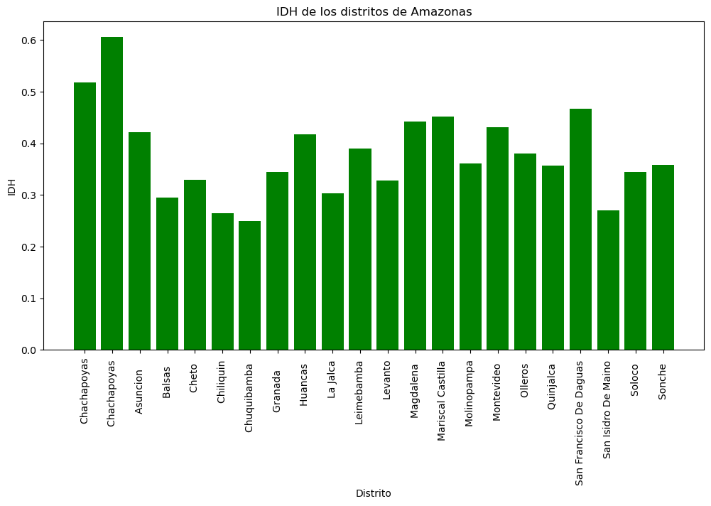

```python
fig, ax = plt.subplots(figsize=(12,6))

ax.bar(x = IDH_distrital.index, height= IDH_distrital["Índice de Desarrollo Humano (IDH)"], color="green")
ax.set_xlabel('Distrito')
ax.set_ylabel('IDH')
ax.set_title('IDH de los distritos de Amazonas')
ax.tick_params(axis="x", rotation=90)
plt.show()
```

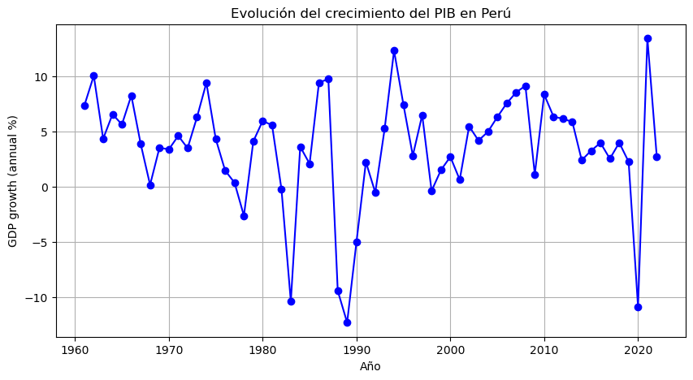

```python
# Indicadores de Desarrollo GlobaL, a nivel país:

import pandas as pd
import matplotlib.pyplot as plt

# Cargar el CSV usando delimitador punto y coma y codificación utf-8
file_path = r"C:\Users\ASUS\Documents\Python Scripts\desarrollo global.csv"
df = pd.read_csv(file_path, delimiter=";", encoding="utf-8")

# Filtrar los datos para Perú y el indicador "GDP growth (annual %)"
df_filtered = df[(df["Country Name"] == "Peru") & (df["Series Name"] == "GDP growth (annual %)")]

# Transformar los datos de formato ancho a largo (melt)
df_long = df_filtered.melt(id_vars=["Country Name", "Series Name"],
                           var_name="Year", value_name="Value")

# Extraer el año de la columna "Year" y manejar filas sin dato
df_long["Year"] = df_long["Year"].str.extract(r'(\d{4})')[0]
df_long = df_long.dropna(subset=["Year"])  # elimina filas sin un año válido
df_long["Year"] = df_long["Year"].astype(int)

# Convertir la columna "Value" a numérico y eliminar filas sin datos válidos
df_long["Value"] = pd.to_numeric(df_long["Value"], errors="coerce")
df_long = df_long.dropna(subset=["Value"])

# Graficar la evolución del crecimiento del PIB en Perú
plt.figure(figsize=(10, 5))
plt.plot(df_long["Year"], df_long["Value"], marker="o", linestyle="-", color="b")
plt.title("Evolución del crecimiento del PIB en Perú")
plt.xlabel("Año")
plt.ylabel("GDP growth (annual %)")
plt.grid(True)
plt.show()
```

[output not shown]

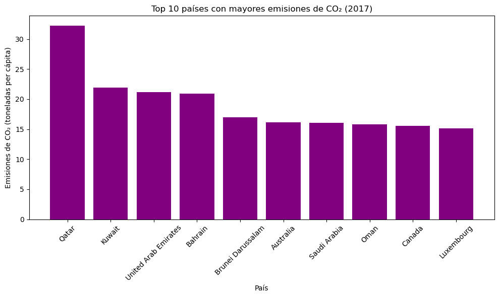

```python
import pandas as pd
import matplotlib.pyplot as plt

# Cargar el CSV usando punto y coma y la codificación adecuada
file_path = r"C:\Users\ASUS\Documents\Python Scripts\desarrollo global.csv"  # Ajusta la ruta si es necesario
df = pd.read_csv(file_path, delimiter=";", encoding="utf-8")

# Verificar las columnas disponibles (opcional)
print("Columnas:", df.columns.tolist())

# Filtrar datos para el indicador "CO2 emissions (metric tons per capita)"
df_co2 = df[df["Series Name"] == "CO2 emissions (metric tons per capita)"]

# Seleccionar solo el nombre del país y el valor para 2017
df_co2_2017 = df_co2[["Country Name", "2017 [YR2017]"]].copy()

# Convertir la columna de 2017 a numérico y eliminar filas sin datos
df_co2_2017["2017 [YR2017]"] = pd.to_numeric(df_co2_2017["2017 [YR2017]"], errors="coerce")
df_co2_2017 = df_co2_2017.dropna()

# Ordenar de mayor a menor y tomar los 10 primeros países
df_top10 = df_co2_2017.sort_values(by="2017 [YR2017]", ascending=False).head(10)

# Crear un gráfico de barras simple
plt.figure(figsize=(10, 6))
plt.bar(df_top10["Country Name"], df_top10["2017 [YR2017]"], color="purple")
plt.xlabel("País")
plt.ylabel("Emisiones de CO₂ (toneladas per cápita)")
plt.title("Top 10 países con mayores emisiones de CO₂ (2017)")
plt.xticks(rotation=45)
plt.tight_layout()
plt.show()
```